# A guide for using protlocassign for constrained proportional assignment

Dirk F Moore and Peter Lobel

Department of Biostatistics and Epidemiology, Rutgers School of Public Health, NJ, US  
Center for Advanced Biotechnology and Medicine, Rutgers University, NJ, US

2022-07-28

# Contents

**R version**: R version 4.2.0 (2022-04-22 ucrt)

**Bioconductor version**: 3.15

**Package**: 0.99.7

# 1 Tutorial 1: Getting started with the assignment of proteins to subcellular locations using protlocassign

## 1.1 Introduction

This set of tutorials provides a comprehensive guide to the `protlocassign` package for constrained proportional assignment. It is available in the package “protlocassigndoc”; details on installing that are given in the next section. Additional details may be found in a companion paper (DF Moore, D Sleat, and P Lobel, 2022).

Determining the locations of proteins in the cell is an important but complex problem. A frequently employed approach for this involves centrifugation-based methods to partially separate different organelles and other cellular compartments and then to determine the relative distribution of different proteins among the centrifugation fractions. The location of proteins of interest in the cellular compartments are then inferred by comparing their distributions across the centrifugation fractions to the distributions of a set of reference proteins (markers) with known cellular locations.

This package implements a subcellular protein assignment procedure known as “constrained proportional assignment”, or CPA (Jadot et al, 2016). The basic concepts involved in CPA and analysis of subcellular proteomics data are described in the main paper (Moore et al., 2022). These tutorials serve as a basis for implementing CPA and various utilities for both experienced and beginner R users.

There are two fundamental inputs for CPA. The first is a file with information regarding the distribution of each protein or other species of interest to be analyzed across centrifugation fractions. Each row has a name that serves as a unique identifier, which we here refer to as a protein name, but one can use other identifiers (e.g., protein group, protein isoform, gene name, accession number, etc.). For each protein (or other identifier), there are data that reflect its distribution among the centrifugal fractions, which represent a profile. The second is a file containing a list of single-compartment reference proteins (markers) and their associated subcellular locations. As an initial step, the package uses the markers to compute profiles for individual cellular compartments. Then, for each protein, it finds the best match for its profile using a linear combination of compartment profiles. The relative weights of the linear combination in principle reflect the relative abundance of a given protein among different compartments. The CPA method can thus account for proteins that have multiple residences, and estimate the relative proportion among these residences.

We illustrate with an example. Tannous et al. (2020) presented an experiment (designated here as AT5) analyzing abundance levels of proteins across a total of nine fractions: six fractions (N, M, L1, L2, P, and S) from differential centrifugation of a rat liver homogenate and three fractions (Nyc1, Nyc2, and Nyc3) from a Nycodenz density gradient centrifugation of the differential fraction L1. Eight subcellular compartments were considered: nucleus (Nuc), mitochondria (Mito), lysosomes (Lyso), peroxisomes (Perox), endoplasmic reticulum (ER), Golgi apparatus (Golgi), plasma membrane (PM), and cytosol (Cyto). The CPA method assigns each protein to one or more of these compartments, based on profiles from the set of reference proteins.

Other Bioconductor packages are available for working with proteomics data. The “HPAanalyze” package (Tran et al., 2019) provides tools for accessing the Human Protein Atlas and for visualizing the data. The “pRoloc” package (Breckels et al.) provides tools for studying localisation of proteins inside cells and for manipulating and visualizing relevant data from quantitative fractionation experiments. In this vignette and in the tutorials in the accompanying “protlocassigndoc” package we provide detailed instructions on how to format data in “.csv” files for import in this package. Data stored in “pRoloc” or “hpa” R formats may be converted into the formats required by “protlocassign” in a similar fashion.

## 1.2 Installing the protlocassign package

First install the Bioconductor utility `BiocManager`:

```
install.packages("BiocManager")
```

Next, install the `protlocassign` package either from Bioconductor or, using `devtools`, from Github:

```
BiocManager::install("protlocassign")
install.packages("devtools")
devtools::install_github("mooredf22/protlocassign")
```

This companion of supplementary tutorials may be installed as follows:

```
devtools::install_github("mooredf22/protlocassigndoc")
```

Finally, install other required packages:

```
BiocManager::install(c("BB", "pracma", "lme4", "outliers", "BiocParallel"))
```

Once you have installed these packages, you do not need to re-install them the next time you start up R. However, you will need to load them using the `library` function before use.

First load the `protlocassign` library:

```r
library(protlocassign)
```

and then other needed libraries:

```r
    library(BB)
    library(pracma)
    library(outliers)
    library(stats)
    library(graphics)
    library(viridisLite)
    library(viridis)
    library(plot.matrix)
    library(grid)
    library(gridExtra)
    library(rmarkdown)
    library(utils)
    library(methods)
    library(BiocParallel)
```

## 1.3 Working with data expressed as normalized specific amounts (NSA)

To use this package, you will need two data sets as described above. One, the protein profile data set, contains rows with a unique identifier followed by data describing the profile associated with each identifier across a series of centrifugation fractions. In this tutorial, the profiles associated with each identifier are specific amounts with sums constrained to 1 (NSA, see Moore et al., 2022) and Tutorial 3) but can be in a different form or further transformed to improve the quality of the fit (see Tutorials 2-4). The protein profile data set may contain two additional values representing the numbers of peptides and spectra that were used to compute the profile (see below).  
The other data set consists of the list of reference proteins and their associated known subcellular compartments.

Consider for example a test data set drawn from the TMT MS2 data from Tannous et al. (2020) experiment AT5. The full data set has 7894 proteins but we use a small subset of these for purposes of illustration and to reduce processing time. To get started, load the package and attach the embedded test protein profile data set; we see that it has 40 rows and 11 columns:

```r
library(protlocassign)

data(protNSA_test)
dim(protNSA_test)
```

```
#> [1] 40 11
```

For the sake of brevity, we rename it `protNSA`:

```r
protNSA <- protNSA_test
```

The first few rows of the data can be examined using the `head` command, rounding to improve legibility. The first nine columns represent the protein profile. The last two columns, which are optional, give the number of spectra and the number of peptides (sequences) for each protein. Note that while we use a nested random effects model described in Jadot et al., 2017 and Moore et al., 2022 to compute the means across spectra (also see Tutorial 6), other methods, including taking a straight average or weighted average (e.g., based on reporter ion intensities or peak areas), may be appropriate for other applications.

```r
round(head(protNSA), digits=2)
```

```
#>            N    M   L1   L2    P    S Nyc1 Nyc2 Nyc3 Nspectra Npep
#> ACP2    0.05 0.05 0.10 0.09 0.05 0.05 0.13 0.41 0.07       41    8
#> AIF1      NA   NA   NA   NA   NA   NA   NA   NA   NA        0    0
#> ATP1A1  0.12 0.06 0.09 0.14 0.12 0.03 0.20 0.18 0.06      235   41
#> B4GALT1 0.05 0.03 0.05 0.11 0.22 0.00 0.23 0.29 0.01        2    2
#> CANX    0.10 0.06 0.09 0.22 0.28 0.02 0.08 0.08 0.06       78   14
#> CAT     0.05 0.08 0.30 0.14 0.04 0.07 0.05 0.06 0.22      660   29
```

We can also use the “str” command as an alternate way to examine the structure of the protNSA data set. The first line returned indicates that protNSA is represented in R as a data frame with 40 rows and 11 variables. The remaining lines show each variable labeled according to its name (column name) followed by its type (here “num”) and the first few values, omitting row names that are present within the data frame.

```r
str(protNSA)
```

```
#> 'data.frame':    40 obs. of  11 variables:
#>  $ N       : num  0.0483 NA 0.1171 0.0542 0.1026 ...
#>  $ M       : num  0.052 NA 0.064 0.0326 0.0617 ...
#>  $ L1      : num  0.1041 NA 0.0914 0.0483 0.0871 ...
#>  $ L2      : num  0.0888 NA 0.1393 0.1137 0.223 ...
#>  $ P       : num  0.0469 NA 0.1193 0.2159 0.2816 ...
#>  $ S       : num  4.91e-02 NA 2.78e-02 6.94e-18 1.98e-02 ...
#>  $ Nyc1    : num  0.132 NA 0.1979 0.2298 0.0777 ...
#>  $ Nyc2    : num  0.412 NA 0.184 0.291 0.084 ...
#>  $ Nyc3    : num  0.0669 NA 0.0596 0.0142 0.0625 ...
#>  $ Nspectra: int  41 0 235 2 78 660 17 1704 98 56 ...
#>  $ Npep    : int  8 0 41 2 14 29 6 63 11 23 ...
```

The list containing reference proteins is derived from Jadot et al (2016) and examining the dimensions of the data reveals that it contains 37 rows and two columns, the first for the protein names and the second for their respective subcellular compartments.

```r
data(markerListJadot)
dim(markerListJadot)
```

```
#> [1] 37  2
```

The data set can be viewed by entering its name as follows:

```r
markerListJadot
```

```
#>    protName referenceCompartment
#> 1      DPP3                 Cyto
#> 2       GPT                 Cyto
#> 3      PCK1                 Cyto
#> 4      PGM1                 Cyto
#> 5      CANX                   ER
#> 6     GANAB                   ER
#> 7       POR                   ER
#> 8      RPN2                   ER
#> 9     UGGT1                   ER
#> 10  UGT2B37                   ER
#> 11  B4GALT1                Golgi
#> 12   MAN1A2                Golgi
#> 13   MAN2A1                Golgi
#> 14    MGAT1                Golgi
```

[output cut: 23 more lines]

While the `protNSA_test` and `markerListJadot` data sets are included in the package, they were initially read into R from external files and automatically converted to data frames. This will need to be done for any new data set. As an example, we demonstrate this for a case where one is working with the Windows operating system and the data sets reside in the directory `C:\temp\myproteindata`. (If one is working with either the Linux or Mac OS, appropriate changes to these procedures will be needed to access files.) First, set the working directory to point there, either by navigating to it in R studio (session menu pane) or by entering:

```
setwd("C:\\temp\\myproteindata")
```

Note that in R each backslash character must be doubled to be interpreted correctly (since otherwise it will be incorrectly interpreted as an escape character). Alternatively, you may use a single forward slash:

```
setwd("C:/temp/myproteindata")
```

Here, for for illustration, we shall instead create a temporary directory as follows:

```r
currentDir <- tempdir()
setwd(currentDir)
currentDir
```

```
#> [1] "C:\\Users\\mooredf\\AppData\\Local\\Temp\\RtmpoLQi9c"
```

To illustrate how to read in the protein profiles and list of marker proteins, we write out our protein profiles and marker list as comma-delimited files. For the protein profiles, we write out the protein names (which are row names in R) by specifying `row.names=TRUE`. Note that we first alter the protein names so that they are preceded by a single quote since, if one subsequently opens the file with excel, it could automatically reformat some names to dates (e.g., March1 to 1-Mar). To write protein profiles and marker proteins to `.csv` files, input:

```r
setwd(currentDir)
protNSAout <- protNSA
rownames(protNSAout) <- paste("'", rownames(protNSA), sep="")
markerListJadotOut <- markerListJadot
markerListJadotOut$protName <- paste("'", markerListJadot$protName, sep="")
write.csv(protNSAout, file="protNSAout.csv", row.names=T)
write.csv(markerListJadotOut, file="markerListJadotOut.csv", row.names=FALSE)
```

We may examine these files by importing them into Excel. For the marker protein data file, the first row must contain the two column names (protein unique identifier and compartment designation). Note that the marker proteins must be specified precisely as listed in the protein profile data set.

We then read in the two data sets (protein profile data and reference protein list), which must be in `.csv` format, with the first row containing column names. The option `row.names=1` takes the first column of the `protNSAout.csv` file and uses it as row names for the R file `MyProtNSAin`.

```r
setwd(currentDir)
MyProtNSAin <- read.csv(file="protNSAout.csv", row.names=1)
MyMarkerListIn <- read.csv(file="markerListJadotOut.csv")
```

We then remove the preceding single quotes from the protein names.

```r
rownames(MyProtNSAin) <- sub("^'", "", rownames(MyProtNSAin))
MyMarkerListIn[,1] <- sub("^'", "", MyMarkerListIn[,1])
```

We man examine the files as follows:

```r
round(head(MyProtNSAin), digits=3)
```

```
#>             N     M    L1    L2     P     S  Nyc1  Nyc2  Nyc3 Nspectra Npep
#> ACP2    0.048 0.052 0.104 0.089 0.047 0.049 0.132 0.412 0.067       41    8
#> AIF1       NA    NA    NA    NA    NA    NA    NA    NA    NA        0    0
#> ATP1A1  0.117 0.064 0.091 0.139 0.119 0.028 0.198 0.184 0.060      235   41
#> B4GALT1 0.054 0.033 0.048 0.114 0.216 0.000 0.230 0.291 0.014        2    2
#> CANX    0.103 0.062 0.087 0.223 0.282 0.020 0.078 0.084 0.063       78   14
#> CAT     0.052 0.076 0.295 0.137 0.035 0.065 0.052 0.065 0.222      660   29
```

```r
head(MyMarkerListIn)
```

```
#>   protName referenceCompartment
#> 1     DPP3                 Cyto
#> 2      GPT                 Cyto
#> 3     PCK1                 Cyto
#> 4     PGM1                 Cyto
#> 5     CANX                   ER
#> 6    GANAB                   ER
```

These new R data frames are identical to `protNSA_test` and `markerListJadot`. If the user reads in their own data, be sure that the first row in each of the `.csv` files contains column names. In particular, the names in the first row of the markers file must be “protName” and “referenceCompartment” to ensure that the resulting R data frame is in the proper format.

If one desires to work with the full set of 7894 proteins in the Tannous et al. data set, it may be downloaded from the MassIVE repository. To do so, execute the following code:

```
urlProtProfiles <-  "https://massive.ucsd.edu/ProteoSAFe/DownloadResultFile?file=f.MSV000083842/updates/2022-03-14_ablatannous_c39637a3/quant/protNSA_AT5tmtMS2.csv&forceDownload=true"

protNSA_AT5tmtMS2 <- read.csv(urlProtProfiles)
dim(protNSA_AT5tmtMS2)
head(protNSA_AT5tmtMS2)
```

To run the examples in this vignette using the full data set `protNSA_AT5tmtMS2` in place of the test data set, one may rename the full data set as follows:

```
protNSA <- protNSA_AT5tmtMS2
```

## 1.4 Creating and viewing compartment and marker protein profiles

In order to assign proteins proportionately to their respective compartments, we first use the function `locationProfileSetup` to obtain profiles for the compartments based on the means of the individual reference proteins that represent each compartment. This function produces a matrix that has one row for each compartment and one column for each fraction that comprises the profile.

```r
refLocationProfilesNSA <- locationProfileSetup(profile=protNSA,
                                  markerList=markerListJadot, numDataCols=9)
```

We display the data, using rounding to improve readability.

```r
round(refLocationProfilesNSA, digits=4)
```

```
#>            N      M     L1     L2      P      S   Nyc1   Nyc2   Nyc3
#> Cyto  0.0745 0.0624 0.0715 0.0706 0.0497 0.3947 0.1232 0.1021 0.0512
#> ER    0.0936 0.0680 0.0976 0.2148 0.2461 0.0346 0.0830 0.0865 0.0758
#> Golgi 0.0875 0.0584 0.0590 0.0926 0.3039 0.0306 0.1699 0.1632 0.0348
#> Lyso  0.0421 0.0503 0.1039 0.0744 0.0419 0.0455 0.1431 0.4342 0.0646
#> Mito  0.1296 0.2883 0.1554 0.0734 0.0431 0.0462 0.0768 0.0675 0.1197
#> Nuc   0.7385 0.0305 0.0153 0.0345 0.0373 0.0411 0.0372 0.0381 0.0275
#> Perox 0.0526 0.0695 0.2818 0.1383 0.0385 0.0524 0.0665 0.0835 0.2171
#> PM    0.1167 0.0639 0.0816 0.1185 0.1123 0.0359 0.2401 0.1798 0.0512
```

To examine the available compartments, view the row names of `refLocationProfilesNSA`.

```r
rownames(refLocationProfilesNSA)
```

```
#> [1] "Cyto"  "ER"    "Golgi" "Lyso"  "Mito"  "Nuc"   "Perox" "PM"
```

To graphically display a particular compartment profile and its component proteins, use `markerProfilePlot`. For example, to plot the profile for plasma membrane, input:

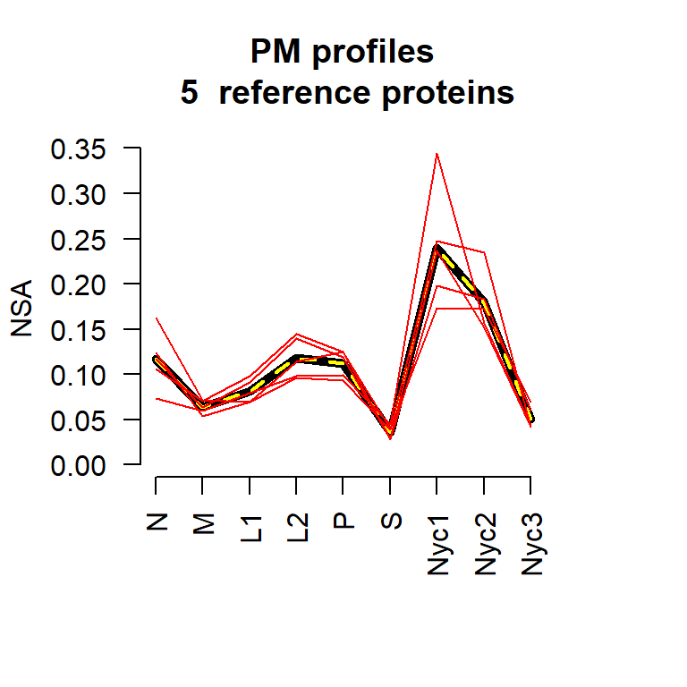

```r
markerProfilePlot(refLoc="PM", profile=protNSA, markerList=markerListJadot,
                     refLocationProfiles=refLocationProfilesNSA, ylab="NSA")
```

This displays the PM compartmental profile (dashed yellow-black line) and its five component reference proteins (red lines). To plot, for example, the second PM marker protein, use the option `refProtPlot=2` in the `markerProfilePlot` function:

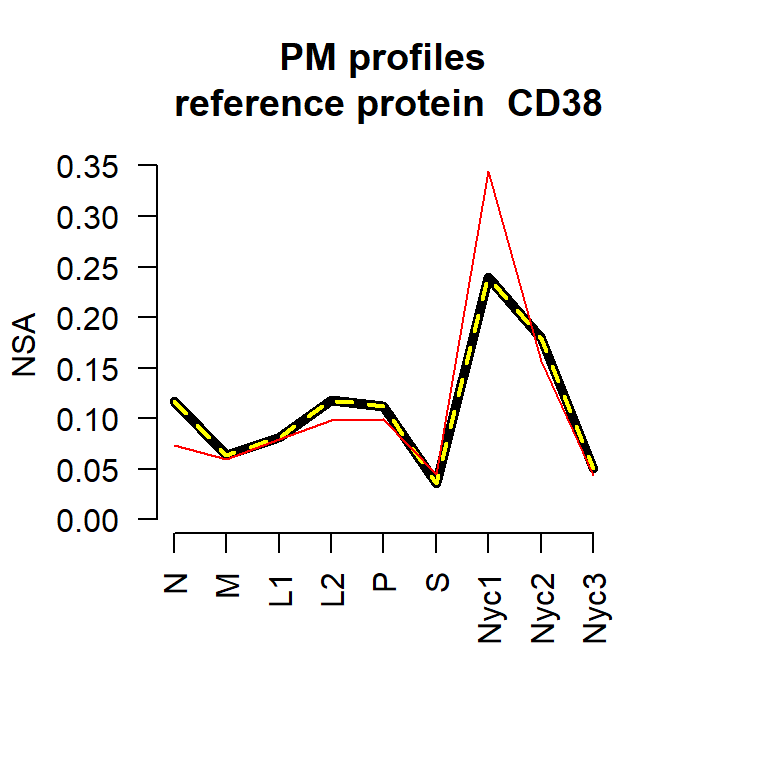

```r
markerProfilePlot(refLoc="PM", profile=protNSA,
                  markerList=markerListJadot,
                  refLocationProfiles=refLocationProfilesNSA, ylab="NSA",
                  refProtPlot=2)
```

To show individually each of the five reference proteins that are used to calculate the PM compartmental profile, use `par(mfrow=c(3,2))` to set up a plot array with 3 rows and 2 columns which will accommodate up to six plots on a single page. Then plot all five of the them one-by-one by looping through the five PM marker proteins by first specifying `for (j in 1:5)` and invoking the option `refProtPlot=j` in the `markerProfilePlot` function. (To make them legible, you may first need to open a new window by entering `windows(width=5, height=7)`.) The parameters in `par(mfrow=c(3,2))` and `for (j in 1:5)` can be adjusted to display any number of plots.

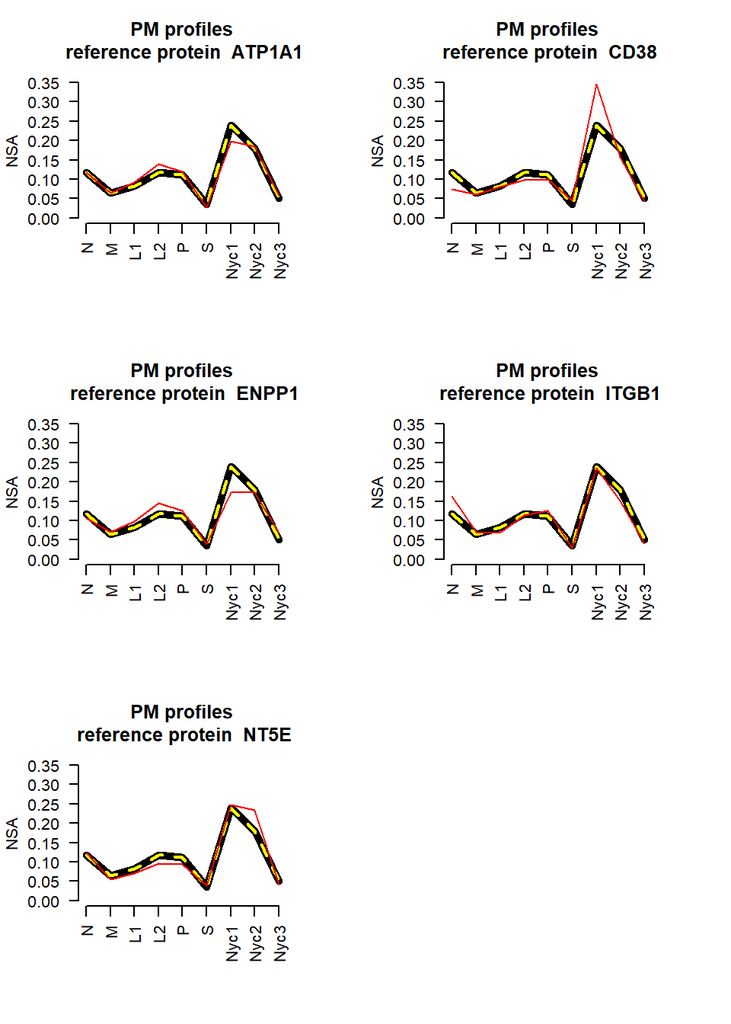

```r
par(mfrow=c(3,2)) # this will be new default layout for subsequent plots.
# Will need to reset par(mfrow=c(1,1)) for single graph layouts

for (j in 1:5) {
  markerProfilePlot(refLoc="PM", profile=protNSA,
                    markerList=markerListJadot,
                    refLocationProfiles=refLocationProfilesNSA,
                    ylab="NSA", refProtPlot=j)
  }
```

To plot all of the compartment and individual marker protein profiles, we may set up a plot window with four rows and two columns and then loop through the eight subcellular compartments:

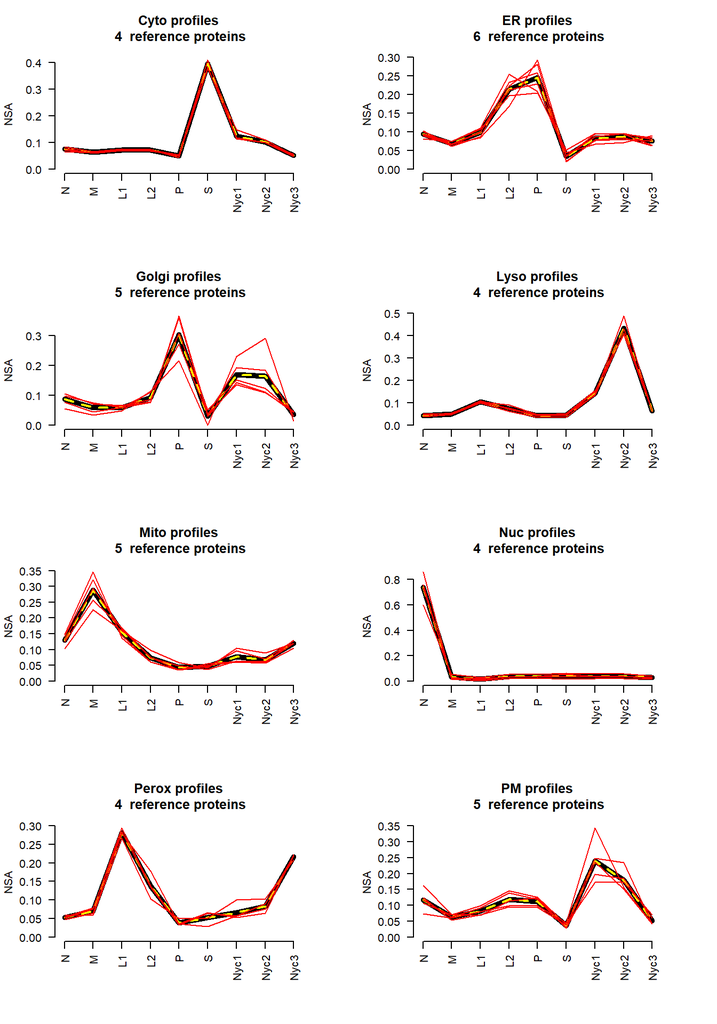

```r
loc.list <- rownames(refLocationProfilesNSA)
n.loc <- length(loc.list)
par(mfrow=c(4,2))
for (i in 1:n.loc) {
  markerProfilePlot(refLoc=loc.list[i], profile=protNSA,
                     markerList=markerListJadot,
                     refLocationProfiles=refLocationProfilesNSA, ylab="NSA")
  }
```

## 1.5 Obtaining CPA of proteins to compartments

Once we are satisfied with the marker set and compartment profiles, we can run the CPA routine which, for each protein in our data set, apportions its residency among the different specified compartments. Note that the command below uses default options.  
It is also possible to specify optional parameters including writing out the obtained goodness of fit minimum (`minVal=T`, default is `minVal=FALSE`), setting initial parameters for each CPA value using an eight element vector specifying the starting proportions (`startProp`, if not specified the function will assign a value of 1/8 for each of the eight compartments), and by constraining the output CPA values for specified compartments to be zero (see help file, `?fitCPA`).

```r
protCPAfromNSA <- fitCPA(profile=protNSA,
                          refLocationProfiles=refLocationProfilesNSA,
                          numDataCols=9)
```

```
#> cpa does not converge for a protein
#>  returning missing values for cpa estimates for that protein
```

We can view the structure of the output data file and see that the rows contain the protein names, and the next eight columns contain the allocation proportions of each protein to the eight compartments. The last two columns are integers representing the numbers of peptides and spectra assigned to each respective protein; these are carried over from the input `protProfileSummary` profile data and are not essential for the CPA analysis.

```r
round(head(protCPAfromNSA), digits=2)
```

```
#>         Cyto   ER Golgi Lyso Mito  Nuc Perox   PM Nspectra Npeptides
#> ACP2    0.01 0.04  0.00 0.93    0 0.00  0.02 0.00       41         8
#> AIF1      NA   NA    NA   NA   NA   NA    NA   NA        0         0
#> ATP1A1  0.00 0.16  0.00 0.09    0 0.02  0.03 0.70      235        41
#> B4GALT1 0.00 0.00  0.57 0.35    0 0.00  0.00 0.08        2         2
#> CANX    0.00 0.96  0.04 0.00    0 0.00  0.00 0.00       78        14
#> CAT     0.00 0.00  0.00 0.00    0 0.00  1.00 0.00      660        29
```

Note that the protein “AIF1” has all missing values, which is why an error is reported for that one protein. While AIF1 is the only one of the 7894 proteins in the full AT5tmtMS2 data set that has no profile, we include it in our 40 protein test data set to show that such cases can occur.

We can look at the profile of, for example, the protein “TLN1”. We first ensure that the protein is in the dataset:

```r
protIndex("TLN1", profile=protNSA)
```

```
#>   Prot index number Prot name
#> 1                36      TLN1
```

This function also accepts partial matching of the first few letters of a protein. For example, we can find the indices of the proteins starting with “TLN”:

```r
protIndex("TLN", profile=protNSA)
```

```
#>   Prot index number Prot name
#> 1                36      TLN1
#> 2                37      TLN2
```

Now we plot the results for protein TLN1:

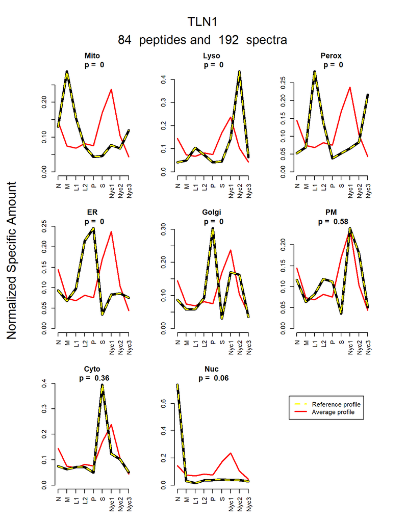

```r
protPlotfun(protName="TLN1", profile=protNSA,
numDataCols=9, n.compartments=8,
  refLocationProfiles=refLocationProfilesNSA,
  assignPropsMat=protCPAfromNSA,
  yAxisLabel="Normalized Specific Amount")
```

The `protPlotfun` function is designed to plot profiles of eight subcellular locations. If a data set has more than eight of these, it will be necessary to modify the code to accommodate the larger number.

## 1.6 Saving the CPA output

### 1.6.1 Data output

To save the results of the CPA procedure, as before, we prepend the protein names with a single quote and write out a `.csv` file to a specified directory.

```
protCPAfromNSAout <- protCPAfromNSA
rownames(protCPAfromNSAout) <- paste("'", rownames(protCPAfromNSAout), sep="")

setwd("C:/temp/myProteinOutput")

write.csv(protCPAfromNSAout,
           file="protCPAfromNSAout_AT5tmtMS2.csv", row.names=T)
```

### 1.6.2 Plot output as pdf files

To save the plot of a protein (`TLN1` for example) as a pdf file, we first specify a pdf plot `window`, call the `protPlotfun` function as before, and then close the plot window using `dev.off()` to allow R to complete producing the file:

```
pdf(file="myPlotPDFfile.pdf", width=7, height=10)
protPlotfun(protName="TLN1", profile=protNSA,
    numDataCols=9, n.compartments=8,
    refLocationProfiles=refLocationProfilesNSA,
    assignPropsMat=protCPAfromNSA,
    yAxisLabel="Normalized Specific Amount")
dev.off()
```

To output plots all of the protein profiles into a single pdf file, one can set up a loop as follows:

```
pdf(file="allPlotsPDFfile.pdf", width=7, height=10)
n.prots <- nrow(protCPAfromNSA)
for (i in 1:n.prots) {
   protPlotfun(protName=rownames(protCPAfromNSA)[i],
       profile=protNSA, numDataCols=9, n.compartments=8,
       refLocationProfiles=refLocationProfilesNSA,
       assignPropsMat=protCPAfromNSA,
       yAxisLabel="Normalized Specific Amount")
}
dev.off()
```

This will result in a single file, `allPlotsPDFfile.pdf`, with a page for each protein plotted. Note that one protein in our data set, `AIF1`, does not have a profile as all peptides were outliers (see Tutorial 6).

# 2 Tutorial 2: Relative specific amount (RSA) transformation and CPA

## 2.1 Introduction

In Tutorial 1 (“Getting Started”), we illustrated the principles of CPA using protein profiles that represent mass spectrometry data from a set of subcellular fractions in the form of normalized specific amounts (NSA). NSA profiles have equivalent amounts of total protein analyzed per fraction, with the sum of all fractions constrained to 1.  
This tutorial describes how to use functions in the `protlocassign` package to transform NSA profiles in ways that may provide more accurate assignments of proportional residence to subcellular compartments.

## 2.2 Setting up the data and reference protein files and transforming to RSA

As explained in the Tutorial 1, we will demonstrate using two R data sets that are included in the `protlocassign` package. One, `protNSA_test`, consists of row names that indicate protein identifiers, each of which is followed by data describing the identifier profile across the nine normalized specific amounts derived from a subcellular fractionation experiment. The other data set, `markerListJadot`, consists of a list of reference proteins and their associated known subcellular compartments. As before, to run the program, the `protlocassign` library must be installed.

```r
library(protlocassign)
```

In Tutorial 1, we use `protNSA_test` and an untransformed average of reference protein profiles in the form of NSA for each compartment to conduct CPA. However, it may be advantageous to transform the data prior to conducting CPA to yield a more accurate prediction of cellular location. For this purpose, we express profile data as RSAs.  
As explained in the main text and elaborated in Tutorial 3, RSA is the ratio of two ratios: the numerator is the amount of a given protein in a particular fraction divided by the amount of that given protein in the starting material while the denominator is amount of total protein in a particular fraction divided by the amount of total protein in the starting material. The RSA describes the fold-enrichment (RSA>1) or depletion (RSA<1) of a protein during the fractionation process, and is analogous to the relative specific activity term used in classical analytical subcellular fractionation. Be aware that to perform this transformation, one needs to have estimates of all these quantities, and this was incorporated into our experimental design.  
In our example, the first six fractions (the differential fractions) can be used to estimate amounts in the starting material.  
We also measured total protein in each fraction, and these are contained in the 9-element vector `totProtAT5` which is preloaded in `protlocassign`. Note that the order and numbers of the measurements for total protein (e.g., N, M, L1, L2, P, S, Nyc1, Nyc2 and Nyc3 in `totProtAT5`) must correspond to those in the data set containing individual protein profiles (e.g., `protNSA_test`). For clarity of presentation, we rename `totProtAT5` and `protNSA_test` to `totProt` and `protNSA`, respectively.

```r
data(protNSA_test)
protNSA <- protNSA_test
head(round(protNSA, digits=3))
```

```
#>             N     M    L1    L2     P     S  Nyc1  Nyc2  Nyc3 Nspectra Npep
#> ACP2    0.048 0.052 0.104 0.089 0.047 0.049 0.132 0.412 0.067       41    8
#> AIF1       NA    NA    NA    NA    NA    NA    NA    NA    NA        0    0
#> ATP1A1  0.117 0.064 0.091 0.139 0.119 0.028 0.198 0.184 0.060      235   41
#> B4GALT1 0.054 0.033 0.048 0.114 0.216 0.000 0.230 0.291 0.014        2    2
#> CANX    0.103 0.062 0.087 0.223 0.282 0.020 0.078 0.084 0.063       78   14
#> CAT     0.052 0.076 0.295 0.137 0.035 0.065 0.052 0.065 0.222      660   29
```

```r
data(totProtAT5)
totProt <- totProtAT5
round(totProt, digits=4)
```

```
#>       N       M      L1      L2       P       S   Nyc.1   Nyc.2   Nyc.3
#> 46.0448 48.9560  1.3841  1.5663 24.0456 58.1818  0.0369  0.0685  1.2730
```

The function `RSAfromNSA` calculates transformed profiles from individual and total protein measurements. This requires specifying which values are used to estimate the amount in the starting material (typically the homogenate) and the values used to construct the profile. In our case, the first six fractions of the nine-fraction profile are summed to estimate the starting material. Our code requires that the fractions representing the starting material are contiguous and are located at the beginning of the profile. Note that the function `RSAfromNSA` can use protein profiles expressed either as NSA or as specific amounts (see Tutorial 3). Thus we select the first nine columns of `protNSA`:

```r
protRSA  <- RSAfromNSA(NSA=protNSA[,1:9],
                         NstartMaterialFractions=6, totProt=totProt)
dim(protRSA)
```

```
#> [1] 40  9
```

```r
round(head(protRSA), digits=3)
```

```
#>             N     M    L1    L2     P     S  Nyc1  Nyc2  Nyc3
#> ACP2    0.963 1.036 2.075 1.769 0.935 0.980 2.632 8.207 1.334
#> AIF1       NA    NA    NA    NA    NA    NA    NA    NA    NA
#> ATP1A1  1.580 0.864 1.233 1.879 1.609 0.375 2.670 2.477 0.804
#> B4GALT1 1.024 0.616 0.913 2.150 4.084 0.000 4.346 5.512 0.268
#> CANX    1.146 0.688 0.972 2.489 3.143 0.221 0.867 0.938 0.698
#> CAT     0.823 1.205 4.676 2.172 0.557 1.032 0.826 1.029 3.524
```

```r
str(protRSA)
```

```
#> 'data.frame':    40 obs. of  9 variables:
#>  $ N   : num  0.963 NA 1.58 1.024 1.146 ...
#>  $ M   : num  1.036 NA 0.864 0.616 0.688 ...
#>  $ L1  : num  2.075 NA 1.233 0.913 0.972 ...
#>  $ L2  : num  1.77 NA 1.88 2.15 2.49 ...
#>  $ P   : num  0.935 NA 1.609 4.084 3.143 ...
#>  $ S   : num  9.80e-01 NA 3.75e-01 1.31e-16 2.21e-01 ...
#>  $ Nyc1: num  2.632 NA 2.67 4.346 0.867 ...
#>  $ Nyc2: num  8.207 NA 2.477 5.512 0.938 ...
#>  $ Nyc3: num  1.334 NA 0.804 0.268 0.698 ...
```

Since there is additional information in the last two columns of `protNSA` that we want to include in the new file, specifically the numbers of spectra and peptides (`Nspectra` and `Nseq`), we add them to the output as follows:

```r
protRSA <- data.frame(protRSA, protNSA[,10:11])
#note data frame is being overwritten
dim(protRSA)
```

```
#> [1] 40 11
```

```r
str(protRSA)
```

```
#> 'data.frame':    40 obs. of  11 variables:
#>  $ N       : num  0.963 NA 1.58 1.024 1.146 ...
#>  $ M       : num  1.036 NA 0.864 0.616 0.688 ...
#>  $ L1      : num  2.075 NA 1.233 0.913 0.972 ...
#>  $ L2      : num  1.77 NA 1.88 2.15 2.49 ...
#>  $ P       : num  0.935 NA 1.609 4.084 3.143 ...
#>  $ S       : num  9.80e-01 NA 3.75e-01 1.31e-16 2.21e-01 ...
#>  $ Nyc1    : num  2.632 NA 2.67 4.346 0.867 ...
#>  $ Nyc2    : num  8.207 NA 2.477 5.512 0.938 ...
#>  $ Nyc3    : num  1.334 NA 0.804 0.268 0.698 ...
#>  $ Nspectra: int  41 0 235 2 78 660 17 1704 98 56 ...
#>  $ Npep    : int  8 0 41 2 14 29 6 63 11 23 ...
```

We also need to transform the profiles of the markers for each compartment. As in Tutorial 1, we use the function `locationProfilesetup` to average the profiles (which must be normalized specific amounts) to obtain profiles for the reference proteins:

```r
data(markerListJadot)
refLocationProfilesNSA <- locationProfileSetup(profile=protNSA,
                          markerList=markerListJadot, numDataCols=9)
round(refLocationProfilesNSA, digits=4)
```

```
#>            N      M     L1     L2      P      S   Nyc1   Nyc2   Nyc3
#> Cyto  0.0745 0.0624 0.0715 0.0706 0.0497 0.3947 0.1232 0.1021 0.0512
#> ER    0.0936 0.0680 0.0976 0.2148 0.2461 0.0346 0.0830 0.0865 0.0758
#> Golgi 0.0875 0.0584 0.0590 0.0926 0.3039 0.0306 0.1699 0.1632 0.0348
#> Lyso  0.0421 0.0503 0.1039 0.0744 0.0419 0.0455 0.1431 0.4342 0.0646
#> Mito  0.1296 0.2883 0.1554 0.0734 0.0431 0.0462 0.0768 0.0675 0.1197
#> Nuc   0.7385 0.0305 0.0153 0.0345 0.0373 0.0411 0.0372 0.0381 0.0275
#> Perox 0.0526 0.0695 0.2818 0.1383 0.0385 0.0524 0.0665 0.0835 0.2171
#> PM    0.1167 0.0639 0.0816 0.1185 0.1123 0.0359 0.2401 0.1798 0.0512
```

We then use `RSAfromNSA` to transform these reference profiles.

```r
refLocationProfilesRSA <- RSAfromNSA(NSA=refLocationProfilesNSA,
       NstartMaterialFractions=6,
       totProt=totProt)
round(refLocationProfilesRSA, digits=4)
```

```
#>            N      M     L1     L2      P      S   Nyc1   Nyc2   Nyc3
#> Cyto  0.4349 0.3644 0.4177 0.4125 0.2903 2.3050 0.7196 0.5962 0.2988
#> ER    1.0517 0.7640 1.0965 2.4131 2.7643 0.3882 0.9328 0.9716 0.8520
#> Golgi 0.9731 0.6497 0.6556 1.0296 3.3791 0.3402 1.8892 1.8151 0.3872
#> Lyso  0.9131 1.0893 2.2509 1.6117 0.9088 0.9851 3.1022 9.4104 1.4010
#> Mito  0.9675 2.1523 1.1601 0.5481 0.3215 0.3449 0.5733 0.5035 0.8935
#> Nuc   3.4240 0.1413 0.0709 0.1599 0.1730 0.1907 0.1722 0.1766 0.1277
#> Perox 0.9104 1.2035 4.8811 2.3948 0.6666 0.9077 1.1511 1.4461 3.7610
#> PM    1.5471 0.8475 1.0817 1.5702 1.4888 0.4760 3.1822 2.3828 0.6785
```

We computed the RSA reference profiles above from the NSA reference profiles. Note that, as an alternative, one could compute the RSA reference profiles directly from `protRSA`. These two approaches yield similar but non-identical results, and we typically use the first procedure to generate RSA-transformed reference location profiles.

```r
refLocationProfilesRSA_2 <- locationProfileSetup(profile=protRSA,
                          markerList=markerListJadot, numDataCols=9)
round(refLocationProfilesRSA_2, digits=4)
```

```
#>            N      M     L1     L2      P      S   Nyc1   Nyc2   Nyc3
#> Cyto  0.4346 0.3648 0.4180 0.4129 0.2905 2.3048 0.7227 0.5975 0.2992
#> ER    1.0512 0.7655 1.1010 2.4283 2.7611 0.3882 0.9311 0.9710 0.8560
#> Golgi 0.9770 0.6416 0.6848 1.1577 3.4487 0.3111 2.1591 2.2065 0.3745
#> Lyso  0.9140 1.0941 2.2741 1.6092 0.9075 0.9804 3.1317 9.5912 1.4107
#> Mito  0.9673 2.1439 1.1849 0.5678 0.3323 0.3465 0.5972 0.5203 0.9103
#> Nuc   3.4103 0.1459 0.0737 0.1638 0.1767 0.1960 0.1773 0.1809 0.1307
#> Perox 0.9181 1.2091 4.9424 2.4675 0.6784 0.8885 1.1698 1.4840 3.8148
#> PM    1.5278 0.8504 1.0951 1.5760 1.4913 0.4873 3.2699 2.4148 0.6839
```

```r
# we use the `as.matrix` function for display purposes in the tutorial
as.matrix(all.equal(refLocationProfilesRSA, refLocationProfilesRSA_2,
                    precision=0, countEQ=TRUE))
```

```
#>       [,1]
#>  [1,] "Component \"N\": Mean relative difference: 0.004562766"
#>  [2,] "Component \"M\": Mean relative difference: 0.005040309"
#>  [3,] "Component \"L1\": Mean relative difference: 0.0137593"
#>  [4,] "Component \"L2\": Mean relative difference: 0.02448992"
#>  [5,] "Component \"P\": Mean relative difference: 0.01031725"
#>  [6,] "Component \"S\": Mean relative difference: 0.01204668"
#>  [7,] "Component \"Nyc1\": Mean relative difference: 0.03751768"
#>  [8,] "Component \"Nyc2\": Mean relative difference: 0.03845132"
#>  [9,] "Component \"Nyc3\": Mean relative difference: 0.01260814"
```

## 2.3 Plotting RSA-transformed profiles, and finding RSA-based CPA

As in Tutorial 1, we can plot reference profiles, but this time using the RSA-transformed data. For example, here is a plot for all markers:

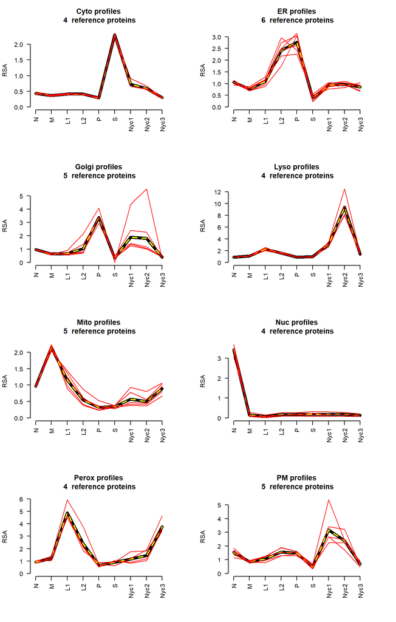

```r
loc.list <- rownames(refLocationProfilesRSA)
n.loc <- length(loc.list)
par(mfrow=c(4,2))
for (i in 1:n.loc) {
  markerProfilePlot(refLoc=loc.list[i], profile=protRSA,
                     markerList=markerListJadot,
                     refLocationProfiles=refLocationProfilesRSA, ylab="RSA")
  }
```

Now we can run the CPA routine on the RSA-transformed levels. The result is a matrix with protein identifiers as row names and data indicating the estimated proportional assignments of each protein among the eight subcellular locations.

```r
protCPAfromRSA <- fitCPA(profile=protRSA,
                        refLocationProfiles=refLocationProfilesRSA,
                        numDataCols=9)
```

```
#> cpa does not converge for a protein
#>  returning missing values for cpa estimates for that protein
```

Note that an error is reported; this is from the attempted fit of the protein “AIF1” which doesn’t have a profile (see Tutorial 1). We examine the output data set as follows:

```r
round(head(protCPAfromRSA), digits=3)
```

```
#>          Cyto    ER Golgi  Lyso  Mito   Nuc Perox    PM Nspectra Npeptides
#> ACP2    0.028 0.078  0.00 0.855 0.000 0.021 0.018 0.000       41         8
#> AIF1       NA    NA    NA    NA    NA    NA    NA    NA        0         0
#> ATP1A1  0.000 0.179  0.00 0.057 0.000 0.021 0.025 0.718      235        41
#> B4GALT1 0.000 0.000  0.57 0.430 0.000 0.000 0.000 0.000        2         2
#> CANX    0.000 0.960  0.04 0.000 0.000 0.000 0.000 0.000       78        14
#> CAT     0.047 0.000  0.00 0.000 0.036 0.000 0.917 0.000      660        29
```

The `protPlotfun` function is designed to plot profiles of eight subcellular locations. If a data set has more than eight of these, it will be necessary to modify the code to accommodate the larger number.

Now we plot the results for protein TLN1:

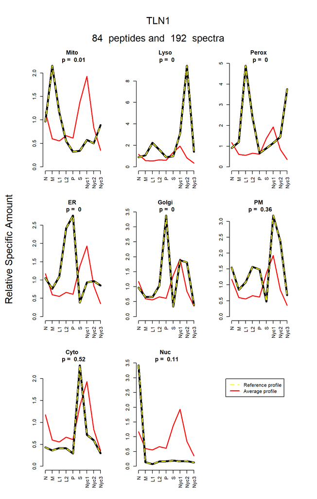

```r
protPlotfun(protName="TLN1", profile=protRSA, numDataCols=9,
                        refLocationProfiles=refLocationProfilesRSA,
                        assignPropsMat=protCPAfromRSA,
                        yAxisLabel="Relative Specific Amount")
```

# 3 Tutorial 3: Data transformations: Notation and mixtures using protlocassign

## 3.1 Introduction

As explained in the main text and in Tutorial 2, there are different ways to transform protein profile data. Here, we describe a way to explore the effect of using transformed data with CPA. Briefly, we conduct different data transformations on a set of theoretical proteins that have a range of distributions between two cellular compartments, and then conduct CPA and determine how well it predicts the original distribution. To create the theoretical proteins for our simulations, we use data from the experiment from Tannous et al. which consists of a TMT-MS2 analysis of six differential fractions (N, M, L1, L2, P, and S) obtained from centrifugation of a rat liver homogenate and three fractions from a Nycodenz density gradient separation of the differential fraction L1 (Nyc1, Nyc2, and Nyc3).

In our procedure, we first use the eight compartment profiles generated from the marker protein set to simulate a set of eight theoretical proteins that wholly reside in each of the respective compartments.  
We then then create binary mixtures with defined combinations of the eight theoretical proteins to simulate proteins that are distributed in varying proportions between two compartments. Note that data from mass spectrometry experiments generally represent specific amounts ${s_{\alpha ,l}}$ of a protein $\alpha$ in fraction $l$, with the same amount of total protein being analyzed for each sample (fraction). For conducting our simulations, we first must transform this data into relative amounts, so that each protein has precisely the same total amount in the initial starting material used for fractionation.

## 3.2 Computation of Relative Amounts (Acup)

Consider an $n$ by 9 matrix of specific amounts that details the average distribution of $n$ proteins among 9 fractions:
$$\mathbf{S}=\left[ \begin{matrix}
{{s}_{11}} & {{s}_{12}} & \cdots & {{s}_{19}} \\
{{s}_{21}} & {{s}_{22}} & \cdots & {{s}_{29}} \\
\vdots & \vdots & {} & \vdots \\
{{s}_{n1}} & {{s}_{n2}} & \cdots & {{s}_{n9}} \\
\end{matrix} \right]$$

Each row $\alpha$ represents a mean profile for a protein $\alpha$, with each profile consisting of $f=9$ fractions.

In Tutorial 1 we used a normalized specific amount (NSA), denoted here as $\tilde{s}_{\alpha,l}$ calculated as follows:

$${{\tilde{s}}_{\alpha ,l}}=\frac{{{s}_{\alpha ,l}}}{\sum\limits_{j=1}^{f}{{{s}_{\alpha ,j}}}}$$
In some experiments, these are the only values available for using the CPA procedure. However, with appropriate experimental design and execution, using balance sheet analysis (“bookkeeping”), one can estimate the amounts of total protein present in different samples obtained from a set amount of starting material. These include the total protein content of the starting material (designated $t_h$) and the total protein content of any given fraction (designated $t_l$ for fraction $l$). We can use these to calculate the amount of protein in arbitrary units in fraction $l$ derived from a set amount of starting material as $a_l = s_l t_l$. Note that as $a_l$ is in arbitrary units, one can do the same calculation using either $s_l$ or ${\tilde s_l}$, as these will yield the same values when calculating relative amounts (Acup) (see below).

To see how this works in `protlocassign`, let us consider the Jadot et al. reference protein profiles, which we generate using the `locationProfileSetup` function. As in earlier tutorials, we rename `protNSA_test` as `protNSA` and we tailor the output using the `round` function.

```r
library(protlocassign)
data(protNSA_test)
data(markerListJadot)
protNSA <- protNSA_test
refLocationProfilesNSA <- locationProfileSetup(profile=protNSA,
                           markerList=markerListJadot, numDataCols=9)
round(refLocationProfilesNSA, digits=3)
```

```
#>           N     M    L1    L2     P     S  Nyc1  Nyc2  Nyc3
#> Cyto  0.074 0.062 0.072 0.071 0.050 0.395 0.123 0.102 0.051
#> ER    0.094 0.068 0.098 0.215 0.246 0.035 0.083 0.086 0.076
#> Golgi 0.088 0.058 0.059 0.093 0.304 0.031 0.170 0.163 0.035
#> Lyso  0.042 0.050 0.104 0.074 0.042 0.045 0.143 0.434 0.065
#> Mito  0.130 0.288 0.155 0.073 0.043 0.046 0.077 0.067 0.120
#> Nuc   0.739 0.030 0.015 0.034 0.037 0.041 0.037 0.038 0.028
#> Perox 0.053 0.069 0.282 0.138 0.038 0.052 0.066 0.083 0.217
#> PM    0.117 0.064 0.082 0.118 0.112 0.036 0.240 0.180 0.051
```

Here, each row represents the profile $\tilde{s}_l$ for a protein resident solely in a particular cellular compartment. The amount of total protein derived from a set amount of starting material from all fractions in the experiment used for these tutorials is in `totProtAT5`, a vector supplied with the `protassign` package. For convenience we rename it `totProt`.

```r
data(totProtAT5)
totProt <- totProtAT5
round(totProt, digits=3)
```

```
#>      N      M     L1     L2      P      S  Nyc.1  Nyc.2  Nyc.3
#> 46.045 48.956  1.384  1.566 24.046 58.182  0.037  0.068  1.273
```

We denote these values using a vector $\mathbf{t}= ({t_1},{t_2}, \ldots ,{t_9})$.

As noted above, for protein $\alpha$ in fraction $l$, we have ${{a}_{\alpha ,l}}={{\tilde{s}}_{\alpha ,l}}{{t}_{l}}$. In matrix form,

$\mathbf{A}=\widetilde{\mathbf{S}}\cdot\mathrm{diag}(\mathbf{t})=\left[\begin{matrix}{\widetilde{s}}_{11}t_1&{\widetilde{s}}_{12}t_2&\cdots&{\widetilde{s}}_{19}t_9\\{\widetilde{s}}_{21}t_1&{\widetilde{s}}_{22}t_2&\cdots&{\widetilde{s}}_{29}t_9\\\vdots&\vdots&&\vdots\\{\widetilde{s}}_{n1}t_1&{\widetilde{s}}_{n2}t_2&\cdots&{\widetilde{s}}_{n9}t_9\\\end{matrix}\right]$

We need this matrix to do the next step, which is to convert to a common scale for all proteins. We do this by normalizing to the amount of protein $\alpha$ in the starting material, which we denote as $a_{\alpha, h}$. If the homogenate is measured directly, this can be calculated from ${\widetilde{s}_{\alpha ,h}}{{t}_{h}}$. Alternatively, if a complete set of fractions that entirely represent the homogenate are available, it is preferable to calculate this by summing $\widetilde{s}_{\alpha,l}t_l$ over these fractions. In our case, the first six fractions (N, M, L1, L2, P, and S) are a complete set of differential fractions that represent the starting material, and thus:

$${a_{\alpha ,h}} = \sum\nolimits_{i = 1}^6 {{\tilde{s}_{\alpha ,i}}{t_i}}$$
and $t_h=\sum_{i=1}^{6}t_i$. Note that this is readily calculated by summing the first six elements of $\mathbf{t}$.

```r
sum(totProt[1:6])
```

```
#> [1] 180.1785
```

(The last three “Nyc” columns were derived from L1, so we do not include them in the sum.)

Finally, we normalize amounts in any given fraction to amounts in starting material, which we call the relative amount, designated here as `Acup`, and denote as ${\breve{a}}_{\alpha,l}$

In our example,

$${\overset{\smile}{a}_{\alpha ,l}} =\frac{a_{\alpha,l}}{a_{\alpha,h}} = \frac{{{s_{\alpha ,l}}{t_l}}}{{{s_{\alpha ,h}}{t_h}}} = \frac{{{s_{\alpha ,l}}{t_l}}}{{\sum\nolimits_{i=1}^6 {{s_{\alpha ,i}}{t_i}} }} = \frac{{{{\tilde s}_{\alpha ,l}}{t_l}}}{{\sum\nolimits_{i = 1}^6 {{{\tilde s}_{\alpha ,i}}{t_i}} }}$$

In matrix form, we may write this as:

$\breve{\mathbf{A}}=\mathbf{A}\cdot\mathrm{diag}(1/a_{{\alpha},h})=\left[\begin{matrix}{ \tilde{s}}_{11}t_1/a_{1,h}&{ \tilde{s}}_{12}t_2/a_{1,h}&\cdots&{ \tilde{s}}_{19}t_9/a_{1,h}\\{ \tilde{s}}_{21}t_1/a_{2,h}&{ \tilde{s}}_{22}t_2/a_{2,h}&\cdots&{ \tilde{s}}_{29}t_9/a_{2,h}\\\vdots&\vdots&&\vdots\\{ \tilde{s}}_{n1}t_1/a_{n,h}&{ \tilde{s}}_{n2}t_2/a_{n,h}&\cdots&{ \tilde{s}}_{n9}t_9/a_{n,h}\\\end{matrix}\right]$

or simply as ${\breve{\mathbf{A}}} = [\breve{a}_{\alpha ,l}]$.

The function `AcupFromNSA` computes this:

```r
refLocationProfilesAcup <- AcupFromNSA(NSA=refLocationProfilesNSA,
                               NstartMaterialFractions=6,
                               totProt=totProt)
round(refLocationProfilesAcup, digits=4)
```

```
#>            N      M     L1     L2      P      S  Nyc1   Nyc2   Nyc3
#> Cyto  0.1111 0.0990 0.0032 0.0036 0.0387 0.7443 1e-04 0.0002 0.0021
#> ER    0.2688 0.2076 0.0084 0.0210 0.3689 0.1254 2e-04 0.0004 0.0060
#> Golgi 0.2487 0.1765 0.0050 0.0090 0.4510 0.1099 4e-04 0.0007 0.0027
#> Lyso  0.2333 0.2960 0.0173 0.0140 0.1213 0.3181 6e-04 0.0036 0.0099
#> Mito  0.2473 0.5848 0.0089 0.0048 0.0429 0.1114 1e-04 0.0002 0.0063
#> Nuc   0.8750 0.0384 0.0005 0.0014 0.0231 0.0616 0e+00 0.0001 0.0009
#> Perox 0.2326 0.3270 0.0375 0.0208 0.0890 0.2931 2e-04 0.0005 0.0266
#> PM    0.3954 0.2303 0.0083 0.0137 0.1987 0.1537 7e-04 0.0009 0.0048
```

The values in `refLocationProfilesAcup` represent, in principle, the relative amount (Acup) of each cellular compartment distributed to each centrifugation fraction.

## 3.3 Computation of RSA from Acup

When examining the distribution of a given protein in different fractions, it is particularly useful to consider its abundance relative to that of total protein. We refer to this as a RSA or $r$, which can be calculated as ${r_{\alpha ,l}} = \breve{a}_{\alpha ,l}/ \breve{t}_l$, where the vector $\breve{\mathbf{t}}=\frac{\mathbf{t}}{t_h}=\frac{\mathbf{t}}{\sum_{1}^{6}t_i}$. For a protein $\alpha$ the RSA in fraction $l$ is given by:

$r_{\alpha,l}=\frac{{\breve{a}}_{\alpha,l}}{{\breve{t}}_l}=\frac{\frac{{\widetilde{s}}_{\alpha,l}t_l}{\sum_{i=1}^{6}{{\widetilde{s}}_{\alpha,i}t_i}}}{\frac{t_l}{\sum_{i=1}^{6}t_i}}=\frac{s_{\alpha,l}\cdot\sum_{i=1}^{6}t_i}{\sum_{i=1}^{6}s_{\alpha,i}t_i}=\frac{{\widetilde{s}}_{\alpha,l}\cdot\sum_{i=1}^{6}t_i}{\sum_{i=1}^{6}{\widetilde{s}}_{\alpha,i}t_i}$

In matrix form, this is $\mathbf{R}=\left[ {{r}_{\alpha ,l}} \right]$.

We can get the RSA matrix from `refLocationProfilesAcup` and `totProt` as follows:

```r
refLocationProfilesRSA <- RSAfromAcup(refLocationProfilesAcup, NstartMaterialFractions=6, totProt=totProt)
round(refLocationProfilesRSA, digits=3)
```

```
#>           N     M    L1    L2     P     S  Nyc1  Nyc2  Nyc3
#> Cyto  0.435 0.364 0.418 0.413 0.290 2.305 0.720 0.596 0.299
#> ER    1.052 0.764 1.096 2.413 2.764 0.388 0.933 0.972 0.852
#> Golgi 0.973 0.650 0.656 1.030 3.379 0.340 1.889 1.815 0.387
#> Lyso  0.913 1.089 2.251 1.612 0.909 0.985 3.102 9.410 1.401
#> Mito  0.968 2.152 1.160 0.548 0.321 0.345 0.573 0.503 0.894
#> Nuc   3.424 0.141 0.071 0.160 0.173 0.191 0.172 0.177 0.128
#> Perox 0.910 1.203 4.881 2.395 0.667 0.908 1.151 1.446 3.761
#> PM    1.547 0.847 1.082 1.570 1.489 0.476 3.182 2.383 0.678
```

Note that we can also obtain the RSA transformed data directly from NSA data as described in Tutorial 2:

```r
refLocationProfilesRSA_2 <- RSAfromNSA(NSA=refLocationProfilesNSA,
                                NstartMaterialFractions=6, totProt=totProt)
```

```r
identical(refLocationProfilesRSA, refLocationProfilesRSA_2)
```

```
#> [1] TRUE
```

Finally, if we normalize an RSA profile so that the rows sum to one, this yields a normalized specific amount profile (see Appendix of Moore et al., 2022). Consider, for example, the matrix `refLocationProfilesRSA`, which contains the RSA-transformed compartment profiles. We normalize the rows using the `apply` function, and then transpose using the `t` function to yield a matrix of the normalized specific amounts; these values are essentially identical to those that we started with in `refLocationProfiles`. This is performed using the function `NSAfromRSA`:

```r
refLocationProfilesNSA_2 <- NSAfromRSA(refLocationProfilesRSA_2)
```

Note that `refLocationProfilesNSA_2` is not identical to the values obtained previously using the `locationProfileSetup` function with the protein profiles containing NSA data because of internal precision issues, but both are essentially equivalent.

```r
as.matrix(all.equal(refLocationProfilesNSA_2, refLocationProfilesNSA,
                    tolerance=0, countEQ=TRUE))
```

```
#>       [,1]
#>  [1,] "Component \"N\": Mean relative difference: 5.775601e-10"
#>  [2,] "Component \"M\": Mean relative difference: 3.254095e-10"
#>  [3,] "Component \"L1\": Mean relative difference: 3.178555e-10"
#>  [4,] "Component \"L2\": Mean relative difference: 3.715489e-10"
#>  [5,] "Component \"P\": Mean relative difference: 4.478157e-10"
#>  [6,] "Component \"S\": Mean relative difference: 4.495855e-10"
#>  [7,] "Component \"Nyc1\": Mean relative difference: 4.074207e-10"
#>  [8,] "Component \"Nyc2\": Mean relative difference: 3.647382e-10"
#>  [9,] "Component \"Nyc3\": Mean relative difference: 3.228361e-10"
```

The available transformation functions are `AcupFromNSA`, `RSAfromAcup`, `RSAfromNSA` (a combination of the previous two), and `NSAfromRSA`. For completeness, we also include the functions `NSAfromAcup` and `AcupFromRSA`. All functions except `NSAfromRSA` require arguments for `NstartMaterialFractions` and `totProt`. These functions allow any profile to be expressed in the form of `NSA`, `Acup`, and `RSA`.

## 3.4 Simulating proteins resident in multiple subcellular locations

We may simulate data from proteins with multiple residences using the `proteinMix` function. For example, to simulate data from proteins that are distributed in a range of proportions between cytosol and lysosomes, we use this function with relative amounts (Acup) of their single-compartment profiles. Note that we need to use Acup-transformed data to create the mixtures so that the total amount of the given protein summed across all fractions will be invariant for all mixtures. By default, we vary the proportions by increments of 0.1, but different values can be specified using the argument `increment.prop` (e.g., `increment.prop=0.2` or `increment.prop=0.05`). We specify the mixing locations by the arguments `Loc1=1` and `Loc2=4`, which are the row numbers of the desired compartment profiles in `refLocationProfiles` (i.e. Cyto and Lyso):

```r
refLocationProfilesAcup <- AcupFromNSA(NSA=refLocationProfilesNSA,
                                       NstartMaterialFractions=6,
                                       totProt=totProt)
data.frame(rownames(refLocationProfilesAcup))
```

```
#>   rownames.refLocationProfilesAcup.
#> 1                              Cyto
#> 2                                ER
#> 3                             Golgi
#> 4                              Lyso
#> 5                              Mito
#> 6                               Nuc
#> 7                             Perox
#> 8                                PM
```

```r
mixCytoLysoAcup <- proteinMix(AcupRef=refLocationProfilesAcup,
                              increment.prop=0.1,
                              Loc1=1, Loc2=4)
# Note that the default value of increment.prop=0.1.
# This does not need to be explicitly
#  specified unless a different increment is desired.
```

The result is a matrix that contains the Acup values (relative amounts) for the simulated proteins:

```r
round(mixCytoLysoAcup, digits=3)
```

```
#>                       N     M    L1    L2     P     S  Nyc1  Nyc2  Nyc3
#> 0_Cyto:1_Lyso     0.233 0.296 0.017 0.014 0.121 0.318 0.001 0.004 0.010
#> 0.1_Cyto:0.9_Lyso 0.221 0.276 0.016 0.013 0.113 0.361 0.001 0.003 0.009
#> 0.2_Cyto:0.8_Lyso 0.209 0.257 0.014 0.012 0.105 0.403 0.001 0.003 0.008
#> 0.3_Cyto:0.7_Lyso 0.197 0.237 0.013 0.011 0.097 0.446 0.000 0.003 0.008
#> 0.4_Cyto:0.6_Lyso 0.184 0.217 0.012 0.010 0.088 0.489 0.000 0.002 0.007
#> 0.5_Cyto:0.5_Lyso 0.172 0.197 0.010 0.009 0.080 0.531 0.000 0.002 0.006
#> 0.6_Cyto:0.4_Lyso 0.160 0.178 0.009 0.008 0.072 0.574 0.000 0.002 0.005
#> 0.7_Cyto:0.3_Lyso 0.148 0.158 0.007 0.007 0.063 0.616 0.000 0.001 0.004
#> 0.8_Cyto:0.2_Lyso 0.136 0.138 0.006 0.006 0.055 0.659 0.000 0.001 0.004
#> 0.9_Cyto:0.1_Lyso 0.123 0.119 0.005 0.005 0.047 0.702 0.000 0.001 0.003
#> 1_Cyto:0_Lyso     0.111 0.099 0.003 0.004 0.039 0.744 0.000 0.000 0.002
```

Then we can test the CPA algorithm by first converting this mixture data to RSA:

```r
mixCytoLysoRSA <- RSAfromAcup(Acup=mixCytoLysoAcup,
                              NstartMaterialFractions=6, totProt=totProt)

round(mixCytoLysoRSA, digits=3)
```

```
#>                       N     M    L1    L2     P     S  Nyc1  Nyc2  Nyc3
#> 0_Cyto:1_Lyso     0.913 1.089 2.251 1.612 0.909 0.985 3.102 9.410 1.401
#> 0.1_Cyto:0.9_Lyso 0.865 1.017 2.068 1.492 0.847 1.117 2.864 8.529 1.291
#> 0.2_Cyto:0.8_Lyso 0.817 0.944 1.884 1.372 0.785 1.249 2.626 7.648 1.181
#> 0.3_Cyto:0.7_Lyso 0.770 0.872 1.701 1.252 0.723 1.381 2.387 6.766 1.070
#> 0.4_Cyto:0.6_Lyso 0.722 0.799 1.518 1.132 0.661 1.513 2.149 5.885 0.960
#> 0.5_Cyto:0.5_Lyso 0.674 0.727 1.334 1.012 0.600 1.645 1.911 5.003 0.850
#> 0.6_Cyto:0.4_Lyso 0.626 0.654 1.151 0.892 0.538 1.777 1.673 4.122 0.740
#> 0.7_Cyto:0.3_Lyso 0.578 0.582 0.968 0.772 0.476 1.909 1.434 3.240 0.629
#> 0.8_Cyto:0.2_Lyso 0.531 0.509 0.784 0.652 0.414 2.041 1.196 2.359 0.519
#> 0.9_Cyto:0.1_Lyso 0.483 0.437 0.601 0.532 0.352 2.173 0.958 1.478 0.409
#> 1_Cyto:0_Lyso     0.435 0.364 0.418 0.413 0.290 2.305 0.720 0.596 0.299
```

Finally, we fit the CPA algorithm to this RSA-transformed, simulated data using the previously generated RSA-transformed marker protein profiles:

```r
mixCytoLysoCPAfromRSA <- fitCPA(profile=mixCytoLysoRSA,
                             refLocationProfiles=refLocationProfilesRSA,
                            numDataCols=9)
round(mixCytoLysoCPAfromRSA, digits=3)
```

```
#>                   Cyto ER Golgi Lyso Mito Nuc Perox PM
#> 0_Cyto:1_Lyso      0.0  0     0  1.0    0   0     0  0
#> 0.1_Cyto:0.9_Lyso  0.1  0     0  0.9    0   0     0  0
#> 0.2_Cyto:0.8_Lyso  0.2  0     0  0.8    0   0     0  0
#> 0.3_Cyto:0.7_Lyso  0.3  0     0  0.7    0   0     0  0
#> 0.4_Cyto:0.6_Lyso  0.4  0     0  0.6    0   0     0  0
#> 0.5_Cyto:0.5_Lyso  0.5  0     0  0.5    0   0     0  0
#> 0.6_Cyto:0.4_Lyso  0.6  0     0  0.4    0   0     0  0
#> 0.7_Cyto:0.3_Lyso  0.7  0     0  0.3    0   0     0  0
#> 0.8_Cyto:0.2_Lyso  0.8  0     0  0.2    0   0     0  0
#> 0.9_Cyto:0.1_Lyso  0.9  0     0  0.1    0   0     0  0
#> 1_Cyto:0_Lyso      1.0  0     0  0.0    0   0     0  0
```

The estimated proportions correspond closely to the proportions used in the simulation (see below).

Plotting these estimates against the “true” distributions of the simulated proteins provides insights into the effects of different transformations on the goodness of fit. As an introduction, we first illustrate this using plots of simulated proteins distributed in varying amounts between the cytoplasm and the lysosome with CPA conducted on the RSA-transformed data. We then extend this to simulated proteins distributed between the cytoplasm and each of the other compartments. In Tutorial 4, we use the simulated mixtures to evaluate the effect of various transformations on the CPA procedure.

## 3.5 Plotting mixtures of proteins with transformations

We can use the `mixturePlot` function to evaluate the effect of different data transformations used to represent protein profiles on the compartmental distributions estimated by CPA. The function produces graphical representations by plotting the theoretical distribution (based on simulation parameters, x-coordinate) versus the predicted values (based on CPA, y-coordinate).

This function also evaluates the prediction error by computing the area separating the predicted and expected protein mixtures via the trapezoidal rule; this is done with the `trapz` function in the `pracma` library, which must have been previously installed. We also need to tell the program which two locations were used to generate the mixtures using `Loc1` and `Loc2`. As our first example, we examine the results CPA using the RSA transformation on simulated proteins distributed between Cyto and Lyso.

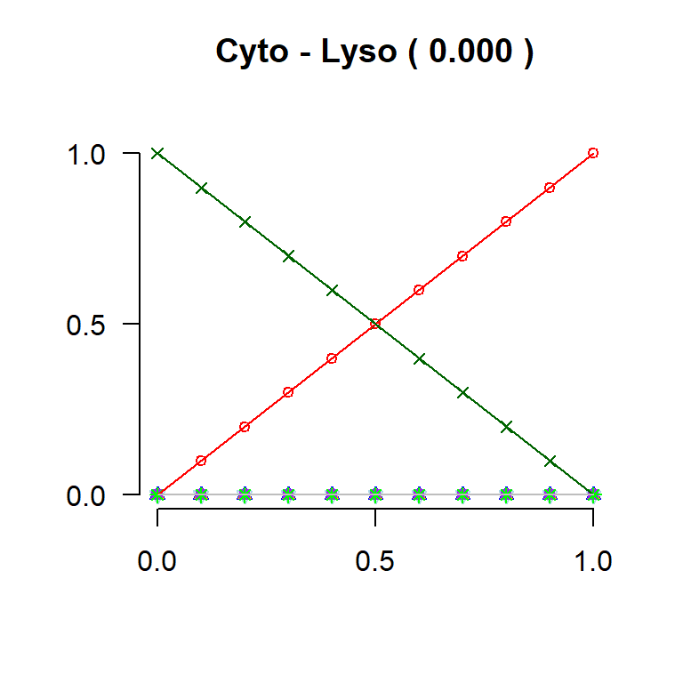

```r
library(pracma)
par(mfrow=c(1,1))  # reset window for a single plot
# The argument increment.prop needs to match the value used
#   in creating the mixture using proteinMix. This does
#   not need to be specified if using the value of 0.1
mixturePlot(mixProtiProtjCPA=mixCytoLysoCPAfromRSA,
            NstartMaterialFractions=6, Loc1=1, Loc2=4,
            increment.prop=0.1, xaxisLab=TRUE, yaxisLab=TRUE)
```

Here we see visually that the estimated proportions match the simulated ones. The prediction error, i.e., the area separated by the observed and expected CPA estimates, is nearly zero, and is shown in parentheses.

Next, we consider a mixture of Cyto with each of the other seven compartments using RSA-based transformations. We begin by setting up the plot area for a 4 by 2 array of plots. Optionally, to control the size of the window, we may want to explicitly open a window using `windows(height=10, width=7)`. Next, we fix one component of the mixture to the first, which is Cyto, and loop over the other 7 subcellular compartments, creating mixtures of the `refLocationProfilesAcup` values. For each case, we transform these mixtures to RSA and obtain CPA mixing proportion estimates from these RSA-transformed mixtures and compute the area-based prediction errors. These values are stored in a data frame `mixErrorMat` which is then renamed to avoid overwriting since multiple mixtures and transformations are being explored.

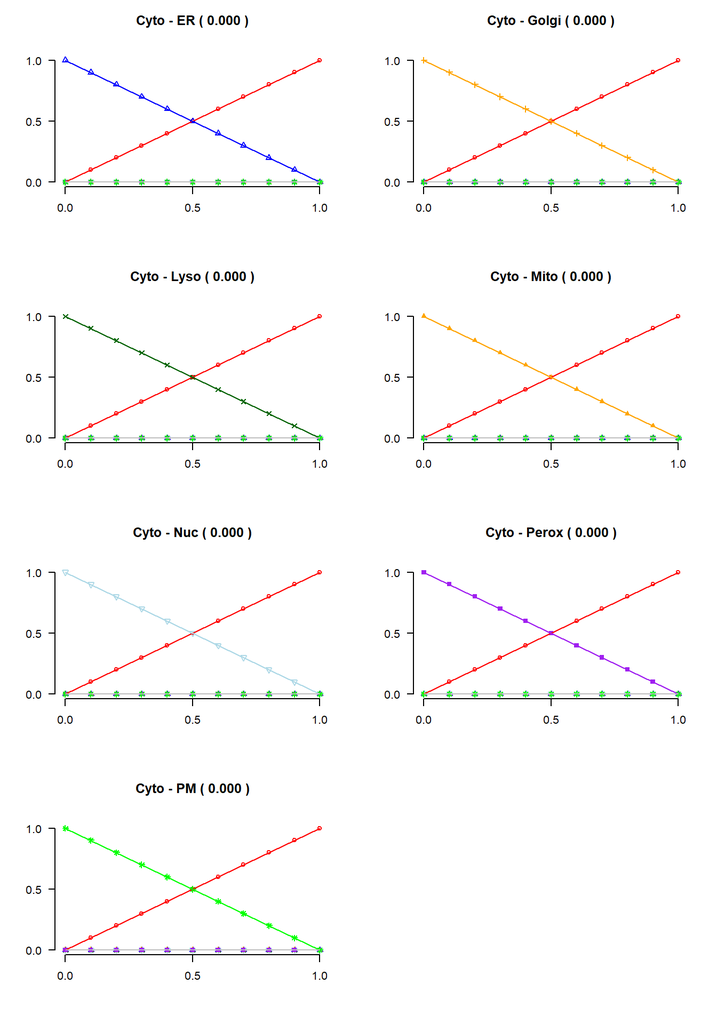

```r
par(mfrow=c(4,2))
i <- 1
mixErrorMat <- NULL
for (j in 2:8) {
   # Create the mixture of Cyto (i = 1) with compartment j
   mixProtiProtjAcup <- proteinMix(Acup=refLocationProfilesAcup,
                                   Loc1=i, Loc2=j)

   # Tranform the mixtures to RSAs
   mixProtiProtjRSA <- RSAfromAcup(Acup=mixProtiProtjAcup,
                        NstartMaterialFractions=6, totProt=totProt)

   # Find the CPAs
   mixProtiProtjCPAfromRSA <- fitCPA(profile=mixProtiProtjRSA,
                    refLocationProfiles=refLocationProfilesRSA,
                    numDataCols=9)

   # Plot the results, including the area-based error estimate,
   #    and collect the area-based errors (errorReturn=TRUE)
    mixResult <- mixturePlot(mixProtiProtjCPA=mixProtiProtjCPAfromRSA,
                             NstartMaterialFractions=6, Loc1=i, Loc2=j,
                             increment.prop=0.1, errorReturn = TRUE)
    mixErrorMat <- rbind(mixErrorMat, mixResult)
}
mixErrorAllCytoRSA <- mixErrorMat
```

All seven mixtures have essentially zero area-based error, as we expect. We can examine these errors with more precision as follows:

```r
mixErrorAllCytoRSA
```

```
#>   Loc1  Loc2    ErrorArea
#> 1 Cyto    ER 2.972911e-06
#> 2 Cyto Golgi 2.640887e-06
#> 3 Cyto  Lyso 1.036580e-06
#> 4 Cyto  Mito 5.357998e-07
#> 5 Cyto   Nuc 2.295012e-07
#> 6 Cyto Perox 9.606319e-07
#> 7 Cyto    PM 3.061754e-06
```

# 4 Tutorial 4: More on mixtures and transformations

In this tutorial, we explore the effect of using normalized specific amount (NSA), relative specific amount (RSA), and relative amount (Acup) data, and their log transformations on CPA. We also discuss the underlying reasons why the different transformations can yield different results, which may be useful in choosing the appropriate transformation for a particular protein distribution. We illustrate using two mixtures: Cyto with Lyso and Cyto with Nuc. We begin by creating the NSA profiles for the reference compartments, which we will use for further transformations and to create mixtures.

## 4.1 Applying CPA to RSA, NSA, or Acup data derived from simulated mixtures of Cyto and Lyso

For clarity of presentation and to allow the following commands to be used with any data set, we rename `totProtAT5` and `protProfileNSA_test` to `totProt` and `protProfileNSA`, respectively.

```r
library(protlocassign)
data(protNSA_test)
data(totProtAT5)
protNSA <- protNSA_test
totProt <- totProtAT5
```

```r
data(markerListJadot)
refLocationProfilesNSA <- locationProfileSetup(profile=protNSA,
                            markerList=markerListJadot, numDataCols=9)
refLocationProfilesAcup <- AcupFromNSA(refLocationProfilesNSA,
                            NstartMaterialFractions=6, totProt=totProt)
```

Now create markers using refLocationProfilesAcup compartments Cyto (row 1) and Lyso (row 4) in the standard way, and transform the mixtures to RSAs:

```r
i=1
j=4
mixProt1Prot4Acup <- proteinMix(refLocationProfilesAcup, Loc1=i, Loc2=j)
mixProt1Prot4RSA <- RSAfromAcup(Acup=mixProt1Prot4Acup,
                            NstartMaterialFractions=6, totProt=totProt)
# increment.prop is not specified so we use the default value of 0.1
```

As in Tutorial 3, we display the Acup and RSA profiles for these Cyto-Lyso mixtures:

```r
round(mixProt1Prot4Acup, digits=3)
```

```
#>                       N     M    L1    L2     P     S  Nyc1  Nyc2  Nyc3
#> 0_Cyto:1_Lyso     0.233 0.296 0.017 0.014 0.121 0.318 0.001 0.004 0.010
#> 0.1_Cyto:0.9_Lyso 0.221 0.276 0.016 0.013 0.113 0.361 0.001 0.003 0.009
#> 0.2_Cyto:0.8_Lyso 0.209 0.257 0.014 0.012 0.105 0.403 0.001 0.003 0.008
#> 0.3_Cyto:0.7_Lyso 0.197 0.237 0.013 0.011 0.097 0.446 0.000 0.003 0.008
#> 0.4_Cyto:0.6_Lyso 0.184 0.217 0.012 0.010 0.088 0.489 0.000 0.002 0.007
#> 0.5_Cyto:0.5_Lyso 0.172 0.197 0.010 0.009 0.080 0.531 0.000 0.002 0.006
#> 0.6_Cyto:0.4_Lyso 0.160 0.178 0.009 0.008 0.072 0.574 0.000 0.002 0.005
#> 0.7_Cyto:0.3_Lyso 0.148 0.158 0.007 0.007 0.063 0.616 0.000 0.001 0.004
#> 0.8_Cyto:0.2_Lyso 0.136 0.138 0.006 0.006 0.055 0.659 0.000 0.001 0.004
#> 0.9_Cyto:0.1_Lyso 0.123 0.119 0.005 0.005 0.047 0.702 0.000 0.001 0.003
#> 1_Cyto:0_Lyso     0.111 0.099 0.003 0.004 0.039 0.744 0.000 0.000 0.002
```

```r
round(mixProt1Prot4RSA, digits=3)
```

```
#>                       N     M    L1    L2     P     S  Nyc1  Nyc2  Nyc3
#> 0_Cyto:1_Lyso     0.913 1.089 2.251 1.612 0.909 0.985 3.102 9.410 1.401
#> 0.1_Cyto:0.9_Lyso 0.865 1.017 2.068 1.492 0.847 1.117 2.864 8.529 1.291
#> 0.2_Cyto:0.8_Lyso 0.817 0.944 1.884 1.372 0.785 1.249 2.626 7.648 1.181
#> 0.3_Cyto:0.7_Lyso 0.770 0.872 1.701 1.252 0.723 1.381 2.387 6.766 1.070
#> 0.4_Cyto:0.6_Lyso 0.722 0.799 1.518 1.132 0.661 1.513 2.149 5.885 0.960
#> 0.5_Cyto:0.5_Lyso 0.674 0.727 1.334 1.012 0.600 1.645 1.911 5.003 0.850
#> 0.6_Cyto:0.4_Lyso 0.626 0.654 1.151 0.892 0.538 1.777 1.673 4.122 0.740
#> 0.7_Cyto:0.3_Lyso 0.578 0.582 0.968 0.772 0.476 1.909 1.434 3.240 0.629
#> 0.8_Cyto:0.2_Lyso 0.531 0.509 0.784 0.652 0.414 2.041 1.196 2.359 0.519
#> 0.9_Cyto:0.1_Lyso 0.483 0.437 0.601 0.532 0.352 2.173 0.958 1.478 0.409
#> 1_Cyto:0_Lyso     0.435 0.364 0.418 0.413 0.290 2.305 0.720 0.596 0.299
```

Next, obtain CPA estimates using the RSA-transformed mixtures and RSA-transformed references profiles. We see that the CPA estimates match the proportions we used to create the mixtures:

```r
refLocationProfilesRSA <- RSAfromNSA(NSA=refLocationProfilesNSA,
                          NstartMaterialFractions=6,
                          totProt=totProt)
mixProt1Prot4CPAfromRSA <- fitCPA(profile=mixProt1Prot4RSA,
                      refLocationProfiles=refLocationProfilesRSA,
                      numDataCols=9)
round(mixProt1Prot4CPAfromRSA, digits=3)
```

```
#>                   Cyto ER Golgi Lyso Mito Nuc Perox PM
#> 0_Cyto:1_Lyso      0.0  0     0  1.0    0   0     0  0
#> 0.1_Cyto:0.9_Lyso  0.1  0     0  0.9    0   0     0  0
#> 0.2_Cyto:0.8_Lyso  0.2  0     0  0.8    0   0     0  0
#> 0.3_Cyto:0.7_Lyso  0.3  0     0  0.7    0   0     0  0
#> 0.4_Cyto:0.6_Lyso  0.4  0     0  0.6    0   0     0  0
#> 0.5_Cyto:0.5_Lyso  0.5  0     0  0.5    0   0     0  0
#> 0.6_Cyto:0.4_Lyso  0.6  0     0  0.4    0   0     0  0
#> 0.7_Cyto:0.3_Lyso  0.7  0     0  0.3    0   0     0  0
#> 0.8_Cyto:0.2_Lyso  0.8  0     0  0.2    0   0     0  0
#> 0.9_Cyto:0.1_Lyso  0.9  0     0  0.1    0   0     0  0
#> 1_Cyto:0_Lyso      1.0  0     0  0.0    0   0     0  0
```

We may obtain the normalized specific amounts transformation of `mixProtiProtjRSA` by using the `NSAfromRSA` function:

```r
mixProt1Prot4NSA <- NSAfromRSA(mixProt1Prot4RSA)
round(mixProt1Prot4NSA, digits=3)
```

```
#>                       N     M    L1    L2     P     S  Nyc1  Nyc2  Nyc3
#> 0_Cyto:1_Lyso     0.042 0.050 0.104 0.074 0.042 0.045 0.143 0.434 0.065
#> 0.1_Cyto:0.9_Lyso 0.043 0.051 0.103 0.074 0.042 0.056 0.143 0.425 0.064
#> 0.2_Cyto:0.8_Lyso 0.044 0.051 0.102 0.074 0.042 0.067 0.142 0.413 0.064
#> 0.3_Cyto:0.7_Lyso 0.045 0.052 0.101 0.074 0.043 0.082 0.141 0.400 0.063
#> 0.4_Cyto:0.6_Lyso 0.047 0.052 0.099 0.074 0.043 0.099 0.140 0.384 0.063
#> 0.5_Cyto:0.5_Lyso 0.049 0.053 0.097 0.074 0.044 0.120 0.139 0.364 0.062
#> 0.6_Cyto:0.4_Lyso 0.051 0.054 0.095 0.073 0.044 0.146 0.137 0.339 0.061
#> 0.7_Cyto:0.3_Lyso 0.055 0.055 0.091 0.073 0.045 0.180 0.135 0.306 0.059
#> 0.8_Cyto:0.2_Lyso 0.059 0.057 0.087 0.072 0.046 0.227 0.133 0.262 0.058
#> 0.9_Cyto:0.1_Lyso 0.065 0.059 0.081 0.072 0.047 0.293 0.129 0.199 0.055
#> 1_Cyto:0_Lyso     0.074 0.062 0.072 0.071 0.050 0.395 0.123 0.102 0.051
```

We next apply the CPA routine to these normalized specific amount (NSA) profiles:

```r
mixProt1Prot4CPAfromNSA <- fitCPA(profile=mixProt1Prot4NSA,
                             refLocationProfiles=refLocationProfilesNSA,
                             numDataCols=9)
round(mixProt1Prot4CPAfromNSA, digits=3)
```

```
#>                    Cyto ER Golgi  Lyso Mito Nuc Perox PM
#> 0_Cyto:1_Lyso     0.000  0     0 1.000    0   0     0  0
#> 0.1_Cyto:0.9_Lyso 0.029  0     0 0.971    0   0     0  0
#> 0.2_Cyto:0.8_Lyso 0.063  0     0 0.937    0   0     0  0
#> 0.3_Cyto:0.7_Lyso 0.104  0     0 0.896    0   0     0  0
#> 0.4_Cyto:0.6_Lyso 0.152  0     0 0.848    0   0     0  0
#> 0.5_Cyto:0.5_Lyso 0.212  0     0 0.788    0   0     0  0
#> 0.6_Cyto:0.4_Lyso 0.288  0     0 0.712    0   0     0  0
#> 0.7_Cyto:0.3_Lyso 0.386  0     0 0.614    0   0     0  0
#> 0.8_Cyto:0.2_Lyso 0.519  0     0 0.481    0   0     0  0
#> 0.9_Cyto:0.1_Lyso 0.708  0     0 0.292    0   0     0  0
#> 1_Cyto:0_Lyso     1.000  0     0 0.000    0   0     0  0
```

Now, instead of transforming the Acup mixtures to RSA’s or using NSA’s, what happens if we just use the Acup mixtures themselves, i.e., the relative amounts? There are significant departures of the CPA estimates, including assignments to compartments not used in the simulations from the proportions used to create the mixtures:

```r
mixProt1Prot4CPAfromAcup <-
                  fitCPA(profile=mixProt1Prot4Acup,
                          refLocationProfiles=refLocationProfilesAcup,
                         numDataCols=9)
round(mixProt1Prot4CPAfromAcup, digits=3)
```

```
#>                    Cyto    ER Golgi  Lyso  Mito Nuc Perox    PM
#> 0_Cyto:1_Lyso     0.016 0.010     0 0.927 0.014   0 0.024 0.009
#> 0.1_Cyto:0.9_Lyso 0.137 0.023     0 0.732 0.032   0 0.055 0.021
#> 0.2_Cyto:0.8_Lyso 0.222 0.014     0 0.699 0.019   0 0.033 0.013
#> 0.3_Cyto:0.7_Lyso 0.326 0.016     0 0.583 0.022   0 0.038 0.015
#> 0.4_Cyto:0.6_Lyso 0.444 0.027     0 0.403 0.037   0 0.064 0.024
#> 0.5_Cyto:0.5_Lyso 0.566 0.041     0 0.202 0.056   0 0.098 0.037
#> 0.6_Cyto:0.4_Lyso 0.627 0.017     0 0.278 0.023   0 0.040 0.015
#> 0.7_Cyto:0.3_Lyso 0.736 0.022     0 0.139 0.030   0 0.053 0.020
#> 0.8_Cyto:0.2_Lyso 0.824 0.015     0 0.091 0.020   0 0.036 0.014
#> 0.9_Cyto:0.1_Lyso 0.913 0.009     0 0.043 0.011   0 0.019 0.006
#> 1_Cyto:0_Lyso     1.000 0.000     0 0.000 0.000   0 0.000 0.000
```

Displaying the Acup values using `refLocationProfilesAcup` helps explain these discrepancies. Note that the three Nyc columns, which are important for classifying lysosomal proteins, are very small, which effectively down-weights their importance in the CPA procedure:

```r
round(refLocationProfilesAcup, digits=4)
```

```
#>            N      M     L1     L2      P      S  Nyc1   Nyc2   Nyc3
#> Cyto  0.1111 0.0990 0.0032 0.0036 0.0387 0.7443 1e-04 0.0002 0.0021
#> ER    0.2688 0.2076 0.0084 0.0210 0.3689 0.1254 2e-04 0.0004 0.0060
#> Golgi 0.2487 0.1765 0.0050 0.0090 0.4510 0.1099 4e-04 0.0007 0.0027
#> Lyso  0.2333 0.2960 0.0173 0.0140 0.1213 0.3181 6e-04 0.0036 0.0099
#> Mito  0.2473 0.5848 0.0089 0.0048 0.0429 0.1114 1e-04 0.0002 0.0063
#> Nuc   0.8750 0.0384 0.0005 0.0014 0.0231 0.0616 0e+00 0.0001 0.0009
#> Perox 0.2326 0.3270 0.0375 0.0208 0.0890 0.2931 2e-04 0.0005 0.0266
#> PM    0.3954 0.2303 0.0083 0.0137 0.1987 0.1537 7e-04 0.0009 0.0048
```

Plots of the CPA estimated vs actual mixture proportions can be generated as described in the previous tutorial. As before, the x-coordinate represents the theoretical distribution based on simulation parameters and the y-coordinate represents the predicted values based on CPA. The assignment errors are show in parentheses.

```r
par(mfrow=c(1,3))
# In the following, the argument increment.prop is not specified so
#  we use the default value of 0.1
mixturePlot(mixProtiProtjCPA=mixProt1Prot4CPAfromRSA,
            NstartMaterialFractions=6, Loc1=i, Loc2=j,
            errorReturn = TRUE, subTitle="RSA")
```

```
#>   Loc1 Loc2   ErrorArea
#> 1 Cyto Lyso 1.03658e-06
```

```r
mixturePlot(mixProtiProtjCPA=mixProt1Prot4CPAfromNSA,
            NstartMaterialFractions=6, Loc1=i, Loc2=j,
            errorReturn = TRUE, subTitle="NSA")
```

```
#>   Loc1 Loc2 ErrorArea
#> 1 Cyto Lyso 0.4078443
```

```
#>   Loc1 Loc2 ErrorArea
#> 1 Cyto Lyso 0.2730926
```

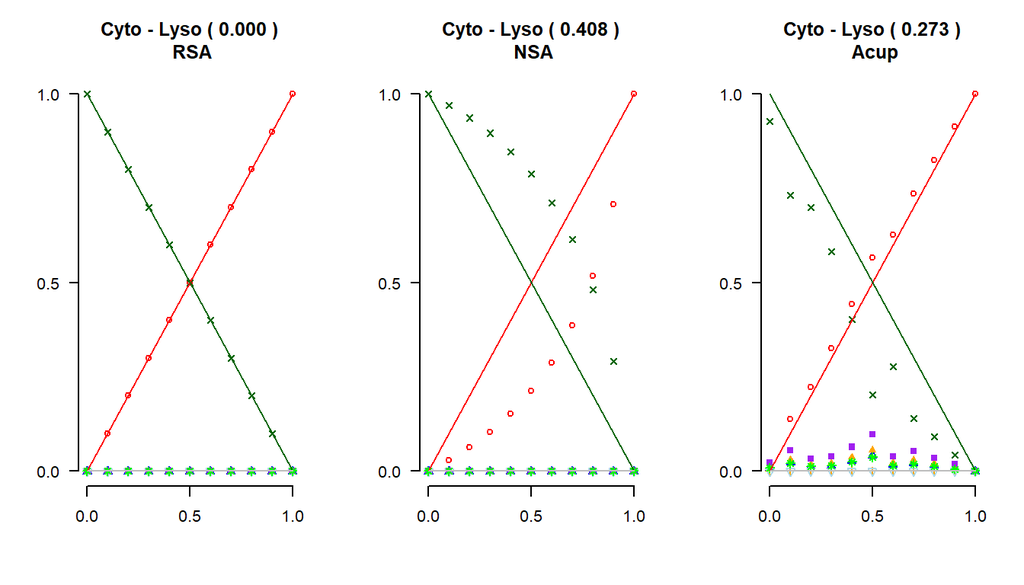

```r
mixturePlot(mixProtiProtjCPA=mixProt1Prot4CPAfromAcup,
            NstartMaterialFractions=6, Loc1=i, Loc2=j,
            errorReturn = TRUE, subTitle="Acup")
```

We may obtain only the areas indicating the prediction error by using the `mixtureAreaError` function.

```r
# As discussed earlier, the argument increment.prop=0.1 does not
#  need to be specified because it is the default
#  and is consistent with the previously generated mixtures.
mixtureAreaError(mixProtiProtjCPA=mixProt1Prot4CPAfromRSA,
            NstartMaterialFractions=6, Loc1=i, Loc2=j)
```

```
#> [1] 1.03658e-06
```

```r
mixtureAreaError(mixProtiProtjCPA=mixProt1Prot4CPAfromNSA,
            NstartMaterialFractions=6, Loc1=i, Loc2=j)
```

```
#> [1] 0.4078443
```

```r
mixtureAreaError(mixProtiProtjCPA=mixProt1Prot4CPAfromAcup,
            NstartMaterialFractions=6, Loc1=i, Loc2=j)
```

```
#> [1] 0.2730926
```

## 4.2 Applying CPA to log transformations of Cyto and Lyso mixtures

```r
eps <- 0.001


mixProt1Prot4CPAfromRSAlog2 <- fitCPA(profile=log2(mixProt1Prot4RSA + eps),
                      refLocationProfiles=log2(refLocationProfilesRSA + eps),
                      numDataCols=9)
round(mixProt1Prot4CPAfromRSAlog2, digits=3)
```

```
#>                    Cyto ER Golgi  Lyso Mito Nuc Perox PM
#> 0_Cyto:1_Lyso     0.000  0     0 1.000    0   0     0  0
#> 0.1_Cyto:0.9_Lyso 0.052  0     0 0.948    0   0     0  0
#> 0.2_Cyto:0.8_Lyso 0.107  0     0 0.893    0   0     0  0
#> 0.3_Cyto:0.7_Lyso 0.167  0     0 0.833    0   0     0  0
#> 0.4_Cyto:0.6_Lyso 0.233  0     0 0.767    0   0     0  0
#> 0.5_Cyto:0.5_Lyso 0.307  0     0 0.693    0   0     0  0
#> 0.6_Cyto:0.4_Lyso 0.390  0     0 0.610    0   0     0  0
#> 0.7_Cyto:0.3_Lyso 0.488  0     0 0.512    0   0     0  0
#> 0.8_Cyto:0.2_Lyso 0.607  0     0 0.393    0   0     0  0
#> 0.9_Cyto:0.1_Lyso 0.762  0     0 0.238    0   0     0  0
#> 1_Cyto:0_Lyso     1.000  0     0 0.000    0   0     0  0
```

```r
mixProt1Prot4CPAfromNSAlog2 <-
            fitCPA(profile=log2(mixProt1Prot4NSA + eps),
                refLocationProfiles=log2(refLocationProfilesNSA + eps),
                numDataCols=9)
round(mixProt1Prot4CPAfromNSAlog2, digits=3)
```

```
#>                    Cyto ER Golgi  Lyso Mito Nuc Perox PM
#> 0_Cyto:1_Lyso     0.000  0     0 1.000    0   0     0  0
#> 0.1_Cyto:0.9_Lyso 0.065  0     0 0.935    0   0     0  0
#> 0.2_Cyto:0.8_Lyso 0.130  0     0 0.870    0   0     0  0
#> 0.3_Cyto:0.7_Lyso 0.196  0     0 0.804    0   0     0  0
#> 0.4_Cyto:0.6_Lyso 0.264  0     0 0.736    0   0     0  0
#> 0.5_Cyto:0.5_Lyso 0.336  0     0 0.664    0   0     0  0
#> 0.6_Cyto:0.4_Lyso 0.415  0     0 0.585    0   0     0  0
#> 0.7_Cyto:0.3_Lyso 0.505  0     0 0.495    0   0     0  0
#> 0.8_Cyto:0.2_Lyso 0.614  0     0 0.386    0   0     0  0
#> 0.9_Cyto:0.1_Lyso 0.758  0     0 0.242    0   0     0  0
#> 1_Cyto:0_Lyso     1.000  0     0 0.000    0   0     0  0
```

```r
mixProt1Prot4CPAfromAcupLog2 <-
            fitCPA(profile=log2(mixProt1Prot4Acup + eps),
              refLocationProfiles=log2(refLocationProfilesAcup + eps),
              numDataCols=9)
round(mixProt1Prot4CPAfromAcupLog2, digits=3)
```

```
#>                    Cyto ER Golgi  Lyso Mito Nuc Perox PM
#> 0_Cyto:1_Lyso     0.000  0     0 1.000    0   0 0.000  0
#> 0.1_Cyto:0.9_Lyso 0.066  0     0 0.932    0   0 0.002  0
#> 0.2_Cyto:0.8_Lyso 0.136  0     0 0.860    0   0 0.004  0
#> 0.3_Cyto:0.7_Lyso 0.209  0     0 0.785    0   0 0.006  0
#> 0.4_Cyto:0.6_Lyso 0.288  0     0 0.704    0   0 0.008  0
#> 0.5_Cyto:0.5_Lyso 0.374  0     0 0.617    0   0 0.010  0
#> 0.6_Cyto:0.4_Lyso 0.468  0     0 0.522    0   0 0.011  0
#> 0.7_Cyto:0.3_Lyso 0.572  0     0 0.417    0   0 0.011  0
#> 0.8_Cyto:0.2_Lyso 0.692  0     0 0.298    0   0 0.010  0
#> 0.9_Cyto:0.1_Lyso 0.831  0     0 0.162    0   0 0.007  0
#> 1_Cyto:0_Lyso     1.000  0     0 0.000    0   0 0.000  0
```

Following are plots of the CPA estimated vs actual mixture proportions for simulated proteins where the different profiles (RSA, NSA, and Acup) are log2-transformed.

```r
par(mfrow=c(1,3))
mixturePlot(mixProtiProtjCPA=mixProt1Prot4CPAfromRSAlog2,
            NstartMaterialFractions=6,
            Loc1=i, Loc2=j, errorReturn = TRUE,
            subTitle="Log2 RSA")
```

```
#>   Loc1 Loc2 ErrorArea
#> 1 Cyto Lyso 0.2773714
```

```r
mixturePlot(mixProtiProtjCPA=mixProt1Prot4CPAfromNSAlog2,
            NstartMaterialFractions=6,
            Loc1=i, Loc2=j, errorReturn = TRUE,
            subTitle="Log2 NSA")
```

```
#>   Loc1 Loc2 ErrorArea
#> 1 Cyto Lyso 0.2436682
```

```
#>   Loc1 Loc2 ErrorArea
#> 1 Cyto Lyso  0.172925
```

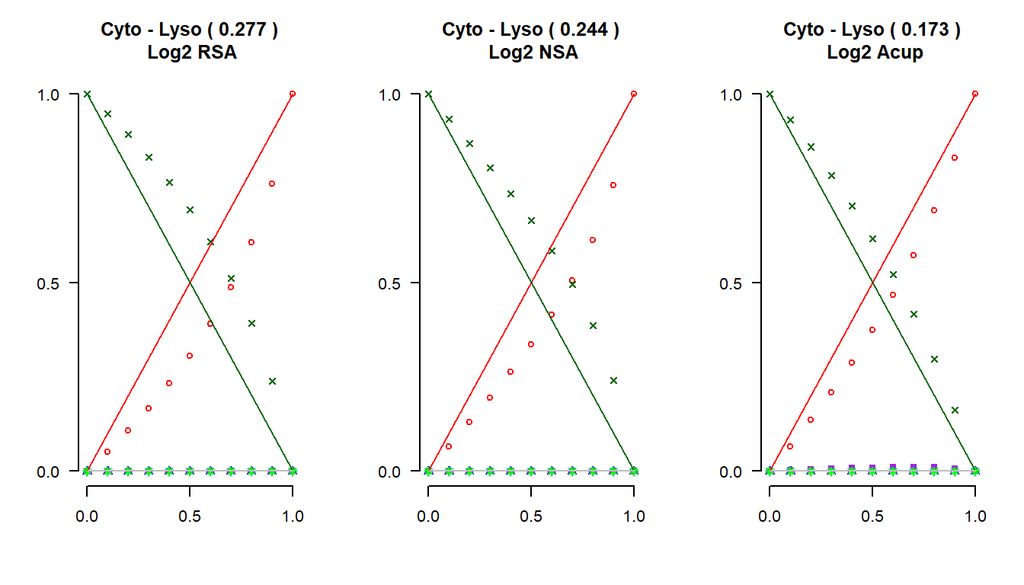

```r
mixturePlot(mixProtiProtjCPA=mixProt1Prot4CPAfromAcupLog2,
            NstartMaterialFractions=6, Loc1=i, Loc2=j,
            errorReturn = TRUE, subTitle="Log2 Acup")
```

## 4.3 Applying CPA to RSA, NSA, or Acup data derived from simulated mixtures of Cyto and Nuc

In this section, we consider Cyto and Nuc mixtures, which we generate as described above for Cyto and Lyso. We shall see that here, Acup-transformed values result in CPA estimates that are as accurate as those obtained using RSA-transformed values. The reason for this is that, unlike with Lyso, the Nuc (and Cyto) profiles do not depend on the Nyc portions of the values, and thus the estimated subcellular residence proportions do not suffer from the extremely small Nyc profile values.

Here are the CPA estimates from RSA-transformed profiles:

```r
i=1  # Cyto
j=6  # Nuc
mixProt1Prot6Acup <- proteinMix(refLocationProfilesAcup, Loc1=i, Loc2=j)
mixProt1Prot6RSA <- RSAfromAcup(Acup=mixProt1Prot6Acup,
                          NstartMaterialFractions=6, totProt=totProtAT5)


mixProt1Prot6CPAfromRSA <- fitCPA(profile=mixProt1Prot6RSA,
            refLocationProfiles=refLocationProfilesRSA, numDataCols=9)
round(mixProt1Prot6CPAfromRSA, digits=3)
```

```
#>                  Cyto ER Golgi Lyso Mito Nuc Perox PM
#> 0_Cyto:1_Nuc      0.0  0     0    0    0 1.0     0  0
#> 0.1_Cyto:0.9_Nuc  0.1  0     0    0    0 0.9     0  0
#> 0.2_Cyto:0.8_Nuc  0.2  0     0    0    0 0.8     0  0
#> 0.3_Cyto:0.7_Nuc  0.3  0     0    0    0 0.7     0  0
#> 0.4_Cyto:0.6_Nuc  0.4  0     0    0    0 0.6     0  0
#> 0.5_Cyto:0.5_Nuc  0.5  0     0    0    0 0.5     0  0
#> 0.6_Cyto:0.4_Nuc  0.6  0     0    0    0 0.4     0  0
#> 0.7_Cyto:0.3_Nuc  0.7  0     0    0    0 0.3     0  0
#> 0.8_Cyto:0.2_Nuc  0.8  0     0    0    0 0.2     0  0
#> 0.9_Cyto:0.1_Nuc  0.9  0     0    0    0 0.1     0  0
#> 1_Cyto:0_Nuc      1.0  0     0    0    0 0.0     0  0
```

The simulated proportions are estimated very accurately.

Following Tutorial 3, we may see what happens if we apply the CPA routine to profiles containing NSA data:

```r
mixProt1Prot6NSA <- NSAfromRSA(mixProt1Prot6RSA)
mixProt1Prot6CPAfromNSA <-
                    fitCPA(profile=mixProt1Prot6NSA,
                    refLocationProfiles=refLocationProfilesNSA,
                    numDataCols=9)
round(mixProt1Prot6CPAfromNSA, digits=3)
```

```
#>                   Cyto ER Golgi Lyso Mito   Nuc Perox PM
#> 0_Cyto:1_Nuc     0.000  0     0    0    0 1.000     0  0
#> 0.1_Cyto:0.9_Nuc 0.123  0     0    0    0 0.877     0  0
#> 0.2_Cyto:0.8_Nuc 0.239  0     0    0    0 0.761     0  0
#> 0.3_Cyto:0.7_Nuc 0.351  0     0    0    0 0.649     0  0
#> 0.4_Cyto:0.6_Nuc 0.456  0     0    0    0 0.544     0  0
#> 0.5_Cyto:0.5_Nuc 0.557  0     0    0    0 0.443     0  0
#> 0.6_Cyto:0.4_Nuc 0.654  0     0    0    0 0.346     0  0
#> 0.7_Cyto:0.3_Nuc 0.746  0     0    0    0 0.254     0  0
#> 0.8_Cyto:0.2_Nuc 0.834  0     0    0    0 0.166     0  0
#> 0.9_Cyto:0.1_Nuc 0.919  0     0    0    0 0.081     0  0
#> 1_Cyto:0_Nuc     1.000  0     0    0    0 0.000     0  0
```

The estimates of the proportions deviate somewhat from those used to generate the mixtures.

Now do this using the relative amounts for markers (“Acup markers”) and simulated protein mixtures (Acup) instead of RSA-transformed values.

```r
mixProt1Prot6CPAfromAcup <- fitCPA(profile=mixProt1Prot6Acup,
                             refLocationProfiles=refLocationProfilesAcup,
                             numDataCols=9)
```

Note that, unlike what we saw using Acup profiles of the Cyto-Lyso mixture, the estimates using Acup profiles of the Cyto-Nuc mixtures are very accurate, and superior to those using NSA profiles:

```r
round(mixProt1Prot6CPAfromAcup, digits=3)
```

```
#>                  Cyto ER Golgi Lyso Mito Nuc Perox PM
#> 0_Cyto:1_Nuc      0.0  0     0    0    0 1.0     0  0
#> 0.1_Cyto:0.9_Nuc  0.1  0     0    0    0 0.9     0  0
#> 0.2_Cyto:0.8_Nuc  0.2  0     0    0    0 0.8     0  0
#> 0.3_Cyto:0.7_Nuc  0.3  0     0    0    0 0.7     0  0
#> 0.4_Cyto:0.6_Nuc  0.4  0     0    0    0 0.6     0  0
#> 0.5_Cyto:0.5_Nuc  0.5  0     0    0    0 0.5     0  0
#> 0.6_Cyto:0.4_Nuc  0.6  0     0    0    0 0.4     0  0
#> 0.7_Cyto:0.3_Nuc  0.7  0     0    0    0 0.3     0  0
#> 0.8_Cyto:0.2_Nuc  0.8  0     0    0    0 0.2     0  0
#> 0.9_Cyto:0.1_Nuc  0.9  0     0    0    0 0.1     0  0
#> 1_Cyto:0_Nuc      1.0  0     0    0    0 0.0     0  0
```

The CPA for these different transformations can be plotted versus the true proportions as before:

```r
par(mfrow=c(1,3))
mixturePlot(mixProtiProtjCPA=mixProt1Prot6CPAfromRSA,
            NstartMaterialFractions=6, Loc1=i, Loc2=j,
            errorReturn = TRUE, subTitle="RSA")
```

```
#>   Loc1 Loc2    ErrorArea
#> 1 Cyto  Nuc 2.295012e-07
```

```r
mixturePlot(mixProtiProtjCPA=mixProt1Prot6CPAfromNSA,
            NstartMaterialFractions=6, Loc1=i, Loc2=j,
            errorReturn = TRUE, subTitle="NSA")
```

```
#>   Loc1 Loc2  ErrorArea
#> 1 Cyto  Nuc 0.07599729
```

```
#>   Loc1 Loc2    ErrorArea
#> 1 Cyto  Nuc 3.487184e-06
```

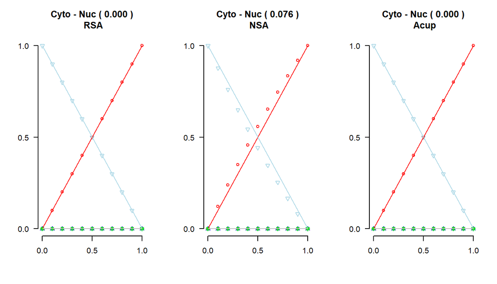

```r
mixturePlot(mixProtiProtjCPA=mixProt1Prot6CPAfromAcup,
            NstartMaterialFractions=6, Loc1=i, Loc2=j,
            errorReturn = TRUE, subTitle="Acup")
```

## 4.4 Applying CPA to log transformations of Cyto and Nuc mixtures

Now try a log2 transformation on different types of simulated protein and marker profiles (RSA’s, NSA’s, and Acup). Note that in all cases, the CPA values using log-transformed data are less accurate than when using untransformed data.

```r
eps <- 0.001

mixProt1Prot6CPAfromRSAlog2 <-
           fitCPA(profile=log2(mixProt1Prot6RSA + eps),
                refLocationProfiles=log2(refLocationProfilesRSA + eps),
                numDataCols=9)
round(mixProt1Prot6CPAfromRSAlog2, digits=3)
```

```
#>                   Cyto ER Golgi  Lyso Mito   Nuc Perox    PM
#> 0_Cyto:1_Nuc     0.000  0     0 0.000    0 1.000 0.000 0.000
#> 0.1_Cyto:0.9_Nuc 0.192  0     0 0.000    0 0.808 0.000 0.000
#> 0.2_Cyto:0.8_Nuc 0.320  0     0 0.003    0 0.677 0.000 0.000
#> 0.3_Cyto:0.7_Nuc 0.404  0     0 0.015    0 0.577 0.003 0.000
#> 0.4_Cyto:0.6_Nuc 0.475  0     0 0.027    0 0.492 0.006 0.000
#> 0.5_Cyto:0.5_Nuc 0.541  0     0 0.036    0 0.415 0.009 0.000
#> 0.6_Cyto:0.4_Nuc 0.607  0     0 0.041    0 0.342 0.010 0.000
#> 0.7_Cyto:0.3_Nuc 0.677  0     0 0.043    0 0.270 0.011 0.000
#> 0.8_Cyto:0.2_Nuc 0.756  0     0 0.039    0 0.194 0.010 0.001
#> 0.9_Cyto:0.1_Nuc 0.856  0     0 0.025    0 0.108 0.007 0.003
#> 1_Cyto:0_Nuc     1.000  0     0 0.000    0 0.000 0.000 0.000
```

```r
mixProt1Prot6CPAfromNSAlog2 <-
           fitCPA(profile=log2(mixProt1Prot6NSA + eps),
                refLocationProfiles=log2(refLocationProfilesNSA + eps),
                numDataCols=9)
round(mixProt1Prot6CPAfromNSAlog2, digits=3)
```

```
#>                   Cyto ER Golgi Lyso Mito   Nuc Perox PM
#> 0_Cyto:1_Nuc     0.000  0     0    0    0 1.000     0  0
#> 0.1_Cyto:0.9_Nuc 0.190  0     0    0    0 0.810     0  0
#> 0.2_Cyto:0.8_Nuc 0.320  0     0    0    0 0.680     0  0
#> 0.3_Cyto:0.7_Nuc 0.423  0     0    0    0 0.577     0  0
#> 0.4_Cyto:0.6_Nuc 0.511  0     0    0    0 0.489     0  0
#> 0.5_Cyto:0.5_Nuc 0.590  0     0    0    0 0.410     0  0
#> 0.6_Cyto:0.4_Nuc 0.665  0     0    0    0 0.335     0  0
#> 0.7_Cyto:0.3_Nuc 0.737  0     0    0    0 0.263     0  0
#> 0.8_Cyto:0.2_Nuc 0.812  0     0    0    0 0.188     0  0
#> 0.9_Cyto:0.1_Nuc 0.895  0     0    0    0 0.105     0  0
#> 1_Cyto:0_Nuc     1.000  0     0    0    0 0.000     0  0
```

```r
mixProt1Prot6CPAfromAcupLog2 <-
           fitCPA(profile=log2(mixProt1Prot6Acup + eps),
               refLocationProfiles=log2(refLocationProfilesAcup + eps),
               numDataCols=9)
round(mixProt1Prot6CPAfromAcupLog2, digits=3)
```

```
#>                   Cyto ER Golgi  Lyso Mito   Nuc Perox PM
#> 0_Cyto:1_Nuc     0.000  0     0 0.000    0 1.000 0.000  0
#> 0.1_Cyto:0.9_Nuc 0.184  0     0 0.000    0 0.816 0.000  0
#> 0.2_Cyto:0.8_Nuc 0.307  0     0 0.000    0 0.693 0.000  0
#> 0.3_Cyto:0.7_Nuc 0.405  0     0 0.000    0 0.595 0.000  0
#> 0.4_Cyto:0.6_Nuc 0.485  0     0 0.004    0 0.510 0.000  0
#> 0.5_Cyto:0.5_Nuc 0.552  0     0 0.015    0 0.433 0.000  0
#> 0.6_Cyto:0.4_Nuc 0.617  0     0 0.019    0 0.359 0.004  0
#> 0.7_Cyto:0.3_Nuc 0.686  0     0 0.022    0 0.285 0.007  0
#> 0.8_Cyto:0.2_Nuc 0.764  0     0 0.021    0 0.206 0.009  0
#> 0.9_Cyto:0.1_Nuc 0.861  0     0 0.015    0 0.116 0.007  0
#> 1_Cyto:0_Nuc     1.000  0     0 0.000    0 0.000 0.000  0
```

Following are plots of the CPA estimated vs actual proportions using the log2-transformed profiles.

```r
par(mfrow=c(1,3))
mixturePlot(mixProtiProtjCPA=mixProt1Prot6CPAfromRSAlog2,
            NstartMaterialFractions=6, Loc1=i, Loc2=j,
            errorReturn = TRUE, subTitle="Log2RSA")
```

```
#>   Loc1 Loc2 ErrorArea
#> 1 Cyto  Nuc 0.1235911
```

```r
mixturePlot(mixProtiProtjCPA=mixProt1Prot6CPAfromNSAlog2,
            NstartMaterialFractions=6, Loc1=i, Loc2=j,
            errorReturn = TRUE, subTitle="Log2NSA")
```

```
#>   Loc1 Loc2 ErrorArea
#> 1 Cyto  Nuc 0.1287119
```

```
#>   Loc1 Loc2  ErrorArea
#> 1 Cyto  Nuc 0.09727037
```

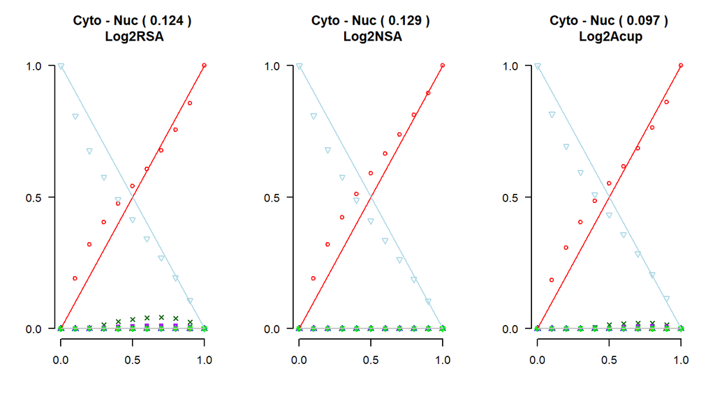

```r
mixturePlot(mixProtiProtjCPA=mixProt1Prot6CPAfromAcupLog2,
            NstartMaterialFractions=6, Loc1=i, Loc2=j,
            errorReturn = TRUE, subTitle="Log2Acup")
```

## 4.5 Transformation fitting error heatmaps

We may visualize the area-based errors for all pairwise mixtures using the `mixtureHeatMap` function, which requires prior installation of the `plot.matrix` R library. For each pair of compartments, this function first creates the mixtures as described earlier using the `Acup` markers. Then it computes the three transformations we have discussed, as well as the log2 transformations of these. These values are presented as a 2 by 3 array, with the three transformations as columns (RSA, left; NSA, center; Acup, right). The top row uses the original values (identity transformation), and the bottom row uses a log2 transformation of these values. The prediction errors are listed in each box with larger errors indicated by darker colors. These 2 by 3 heat maps are arranged in an upper triangular array, with each entry corresponding to a mixture of the indicated row and column compartments.

This function requires additional packages which should be installed prior to running the `mixtureHeatMap` function:

```
install.packages(c("plot.matrix", "viridis", "grid", "gridExtra"))
```

In addition to plotting a heat map, the `mixtureHeatMap` function returns a two by three matrix of total errors, which comprise a sum across all 28 tables, which we write to a variable named `errorMatAll`. In this tutorial the `mixtureHeatMap` function calls a pre-calculated data frame `errorList9` of errors. This is only to save computation time for showing the results for this example. In practice one would cause the function to calculate these errors anew by not including the argument `errorListIn`, since it will then take the default value `NULL`.

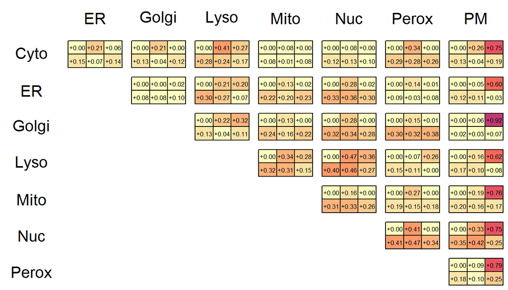

```r
par(mfrow=c(1,1))
data(errorList9)
errorMatAll <- mixtureHeatMap(Acup=refLocationProfilesAcup,
                                 totProt=totProt, errorListIn=errorList9)
```

We can view these total errors as follows:

```r
round(errorMatAll, digits=4)
```

```
#>        [,1]   [,2]   [,3]
#> [1,] 0.0001 5.7468 7.0376
#> [2,] 6.0254 5.3820 4.8845
```

Alternatively, we can visualize `errorMatAll` as a heatmap, with darker colors indicating greater errors:

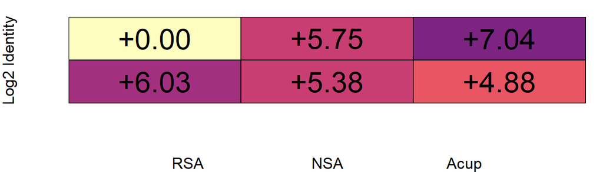

```r
op <- par(mar=c(4,4,1,1))  # save default parameters in variable op

col <- rev(viridis::magma(12))
plot(errorMatAll, col=col, breaks=seq(0, 12, 1), key=NULL, main="",
     axis.col=NULL, axis.row=NULL,
     xlab="RSA                        NSA                       Acup",
     ylab="Log2 Identity", digits=2, cex=2, cex.lab=1.1)
par(op) # restore default parameters
```

These heatmaps demonstrate that for all combinations of compartments, using RSAs without any further log transformation for CPA results in the most accurate estimates of the true mixtures.

## 4.6 Plotting all pairs of mixtures

We may use the function `mixturePlotPanel` to make these plots for all 8*7/2 = 28 possible pairs of mixtures. The function does this for CPA values using different types of mixture profiles, specifying with the argument fitType (e.g., fitType = “RSA”, “NSA” or “Acup”). An option is also available to transform either of these using `y = log2(x + eps)`, where `eps` is a small number; by default, `eps = 0.001`, by specifying `log2Transf=TRUE`. The function also can output a table of area-based errors for all 28 mixture pairs by specifying the option `errorReturn = TRUE`. If specifying this option, we typically write the output to a data frame, which is named `errorAll` in the example below.

We execute the function as follows: (one may first need to open a 7 by 11 window using the “windows” command):

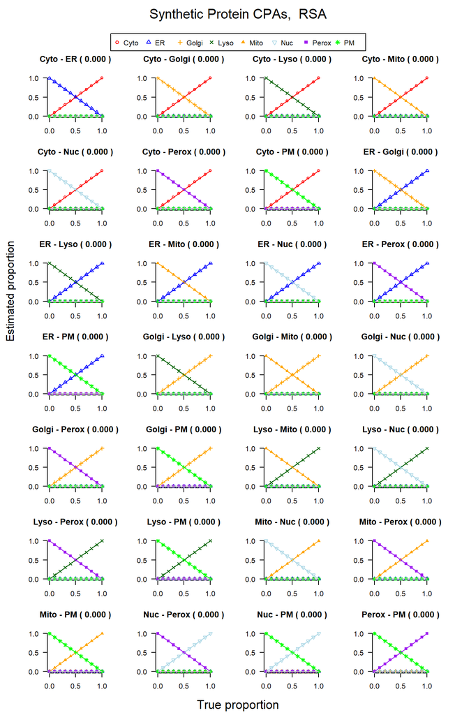

```r
# If the function produces a figure margins error message,
#    open a 7 by 11 window:
# windows(width=7, height=11)

errorAllRSAlinear <- mixturePlotPanel(refLocationProfilesAcup=
                                        refLocationProfilesAcup,
              totProt=totProt, NstartMaterialFractions=6, errorReturn = TRUE,
              fitType="RSA", log2Transf=FALSE)
```

We then can display a table of the errors.

```r
errorAllRSAlinear
```

```
#>     Loc1  Loc2    ErrorArea
#> 1   Cyto    ER 2.972911e-06
#> 2   Cyto Golgi 2.640887e-06
#> 3   Cyto  Lyso 1.036580e-06
#> 4   Cyto  Mito 5.357998e-07
#> 5   Cyto   Nuc 2.295012e-07
#> 6   Cyto Perox 9.606319e-07
#> 7   Cyto    PM 3.061754e-06
#> 8     ER Golgi 6.718970e-07
#> 9     ER  Lyso 7.170405e-06
#> 10    ER  Mito 2.548096e-06
#> 11    ER   Nuc 2.256311e-06
#> 12    ER Perox 2.147279e-06
#> 13    ER    PM 3.350518e-06
#> 14 Golgi  Lyso 2.557810e-06
#> 15 Golgi  Mito 4.378397e-06
#> 16 Golgi   Nuc 2.697804e-06
#> 17 Golgi Perox 7.313692e-06
#> 18 Golgi    PM 2.477578e-06
#> 19  Lyso  Mito 1.896283e-06
#> 20  Lyso   Nuc 4.593296e-07
#> 21  Lyso Perox 1.539383e-07
#> 22  Lyso    PM 5.687592e-06
#> 23  Mito   Nuc 9.261871e-07
#> 24  Mito Perox 5.250864e-07
#> 25  Mito    PM 3.098193e-06
#> 26   Nuc Perox 5.129787e-07
#> 27   Nuc    PM 2.774723e-06
#> 28 Perox    PM 2.610104e-06
```

By summing the third column of `errorAll` (the errors), we obtain a global measure of error.

```r
sum(errorAllRSAlinear[,3])
```

```
#> [1] 6.765227e-05
```

## 4.7 Appendix: CPA plots for all combinations of fit type and functional transformation

Here we present code that may be used to produce the remaining combinations of fit type (RSA, NSA, and Acup) and log transformation (True or False). First is RSA with log-transformed values (linear RSA having been plotted previously in the tutorial).

```
fitType <- "RSA"
log2Transf <- TRUE


errorAllRSAlog2 <- mixturePlotPanel(refLocationProfilesAcup=
              refLocationProfilesAcup, totProt=totProt,
              NstartMaterialFractions=6, errorReturn = TRUE,
              fitType=fitType, log2Transf=log2Transf, eps=0.001)



fitType <- "NSA"
log2Transf <- FALSE

errorAllNSAlinear <- mixturePlotPanel(refLocationProfilesAcup=
                               refLocationProfilesAcup,
              totProt=totProt, NstartMaterialFractions=6,
              errorReturn = TRUE,
              fitType=fitType, log2Transf=log2Transf)

fitType <- "NSA"
log2Transf <- TRUE


errorAllNSAlog2 <- mixturePlotPanel(refLocationProfilesAcup=
                   refLocationProfilesAcup, totProt=totProt,
                   NstartMaterialFractions=6, errorReturn = TRUE,
                   fitType=fitType, log2Transf=log2Transf, eps=0.001)

fitType <- "Acup"
log2Transf <- FALSE


errorAllAcupLinear <- mixturePlotPanel(refLocationProfilesAcup=
              refLocationProfilesAcup, totProt=totProt,
              NstartMaterialFractions=6, errorReturn = TRUE,
              fitType=fitType, log2Transf=log2Transf)

fitType <- "Acup"
log2Transf <- TRUE


errorAllAcupLog2 <- mixturePlotPanel(refLocationProfilesAcup=
              refLocationProfilesAcup, totProt=totProt,
              NstartMaterialFractions=6, errorReturn = TRUE,
              fitType=fitType, log2Transf=log2Transf, eps=0.001)
```

If one needs to prepare the plots as pdf files written to an external directory, first set the working directory, e.g.,

```
setwd("c:\\temp\\myProteinOutput")
```

To output the plots to a pdf file, set things up as follows:

```
pdf(file="CPA assignProts.pdf", width=7, height=11)
```

Then issue the desired calls to `mixturePlotsPanel` as above. All plots requested will be written to the same file. Finally, close out the pdf file to complete writing it out:

```
dev.off()
```

The following code may be used to show that the pairwise and overall errors for all transformations:

```
errorAllRSAlinear
sum(errorAllRSAlinear[,3])

errorAllRSAlog2
sum(errorAllRSAlog2[,3])

errorAllNSAlinear
sum(errorAllNSAlinear[,3])

errorAllNSAlog2
sum(errorAllNSAlog2[,3])

errorAllAcupLinear
sum(errorAllAcupLinear[,3])

errorAllAcupLog2
sum(errorAllAcupLog2[,3])
```

# 5 Tutorial 5: CPA on a simulated five-fraction classical differential centrifugation experiment

## 5.1 Introduction and creation of five-fraction data

In previous tutorials, we investigated CPA analysis using nine TMT-MS2 fractions representing the six differential fractions N, M, L1, L2, P, and S and Nyc1, 2 and 3 from a Nycodenz density gradient separation of the differential fraction L1. In this tutorial, we investigate the performance of CPA using only the five classical differential centrifugation fractions N, M, L, P, and S. We derive the five classical fractions by removing the Nyc fractions and combining L1 and L2 to make the L fraction. We load the `protlocassign` fraction and summarize the full nine-fraction data as follows:

```r
library(protlocassign)
data(protNSA_test)
dim(protNSA_test)
```

```
#> [1] 40 11
```

Next, we convert the data from the original NSA data to the Acup-transformed data, which is the appropriate transformation for combining fractions.

```r
data(totProtAT5)
totProt <- totProtAT5
protAcup_test_data <- AcupFromNSA(protNSA_test[,1:6],
                                       NstartMaterialFractions=6,
                                       totProt=totProt[1:6])
```

We complete the conversion to five-fraction data as follows:

```r
# take the first six fractions:
protAcupSixTemp <- protAcup_test_data[,1:6]
# add L1 and L2 together, and put into L1; then re-name L1 as L
# make L1 the sum of L1 and L2:
protAcupFiveTemp <- within(protAcupSixTemp, L1 <- L1+L2)
# L is now the name of third columm:
names(protAcupFiveTemp)[3] <- "L"
# drop L2 column (column 4)
protAcup_5frac <- protAcupFiveTemp[, -4]
head(round(protAcup_5frac,3))
```

```
#>             N     M     L     P     S
#> ACP2    0.246 0.282 0.031 0.125 0.316
#> AIF1       NA    NA    NA    NA    NA
#> ATP1A1  0.404 0.235 0.026 0.215 0.121
#> B4GALT1 0.262 0.167 0.026 0.545 0.000
#> CANX    0.293 0.187 0.029 0.420 0.072
#> CAT     0.210 0.327 0.055 0.074 0.333
```

We also must create a vector `totProt` with five values, corresponding to N, M, L (=L1+L2), P, S. Here are the original values for total protein in each of the nine fractions:

```r
round(totProt, 3)
```

```
#>      N      M     L1     L2      P      S  Nyc.1  Nyc.2  Nyc.3
#> 46.045 48.956  1.384  1.566 24.046 58.182  0.037  0.068  1.273
```

Now we complete the calculation:

```r
totProtTemp <- totProt
totProtTemp[3] <- totProt[3] + totProt[4]
names(totProtTemp)[3] <- "L"
# remove L2 (component 4) and Nyc values (columns 7, 8, 9)
totProt_5frac <- totProtTemp[c(-4, -7, -8, -9)]
round(totProt_5frac, 3)
```

```
#>      N      M      L      P      S
#> 46.045 48.956  2.950 24.046 58.182
```

## 5.2 Transformations of the five-fraction data and reference profiles

Next we can convert the five-fraction Acup data to NSA and also to RSA:

```r
protNSA_5frac <- NSAfromAcup(Acup=protAcup_5frac, NstartMaterialFractions=5,
                      totProt=totProt_5frac)
head(round(protNSA_5frac,3))
```

```
#>             N     M     L     P     S
#> ACP2    0.165 0.178 0.328 0.161 0.168
#> AIF1       NA    NA    NA    NA    NA
#> ATP1A1  0.263 0.144 0.263 0.268 0.062
#> B4GALT1 0.140 0.084 0.215 0.560 0.000
#> CANX    0.164 0.099 0.255 0.451 0.032
#> CAT     0.118 0.173 0.481 0.080 0.148
```

```r
protRSA_5frac <- RSAfromNSA(NSA=protNSA_5frac,NstartMaterialFractions = 5,
                      totProt = totProt_5frac)
```

We may obtain the three transformations of the reference profiles as follows:

```r
data(markerListJadot)
refLocationProfilesNSA_5frac <- locationProfileSetup(profile=protNSA_5frac,
                            markerList=markerListJadot, numDataCols=5)
refLocationProfilesAcup_5frac <- AcupFromNSA(refLocationProfilesNSA_5frac,
                            NstartMaterialFractions=5, totProt=totProt_5frac)
refLocationProfilesRSA_5frac <- RSAfromNSA(refLocationProfilesNSA_5frac,
                            NstartMaterialFractions=5, totProt=totProt_5frac)

round(refLocationProfilesNSA_5frac, 3)
```

```
#>           N     M     L     P     S
#> Cyto  0.114 0.096 0.109 0.076 0.605
#> ER    0.155 0.113 0.266 0.407 0.058
#> Golgi 0.156 0.103 0.145 0.546 0.051
#> Lyso  0.157 0.188 0.330 0.156 0.169
#> Mito  0.209 0.463 0.183 0.071 0.075
#> Nuc   0.843 0.036 0.030 0.043 0.048
#> Perox 0.126 0.165 0.492 0.093 0.124
#> PM    0.269 0.149 0.235 0.261 0.086
```

```r
round(refLocationProfilesRSA_5frac, 3)
```

```
#>           N     M     L     P     S
#> Cyto  0.434 0.365 0.415 0.290 2.305
#> ER    1.051 0.766 1.799 2.755 0.391
#> Golgi 0.976 0.644 0.910 3.423 0.322
#> Lyso  0.914 1.094 1.919 0.907 0.981
#> Mito  0.967 2.147 0.848 0.327 0.346
#> Nuc   3.413 0.145 0.121 0.176 0.195
#> Perox 0.914 1.202 3.573 0.673 0.902
#> PM    1.534 0.848 1.341 1.486 0.487
```

```r
round(refLocationProfilesAcup_5frac, 3)
```

```
#>           N     M     L     P     S
#> Cyto  0.111 0.099 0.007 0.039 0.744
#> ER    0.269 0.208 0.029 0.368 0.126
#> Golgi 0.249 0.175 0.015 0.457 0.104
#> Lyso  0.234 0.297 0.031 0.121 0.317
#> Mito  0.247 0.583 0.014 0.044 0.112
#> Nuc   0.872 0.039 0.002 0.023 0.063
#> Perox 0.234 0.327 0.059 0.090 0.291
#> PM    0.392 0.230 0.022 0.198 0.157
```

We then generate profile plots:

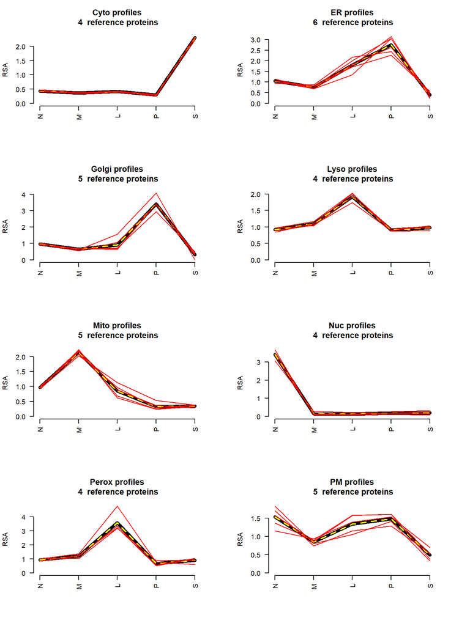

```r
loc.list <- rownames(refLocationProfilesRSA_5frac)
n.loc <- length(loc.list)
par(mfrow=c(4,2))
for (i in 1:n.loc) {
  markerProfilePlot(refLoc=loc.list[i], profile=protRSA_5frac,
                    markerList=markerListJadot,
                    refLocationProfiles=refLocationProfilesRSA_5frac,
                    ylab="RSA")
}
```

## 5.3 Mixture simulations using five-fraction data

One can generate any desired mixture and transformation by adjusting values of i and j.

```r
i=1  #Cyto
j=2  #ER
mixProtiProtj12Acup_5frac <-
    proteinMix(refLocationProfilesAcup_5frac, Loc1=i, Loc2=j)
mixProtiProtj12RSA_5frac <- RSAfromAcup(Acup=mixProtiProtj12Acup_5frac,
                            NstartMaterialFractions=5, totProt=totProt_5frac)
mixProtiProtjCPAfromRSA12_5frac <- fitCPA(profile=mixProtiProtj12RSA_5frac,
                            refLocationProfiles=refLocationProfilesRSA_5frac,
                            numDataCols=5)

i=1  #Cyto
j=3  #Golgi
mixProtiProtj13Acup_5frac <-
    proteinMix(refLocationProfilesAcup_5frac, Loc1=i, Loc2=j)
mixProtiProtj13RSA_5frac <- RSAfromAcup(Acup=mixProtiProtj13Acup_5frac,
                             NstartMaterialFractions=5, totProt=totProt_5frac)
mixProtiProtjCPAfromRSA13_5frac <- fitCPA(profile=mixProtiProtj13RSA_5frac,
                            refLocationProfiles=refLocationProfilesRSA_5frac,
                                 numDataCols=5)
i=1  #Cyto
j=4  #Lyso
mixProtiProtj14Acup_5frac <-
    proteinMix(refLocationProfilesAcup_5frac, Loc1=i, Loc2=j)
mixProtiProtj14RSA_5frac <- RSAfromAcup(Acup=mixProtiProtj14Acup_5frac,
                            NstartMaterialFractions=5, totProt=totProt_5frac)
mixProtiProtjCPAfromRSA14_5frac <- fitCPA(profile=mixProtiProtj14RSA_5frac,
                             refLocationProfiles=refLocationProfilesRSA_5frac,
                             numDataCols=5)

i=1  #Cyto
j=5  #Mito
mixProtiProtj15Acup_5frac <-
   proteinMix(refLocationProfilesAcup_5frac, Loc1=i, Loc2=j)
mixProtiProtj15RSA_5frac <- RSAfromAcup(Acup=mixProtiProtj15Acup_5frac,
                            NstartMaterialFractions=5, totProt=totProt_5frac)
mixProtiProtjCPAfromRSA15_5frac <- fitCPA(profile=mixProtiProtj15RSA_5frac,
                              refLocationProfiles=refLocationProfilesRSA_5frac,
                                numDataCols=5)

i=1  #Cyto
j=6  #Nuc
mixProtiProtj16Acup_5frac <-
    proteinMix(refLocationProfilesAcup_5frac, Loc1=i, Loc2=j)
mixProtiProtj16RSA_5frac <- RSAfromAcup(Acup=mixProtiProtj16Acup_5frac,
                            NstartMaterialFractions=5, totProt=totProt_5frac)
mixProtiProtjCPAfromRSA16_5frac <- fitCPA(profile=mixProtiProtj16RSA_5frac,
                            refLocationProfiles=refLocationProfilesRSA_5frac,
                            numDataCols=5)
i=1  #Cyto
j=7  #Perox
mixProtiProtj17Acup_5frac <-
    proteinMix(refLocationProfilesAcup_5frac, Loc1=i, Loc2=j)
mixProtiProtj17RSA_5frac <- RSAfromAcup(Acup=mixProtiProtj17Acup_5frac,
                            NstartMaterialFractions=5, totProt=totProt_5frac)
mixProtiProtjCPAfromRSA17_5frac <- fitCPA(profile=mixProtiProtj17RSA_5frac,
                            refLocationProfiles=refLocationProfilesRSA_5frac,
                            numDataCols=5)

i=1  #Cyto
j=8  #PM
mixProtiProtj18Acup_5frac <-
    proteinMix(refLocationProfilesAcup_5frac, Loc1=i, Loc2=j)
mixProtiProtj18RSA_5frac <- RSAfromAcup(Acup=mixProtiProtj18Acup_5frac,
                            NstartMaterialFractions=5, totProt=totProt_5frac)
mixProtiProtjCPAfromRSA18_5frac <- fitCPA(profile=mixProtiProtj18RSA_5frac,
                             refLocationProfiles=refLocationProfilesRSA_5frac,
                            numDataCols=5)
```

Now we can plot all simulations for mixing Cyto with each of the other seven compartments. Note that as before, the x-coordinate represents the theoretical distribution based on simulation parameters and the y-coordinate represents the predicted values based on CPA. The assignment errors are shown in parentheses.

We see that CPA performs well except for Cyto-Lyso and Cyto-PM:

```r
par(mfrow=c(2,4))

mixturePlot(mixProtiProtjCPA=mixProtiProtjCPAfromRSA12_5frac,
            NstartMaterialFractions=5, Loc1=1, Loc2=2,
            errorReturn = TRUE, subTitle="RSA")
```

```
#>   Loc1 Loc2   ErrorArea
#> 1 Cyto   ER 0.002285646
```

```r
mixturePlot(mixProtiProtjCPA=mixProtiProtjCPAfromRSA13_5frac,
            NstartMaterialFractions=5, Loc1=1, Loc2=3,
            errorReturn = TRUE, subTitle="RSA")
```

```
#>   Loc1  Loc2    ErrorArea
#> 1 Cyto Golgi 1.750457e-06
```

```r
mixturePlot(mixProtiProtjCPA=mixProtiProtjCPAfromRSA14_5frac,
            NstartMaterialFractions=5, Loc1=1, Loc2=4,
            errorReturn = TRUE, subTitle="RSA")
```

```
#>   Loc1 Loc2 ErrorArea
#> 1 Cyto Lyso 0.8891365
```

```r
mixturePlot(mixProtiProtjCPA=mixProtiProtjCPAfromRSA15_5frac,
            NstartMaterialFractions=5, Loc1=1, Loc2=5,
            errorReturn = TRUE, subTitle="RSA")
```

```
#>   Loc1 Loc2    ErrorArea
#> 1 Cyto Mito 5.347556e-07
```

```r
mixturePlot(mixProtiProtjCPA=mixProtiProtjCPAfromRSA16_5frac,
            NstartMaterialFractions=5, Loc1=1, Loc2=6,
            errorReturn = TRUE, subTitle="RSA")
```

```
#>   Loc1 Loc2    ErrorArea
#> 1 Cyto  Nuc 4.479449e-07
```

```r
mixturePlot(mixProtiProtjCPA=mixProtiProtjCPAfromRSA17_5frac,
            NstartMaterialFractions=5, Loc1=1, Loc2=7,
            errorReturn = TRUE, subTitle="RSA")
```

```
#>   Loc1  Loc2   ErrorArea
#> 1 Cyto Perox 2.57165e-06
```

```
#>   Loc1 Loc2 ErrorArea
#> 1 Cyto   PM 0.8673415
```

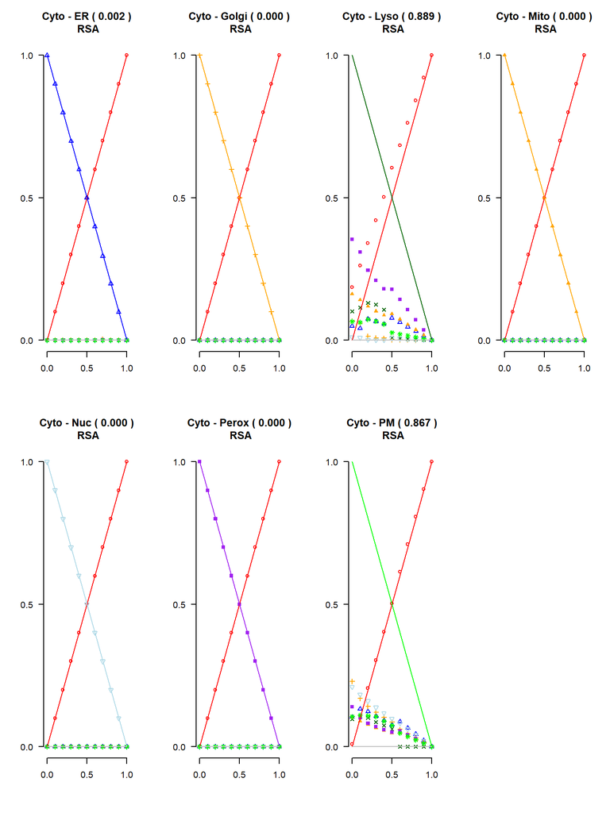

```r
mixturePlot(mixProtiProtjCPA=mixProtiProtjCPAfromRSA18_5frac,
            NstartMaterialFractions=5, Loc1=1, Loc2=8,
            errorReturn = TRUE, subTitle="RSA")
```

```
#>         [,1]    [,2]    [,3]
#> [1,] 12.9735 14.1529 12.8181
#> [2,]  6.5678  5.6251  6.2863
```

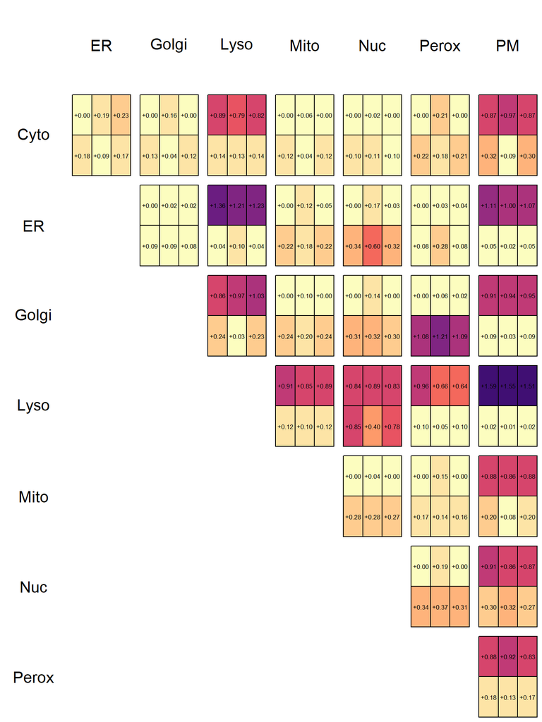

```r
data(errorList5)
par(mfrow=c(1,1))
errorMatAll_5 <- mixtureHeatMap(Acup=refLocationProfilesAcup_5frac,
                        totProt=totProt_5frac, NstartMaterialFractions=5,
                        errorListIn=errorList5)
round(errorMatAll_5, digits=4)
```

We can also either print out overall errors (i.e., sum of all errors for each combination of data transformation method), or, alternatively, generate a heatmap of the overall errors.

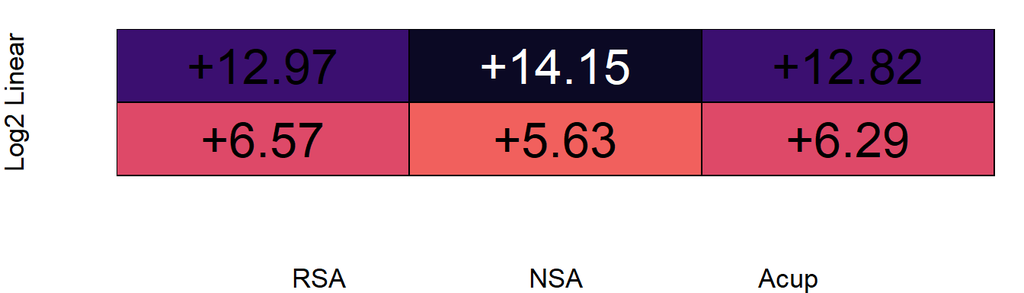

```r
op <- par(mar=c(4,4,1,1))  # save default parameters in variable op

col <- rev(viridis::magma(16))
library(plot.matrix)
plot(errorMatAll_5, col=col, breaks=seq(0, 15, 1), key=NULL, main="",
     axis.col=NULL, axis.row=NULL,
     xlab="RSA                        NSA                       Acup",
     ylab="Log2 Linear", digits=2, cex=2, cex.lab=1.1)
par(op) # restore default parameters
```

## 5.4 Restricted constrained proportional assignment

From the examples above, our modeling shows that `fitCPA` does not report the correct assignment for some of the simulated binary mixtures from a five-fraction differential centrifugation experiment. To investigate this further, we have conducted modeling where we restrict the CPA algorithm to only assign weights to specified subsets of compartments.  
In the following code, we examine the effect of restricting CPA to fit a simulated protein with a 50:50 distribution between Cyto and Lyso. We have already created this earlier in this tutorial as the sixth entry in the data frame `mixProtiProtj14RSA` and create a new one-row data frame that only contains this simulated protein.

```r
data.frame(rownames(mixProtiProtj14RSA_5frac))
```

```
#>    rownames.mixProtiProtj14RSA_5frac.
#> 1                       0_Cyto:1_Lyso
#> 2                   0.1_Cyto:0.9_Lyso
#> 3                   0.2_Cyto:0.8_Lyso
#> 4                   0.3_Cyto:0.7_Lyso
#> 5                   0.4_Cyto:0.6_Lyso
#> 6                   0.5_Cyto:0.5_Lyso
#> 7                   0.6_Cyto:0.4_Lyso
#> 8                   0.7_Cyto:0.3_Lyso
#> 9                   0.8_Cyto:0.2_Lyso
#> 10                  0.9_Cyto:0.1_Lyso
#> 11                      1_Cyto:0_Lyso
```

```r
mixCyto50Lyso50RSA_5frac <- mixProtiProtj14RSA_5frac[6,]
```

In our first example, we force the algorithm to only assign positive weights to Cyto and Lyso, holding the remaining weights fixed at zero.  
We do this using the `fitCPA` function where the optional parameter `ind.vary` specifies the row numbers for the compartments whose proportions are allowed to vary (Cyto=1, Lyso=4) with the remaining compartment proportions fixed at zero. The option `minVal=TRUE` causes the value of the sum of squares goodness of fit (`value`) to be printed. From the output we see that the CPA routine with these constraints correctly reports the distribution of the simulated protein.

```r
mixCyto50Lyso50CPAfromRSAforced <- fitCPA(profile= mixCyto50Lyso50RSA_5frac,
                            refLocationProfiles=refLocationProfilesRSA_5frac,
                            numDataCols=5, ind.vary=c(1,4), minVal=TRUE)
round(mixCyto50Lyso50CPAfromRSAforced, digits=4)
```

```
#>                   Cyto ER Golgi Lyso Mito Nuc Perox PM value
#> 0.5_Cyto:0.5_Lyso  0.5  0     0  0.5    0   0     0  0     0
```

As a second example, we allow positive weights to only two of the eight compartments at a time as described above, cycling through all possible pairs of compartments. Here we introduce a new function, `fCPAsubsets`, that automates this procedure, with an argument `nCPAcomparts` that specifies the number of compartments allowed to vary in each cycle.  
Note that when we specify `nCPAcomparts=2` for eight compartments, there are 8 choose 2 = 28 possible pairs. The output is in a data frame that contains each of the assignments and goodness of fit values, sorted by the parameter `value`. Here, the top CPA assignment has a goodness of fit value markedly better than the others and gives the correct assignment between Cyto and Lyso.

```r
mixCyto50Lyso50CPAfromRSApairs <-
                       fCPAsubsets(profile= mixCyto50Lyso50RSA_5frac,
                       refLocationProfiles=refLocationProfilesRSA_5frac,
                       numDataCols=5,nCPAcomparts=2)
round(mixCyto50Lyso50CPAfromRSApairs, digits=4)
```

```
#>              Cyto     ER  Golgi   Lyso   Mito    Nuc  Perox     PM  value
#> CytoLyso   0.5000 0.0000 0.0000 0.5000 0.0000 0.0000 0.0000 0.0000 0.0000
#> CytoPerox  0.7049 0.0000 0.0000 0.0000 0.0000 0.0000 0.2951 0.0000 0.1555
#> CytoPM     0.6150 0.0000 0.0000 0.0000 0.0000 0.0000 0.0000 0.3850 0.2463
#> CytoER     0.7243 0.2757 0.0000 0.0000 0.0000 0.0000 0.0000 0.0000 0.3622
#> CytoMito   0.6780 0.0000 0.0000 0.0000 0.3220 0.0000 0.0000 0.0000 0.5124
#> CytoGolgi  0.7993 0.0000 0.2007 0.0000 0.0000 0.0000 0.0000 0.0000 0.7102
#> CytoNuc    0.8683 0.0000 0.0000 0.0000 0.0000 0.1317 0.0000 0.0000 1.0552
#> LysoNuc    0.0000 0.0000 0.0000 0.9303 0.0000 0.0697 0.0000 0.0000 1.2327
#> LysoMito   0.0000 0.0000 0.0000 0.9445 0.0555 0.0000 0.0000 0.0000 1.2795
#> ERLyso     0.0000 0.0000 0.0000 1.0000 0.0000 0.0000 0.0000 0.0000 1.2887
#> GolgiLyso  0.0000 0.0000 0.0000 1.0000 0.0000 0.0000 0.0000 0.0000 1.2887
#> LysoPerox  0.0000 0.0000 0.0000 1.0000 0.0000 0.0000 0.0000 0.0000 1.2887
#> LysoPM     0.0000 0.0000 0.0000 1.0000 0.0000 0.0000 0.0000 0.0000 1.2887
#> MitoPM     0.0000 0.0000 0.0000 0.0000 0.3551 0.0000 0.0000 0.6449 2.4515
#> PeroxPM    0.0000 0.0000 0.0000 0.0000 0.0000 0.0000 0.2062 0.7938 2.6382
#> MitoPerox  0.0000 0.0000 0.0000 0.0000 0.6526 0.0000 0.3474 0.0000 2.8979
#> ERPM       0.0000 0.0000 0.0000 0.0000 0.0000 0.0000 0.0000 1.0000 2.9069
#> GolgiPM    0.0000 0.0000 0.0000 0.0000 0.0000 0.0000 0.0000 1.0000 2.9069
#> NucPM      0.0000 0.0000 0.0000 0.0000 0.0000 0.0000 0.0000 1.0000 2.9069
#> ERMito     0.0000 0.3391 0.0000 0.0000 0.6609 0.0000 0.0000 0.0000 2.9521
#> GolgiMito  0.0000 0.0000 0.2497 0.0000 0.7503 0.0000 0.0000 0.0000 3.2154
#> NucPerox   0.0000 0.0000 0.0000 0.0000 0.0000 0.3854 0.6146 0.0000 3.6486
#> MitoNuc    0.0000 0.0000 0.0000 0.0000 0.8436 0.1564 0.0000 0.0000 3.6954
#> GolgiPerox 0.0000 0.0000 0.3935 0.0000 0.0000 0.0000 0.6065 0.0000 4.2539
#> ERPerox    0.0000 0.4915 0.0000 0.0000 0.0000 0.0000 0.5085 0.0000 4.7019
#> ERNuc      0.0000 0.6440 0.0000 0.0000 0.0000 0.3560 0.0000 0.0000 4.7977
#> GolgiNuc   0.0000 0.0000 0.5382 0.0000 0.0000 0.4618 0.0000 0.0000 6.1804
#> ERGolgi    0.0000 1.0000 0.0000 0.0000 0.0000 0.0000 0.0000 0.0000 6.7586
```

It is also possible to consider other fixed combinations. For example, `nCPAcomparts=3` would cycle through 8 choose 3 = 56 combinations where three compartment proportions are allowed to vary with the remaining five fixed at zero. As a final example we consider all 2^8 - 1 = 255 possible subsets of compartments and conduct CPA using each of these subsets.  
In the code below, we successively set `nCPAcomparts` equal to 1, 2, 3…, 8 and create a data frame that contains the estimated proportions and goodness of fit parameter values. We then sort by the parameter `value` and observe that many CPA assignments are nearly as good as the top assignment.

```r
mixCyto50Lyso50CPAfromRSAallSubsets<- NULL
for (kk in 1:8) {
   temp  <- fCPAsubsets(profile=mixCyto50Lyso50RSA_5frac,
                              refLocationProfiles=refLocationProfilesRSA_5frac,
                              numDataCols=5, nCPAcomparts=kk)
   mixCyto50Lyso50CPAfromRSAallSubsets <-
                       rbind(mixCyto50Lyso50CPAfromRSAallSubsets, temp)
}
# sort dataframe by the variable “value” by creating an intermediate
#   list of indices "ord_fit".
ord_fit <- order(mixCyto50Lyso50CPAfromRSAallSubsets$value)
mixCyto50Lyso50CPAfromRSAallSubsetsOrd <-
         mixCyto50Lyso50CPAfromRSAallSubsets[ord_fit,]
round(head(mixCyto50Lyso50CPAfromRSAallSubsetsOrd), 3)
```

```
#>                              Cyto ER Golgi  Lyso  Mito   Nuc Perox    PM value
#> CytoLyso                    0.500  0 0.000 0.500 0.000 0.000 0.000 0.000     0
#> CytoGolgiLyso               0.500  0 0.000 0.500 0.000 0.000 0.000 0.000     0
#> CytoGolgiMitoNucPeroxPM     0.602  0 0.053 0.000 0.087 0.003 0.203 0.053     0
#> CytoGolgiLysoMitoNucPeroxPM 0.597  0 0.051 0.022 0.084 0.003 0.194 0.049     0
#> CytoLysoMitoNuc             0.500  0 0.000 0.500 0.000 0.000 0.000 0.000     0
#> CytoLysoMito                0.500  0 0.000 0.500 0.000 0.000 0.000 0.000     0
```

We may plot the goodness of fit statistic `value` and the CPA assignment proportions for Cyto and Lyso versus model number as follows, with the best fitting models first. This plot shows that the goodness of fit statistic is extremely low for a large number of models:

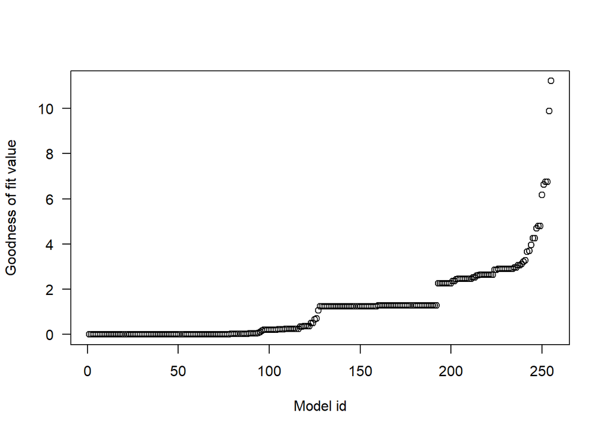

```r
modelVals <- 1:255
par(mfrow=c(1,1))  # reset the plot space
plot(mixCyto50Lyso50CPAfromRSAallSubsetsOrd$value ~ modelVals,
     xlab="Model id", ylab="Goodness of fit value", las=1)
```

In the following plot, we show the CPA estimates for Cyto and Lyso for all models. Even for the best fitting models (with id numbers 1 to about 90), the CPA estimates vary quite a lot.

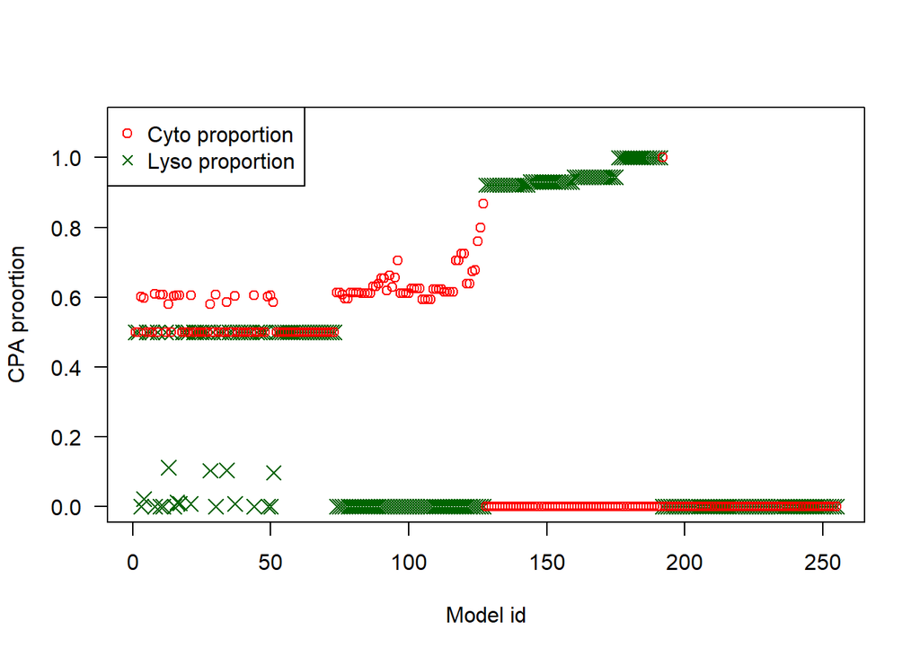

```r
par(mfrow=c(1,1))  # reset the plot space
plot(mixCyto50Lyso50CPAfromRSAallSubsetsOrd$Lyso ~ modelVals, xlab="Model id",
     ylab="CPA proortion", type="n", ylim=c(0, 1.1), las=1)

points(mixCyto50Lyso50CPAfromRSAallSubsetsOrd$Lyso ~ modelVals, pch=4,
       col="darkgreen", cex=1.5)
points(mixCyto50Lyso50CPAfromRSAallSubsetsOrd$Cyto ~ modelVals, pch=1,
       col="red")
legend(x="topleft", legend=c("Cyto proportion", "Lyso proportion"),
       pch=c( 1, 4), col=c("red", "darkgreen"))
```

From this it is clear that the model is over-parameterized with multiple models that fit nearly as well yet give inaccurate CPA estimates. Further study of the properties of estimation methods when multiple models fit equally well is warranted.

## 5.5 Appendix: Plots of CPA assignments of all two-compartment simulated proteins using linear and log RSA, NSA, and Acup data

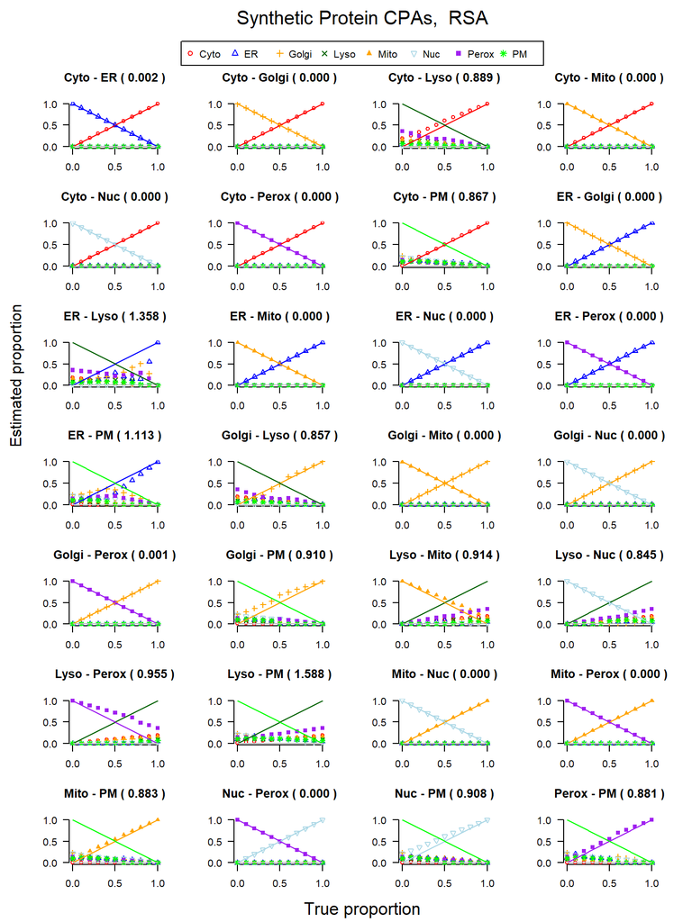

```r
errorAllRSAlinear_5frac <- mixturePlotPanel(refLocationProfilesAcup=
                              refLocationProfilesAcup_5frac,
                              totProt=totProt_5frac, NstartMaterialFractions=5,
                              errorReturn = TRUE,
                              fitType="RSA", log2Transf=FALSE)
```

The mixing simulations indicate that for mixtures involving Lyso or PM, there is a poor fit.

Analysis of pairwise simulations using log2-transformed RSA profiles as well as NSA and Acup profiles (with and without log2 transformations) may be displayed using the code below. Overall, the best results are obtained using log-transformed NSA data. Here, we see that pairwise mixtures involving Lyso and PM are improved compared to the fits with untransformed RSA profiles but many other combinations involving Nuc and ER are worsened.

```
errorAllRSAlog2_5frac <- mixturePlotPanel(refLocationProfilesAcup=
                                    refLocationProfilesAcup_5frac,
                                    totProt=totProt_5frac,
                                    NstartMaterialFractions=5,
                                    errorReturn = TRUE,
                                    fitType="RSA", log2Transf=TRUE)


errorAllNSAlinear_5frac <- mixturePlotPanel(refLocationProfilesAcup=
                                    refLocationProfilesAcup_5frac,
                                    totProt=totProt_5frac,
                                    NstartMaterialFractions=5,
                                    errorReturn = TRUE,
                                    fitType="NSA", log2Transf=FALSE)

errorAllNSAlog2_5frac <- mixturePlotPanel(refLocationProfilesAcup=
                                    refLocationProfilesAcup_5frac,
                                    totProt=totProt_5frac,
                                    NstartMaterialFractions=5,
                                    errorReturn = TRUE,
                                    fitType="NSA", log2Transf=TRUE)

errorAllAcupLinear_5frac <- mixturePlotPanel(refLocationProfilesAcup=
                                    refLocationProfilesAcup_5frac,
                                    totProt=totProt_5frac,
                                    NstartMaterialFractions=5,
                                    errorReturn = TRUE,
                                    fitType="Acup", log2Transf=FALSE)

errorAllAcupLog2_5frac <- mixturePlotPanel(refLocationProfilesAcup=
                                    refLocationProfilesAcup_5frac,
                                    totProt=totProt_5frac,
                                    NstartMaterialFractions=5,
                                    errorReturn = TRUE,
                                    fitType="Acup", log2Transf=TRUE)
```

If desired, these plots of pairwise mixtures may also be saved as pdf files as described in Tutorial 4.

Finally, we present the pairwise and overall errors for log2 RSA (errors for identity RSA are reported above), identity and log2 NSA, nd identity and log2 Acup:

```
errorAllRSAlinear_5frac
sum(errorAllRSAlinear_5frac[,3])

errorAllRSAlog2_5frac
sum(errorAllRSAlog2_5frac[,3])

errorAllNSAlinear_5frac
sum(errorAllNSAlinear_5frac[,3])

errorAllNSAlog2_5frac
sum(errorAllNSAlog2_5frac[,3])

errorAllAcupLinear_5frac
sum(errorAllAcupLinear_5frac[,3])

errorAllAcupLog2_5frac
sum(errorAllAcupLog2_5frac[,3])
```

These can also be saved as tables as described in Tutorial 4.

# 6 Tutorial 6: Working with spectral-level data

This package contains functions to identify outlier spectra and peptides and then to compute weighted averages of the spectral profiles to produce a single profile for each protein. If not already done, install the necessary packages as described in Tutorial 1.

The following procedures require that you first attach these libraries:

```r
library(outliers)
library(lme4)
```

These libraries include the `lme4` package, which implements a set of routines for working with nested data. In this case, this specifically applies to the nesting of spectra within peptides and peptides within proteins. The `outliers` package implements a score-based outlier detection routine, which is one option we provide.

As always, the package `protlocassign` is required:

```r
library(protlocassign)
```

## 6.1 Spectral-level data file structure

In this section we describe how to access the spectral-level data from the AT5-TMT2 experiment described in Tannous et al. 2020. The instructions here also apply to reading in another data set of interest.

Details of how data are pre-processed for input into the protlocassign package may be found in the `protlocassignDataDescription.md` file in the `\inst` subdirectory of the R package. We note that many of these pre-processing steps could, as an alternative, be carried out within R using the `MSnSet` facilities also used by the `pRoloc` package. An advantage of this approach is that these packages provide a natural way to store metadata such as protein markers and their localization as well including built-in validity checks and visualization tools. See the references by L Gatto, LM Breckels, KS Lilley and colleagues for details.

The data file must have the following structure. For each spectrum, the first and second columns must be a protein and peptide identifier, the latter of which also contains the protein identifier in the first part of the field. The next columns can contain ancillary information (e.g., a unique spectral identifier, the position of a peptide within a protein, etc) followed by NSA profiles. Finally, the last two columns, `protID` and `pepID`, contain unique labels for each protein and peptide respectively. We have included an embedded spectral data set, `spectraNSA_test`, that corresponds to `protNSA_test`.

```r
data(spectraNSA_test)
str(spectraNSA_test, strict.width="cut", width=65)
```

```
#> 'data.frame':    6696 obs. of  16 variables:
#>  $ prot                          : chr  "ACP2" "ACP2" "ACP2" ""..
#>  $ peptide                       : chr  "ACP2::CPLQDFLR" "ACP2"..
#>  $ SpectrumID                    : chr  "TGR_03069MS2_[Node_02"..
#>  $ PeptidesStartPositionInProtein: int  349 349 349 54 54 54 54..
#>  $ modifications                 : chr  "57.02147@C1,229.16293"..
#>  $ N                             : num  0.0273 0.0582 0.038 0.0..
#>  $ M                             : num  0.0311 0.1115 0.0339 0...
#>  $ L1                            : num  0.1291 0.1283 0.1078 0...
#>  $ L2                            : num  0.0759 0.0926 0.0937 0...
#>  $ P                             : num  0.0157 0.0273 0.0519 0...
#>  $ S                             : num  0.0138 0.0186 0.0332 0...
#>  $ Nyc1                          : num  0.1307 0.1126 0.128 0.1..
#>  $ Nyc2                          : num  0.515 0.38 0.447 0.476 ..
#>  $ Nyc3                          : num  0.0616 0.0707 0.0665 0...
#>  $ protId                        : int  1 1 1 1 1 1 1 1 1 1 ...
#>  $ pepId                         : int  1 1 1 2 2 2 2 3 3 3 ...
```

We can display the ancillary text information and the NSA profiles with numeric identifiers separately. Note that the row names are derived from the original full spectral data set (see below).

```r
head(spectraNSA_test[,1:5])
```

```
#>      prot        peptide                       SpectrumID PeptidesStartPositionInProtein              modifications
#> 4843 ACP2 ACP2::CPLQDFLR TGR_03069MS2_[Node_02].mgf_27440                            349  57.02147@C1,229.16293@C1,
#> 4844 ACP2 ACP2::CPLQDFLR TGR_03069MS2_[Node_02].mgf_27948                            349  57.02147@C1,229.16293@C1,
#> 4845 ACP2 ACP2::CPLQDFLR TGR_03073MS2_[Node_02].mgf_26753                            349  57.02147@C1,229.16293@C1,
#> 4846 ACP2  ACP2::DPYQEEK  TGR_03032MS2_[Node_02].mgf_9445                             54 229.16293@K7,229.16293@D1,
#> 4847 ACP2  ACP2::DPYQEEK  TGR_03034MS2_[Node_02].mgf_9321                             54 229.16293@K7,229.16293@D1,
#> 4848 ACP2  ACP2::DPYQEEK  TGR_03044MS2_[Node_02].mgf_9135                             54 229.16293@K7,229.16293@D1,
```

```r
head(round(spectraNSA_test[,-(1:5)], digits=3))
```

```
#>          N     M    L1    L2     P     S  Nyc1  Nyc2  Nyc3 protId pepId
#> 4843 0.027 0.031 0.129 0.076 0.016 0.014 0.131 0.515 0.062      1     1
#> 4844 0.058 0.112 0.128 0.093 0.027 0.019 0.113 0.380 0.071      1     1
#> 4845 0.038 0.034 0.108 0.094 0.052 0.033 0.128 0.447 0.066      1     1
#> 4846 0.038 0.025 0.102 0.079 0.030 0.059 0.132 0.476 0.058      1     2
#> 4847 0.019 0.032 0.070 0.046 0.015 0.036 0.091 0.646 0.044      1     2
#> 4848 0.023 0.032 0.121 0.088 0.027 0.046 0.135 0.470 0.057      1     2
```

In many cases, data will not be in the correct form, but a basic requirement is that the first two columns contain protein and peptide identifiers, the next series of columns contain annotation data, and the final series of columns contains NSA profiles for each spectrum. As an example, we show the embedded file `QuantPSM_test` which contains data in a different format. Here we show the structure of `QuantPSM_test`:

```r
data(QuantPSM_test)
str(QuantPSM_test, strict.width="cut", width=65)
```

```
#> 'data.frame':    6696 obs. of  14 variables:
#>  $ Protein.Gene                  : chr  "'ACP2" "'ACP2" "'ACP2"..
#>  $ PeptideSequence               : chr  "CPLQDFLR" "CPLQDFLR" "..
#>  $ SpectrumID                    : chr  "TGR_03069MS2_[Node_02"..
#>  $ PeptidesStartPositionInProtein: int  349 349 349 54 54 54 54..
#>  $ modifications                 : chr  "57.02147@C1,229.16293"..
#>  $ N                             : num  0.0273 0.0582 0.038 0.0..
#>  $ M                             : num  0.0311 0.1115 0.0339 0...
#>  $ L1                            : num  0.1291 0.1283 0.1078 0...
#>  $ L2                            : num  0.0759 0.0926 0.0937 0...
#>  $ P                             : num  0.0157 0.0273 0.0519 0...
#>  $ S                             : num  0.0138 0.0186 0.0332 0...
#>  $ Nyc1                          : num  0.1307 0.1126 0.128 0.1..
#>  $ Nyc2                          : num  0.515 0.38 0.447 0.476 ..
#>  $ Nyc3                          : num  0.0616 0.0707 0.0665 0...
```

Note that the protein names (which are in column 1) are prepended by a single quote (this prevents Excel from interpreting some protein names as dates). These may be removed by using the sub function to substitute the initial quote (denoted by “^’”) with an empty character (““) as shown here:

```r
QuantPSM_test2 <- QuantPSM_test
QuantPSM_test2[,1] <- sub("^'", "", QuantPSM_test[,1])
```

The function `proteinDataPrep` is available to aid in formatting such a file into the required form. This takes input data, sorts it by the first and second columns (which are renamed prot and peptide, the latter being a concatenation of the protein name and peptide sequence), appends all remaining columns (retaining their names), and generates a unique numerical ID for prot and peptide. We specify numRefCols=5 because that is the number of columns immediately preceding the profile data, and numDataCols=9 because that is the number of fractions in each profile.

```r
spectraNSA_test2 <- proteinDataPrep(QuantPSM_test2, numRefCols=5,
                                  numDataCols=9)
str(spectraNSA_test2, strict.width="cut", width=65)
```

```
#> 'data.frame':    6696 obs. of  16 variables:
#>  $ prot                          : chr  "ACP2" "ACP2" "ACP2" ""..
#>  $ peptide                       : chr  "ACP2::CPLQDFLR" "ACP2"..
#>  $ SpectrumID                    : chr  "TGR_03069MS2_[Node_02"..
#>  $ PeptidesStartPositionInProtein: int  349 349 349 54 54 54 54..
#>  $ modifications                 : chr  "57.02147@C1,229.16293"..
#>  $ N                             : num  0.0273 0.0582 0.038 0.0..
#>  $ M                             : num  0.0311 0.1115 0.0339 0...
#>  $ L1                            : num  0.1291 0.1283 0.1078 0...
#>  $ L2                            : num  0.0759 0.0926 0.0937 0...
#>  $ P                             : num  0.0157 0.0273 0.0519 0...
#>  $ S                             : num  0.0138 0.0186 0.0332 0...
#>  $ Nyc1                          : num  0.1307 0.1126 0.128 0.1..
#>  $ Nyc2                          : num  0.515 0.38 0.447 0.476 ..
#>  $ Nyc3                          : num  0.0616 0.0707 0.0665 0...
#>  $ protId                        : int  1 1 1 1 1 1 1 1 1 1 ...
#>  $ pepId                         : int  1 1 1 2 2 2 2 3 3 3 ...
```

We show that this newly-created data frame is equivalent to `spectraNSA_test`, which is distributed with the `protlocassign` package:

```r
data(spectraNSA_test)
all.equal(spectraNSA_test, spectraNSA_test2)
```

```
#> [1] TRUE
```

If the full Tannous AT5 TMT-MS2 data are desired, they may be downloaded from an external file stored on the MassIVE repository. The required code is as follows:

```
urlQuantPSM <- "https://massive.ucsd.edu/ProteoSAFe/DownloadResultFile?file=f.MSV000083848/updates/2022-02-10_ablatannous_094fb41d/quant/QuantPSM.csv&forceDownload=true"

QuantPSM <- read.csv(urlQuantPSM)
str(QuantPSM, strict.width="cut", width=65)
```

In this file, the protein names (which are in column 1) are prepended by a single quote as they were in the `QuantPSM_test`, and these may be removed as described above.

For the remainder of this tutorial, we use spectraNSA_test and  
we may simplify the name as follows:

```r
data(spectraNSA_test)
spectraNSA <- spectraNSA_test
```

If desired, the full spectral data set (or any other properly formatted spectral data set) could also be renamed `spectraNSA` and used for all subsequent operations.

Note that in some cases, one may want to change the peptide identifier to include additional information other than the actual sequence such as presence of post-translational modifications. In this case, one would create a new variable `PepMod` prior to running `proteinDataPrep`, and then insert that new column after the first column, which contains the protein name.

Note that in `spectraNSA`, the first five columns in the data frame contain information associated with the spectra assignment (protein identifier, peptide identifier, unique spectral identifier, location of peptide in protein, and post-translational/chemical modifications), while the next nine columns contain normalized specific amount data. The final two columns contain numbered lists of distinct proteins and peptides; these two columns are needed by the outlier detection functions described in the next section.

## 6.2 Removal of outliers

The first step is an outlier screen for each protein, which is performed at the spectrum level. For each spectrum, the normalized specific amount for each of the nine fractions is first log2 transformed via $y=log2(c+\epsilon)$ , where $\epsilon$ is an estimate of the background intensity in the abundance estimate $c$. A bacterial standard protein not found in mammalian cells was added to all fractions except one and we estimated $\epsilon$ as the median NSA value attributed to this protein in the fraction that lacks it. For the TMT-MS2 experiment we found $\epsilon = 0.029885$. The package provides a choice of two different outlier rejection methods that can be invoked to process the data. When all spectra assigned to a given protein are considered together, the “boxplot” method rejects any value that exceeds a specified multiple of the interquartile range below the first or above the third quartile. This method was used in Tannous et al. (2020) using three times the interquartile range, which we invoke here by specifying `outlierMeth="boxplot"` and `range=3`. The “scores” method used in Jadot et al (2017) calculates normal scores (differences between each value and the mean of those values, divided by their standard deviation) and rejects values in the tails of a standard normal distribution for a specified percentile, such as 0.99. It may be invoked by specifying `outlierMeth="scores"` and `proba=0.99`. Note that the outlier rejection procedure is conducted on each fraction, and the number of outliers for each spectrum are reported in the variable `outlier.num.spectra`, which can range from zero (no outliers) to the number of fractions (in this case 9). This process is repeated for every peptide from every protein. We reject any spectrum where `outlier.num.spectra > 0`.

We first process the data to identify outliers when grouping spectra to peptides using the function `outlierFind` and specifying that the outlier level is “peptide”, meaning that profiles with outlier spectra within peptides (accepting all peptides unless they are composed entirely of spectra with outliers) will be flagged. The arguments `numRefCols = 5` and `numDataCols = 9` are used to identify position of the nine-element profile in the data frame. The argument `randomError=TRUE` (which is the default) specifies that a small random number (uniform distribution ranging from zero to `eps`) will be added to profile elements that take the value zero. This addresses a problem that arises when there are a large number of zero-valued elements, i.e., both the first and third quartile, in which case the interquartile range will be zero. Without adding these random small amounts, too many “outliers” would be detected. We specify a random number seed `setSeed` so that the results are exactly reproducible. (The `setSeed` parameter is ignored if cpus=1; in that case, use the `set.seed` function if reproducibility is required.) Note that routines to identify outliers with our example data set will take several minutes to complete. When the option `cpus` is set to 2 or greater the function uses the `BiocParallel` library from Bioconductor to carry out parallel processing. If `cpus=1` then no parallel processing is done. The following code will install the package if it is not already present:

```
if (!require("BiocManager", quietly = TRUE))
    install.packages("BiocManager")
if (!require("BiocParallel", quietly = TRUE))
    BiocManager::install("BiocParallel")
```

We now set parameters for `BiocParallel` to use the “SnowParam” multiprocessor facility with two processors. We also set a random number seed for the random number generator:

```r
eps <- 0.029885209
library(BiocParallel)
snowParam <- SnowParam(workers = 2, RNGseed=1423)
register(snowParam, default=FALSE)
```

Now we call the `outlierFind` procedure. We select a value of `cpus` that is larger than one to specify multiprocessing. (If desired, one may set `cpus=1` to instead switch to using a single processor.)

```r
flagSpectraBox <- outlierFind(protClass=spectraNSA,
              outlierLevel="peptide", numRefCols=5, numDataCols=9,
              outlierMeth="boxplot", range=3, eps=eps,
              randomError=TRUE, cpus=2)
```

Alternatively, we can specify using the “scores” method as follows. Note that the argument “range” is only used when `outlierMeth="boxplot"`, and ignored otherwise. Similarly, the “proba” argument is only used when `outlierMeth="scores"`

```r
snowParam <- SnowParam(workers = 2, RNGseed=1423)
register(snowParam, default=FALSE)
flagSpectraScore <- outlierFind(protClass=spectraNSA,
                outlierLevel="peptide", numRefCols=5, numDataCols=9,
                outlierMeth="scores", proba=0.99,
                eps=eps, randomError=TRUE, cpus=4)
```

We then examine the output files from the boxplot and scores methods:

```r
str(flagSpectraBox, strict.width="cut", width=65)
```

```
#> 'data.frame':    6696 obs. of  17 variables:
#>  $ prot                          : chr  "ACP2" "ACP2" "ACP2" ""..
#>  $ peptide                       : chr  "ACP2::CPLQDFLR" "ACP2"..
#>  $ SpectrumID                    : chr  "TGR_03069MS2_[Node_02"..
#>  $ PeptidesStartPositionInProtein: int  349 349 349 54 54 54 54..
#>  $ modifications                 : chr  "57.02147@C1,229.16293"..
#>  $ outlier.num.spectra           : num  0 0 0 0 0 0 0 0 0 0 ...
#>  $ N                             : num  0.0273 0.0582 0.038 0.0..
#>  $ M                             : num  0.0311 0.1115 0.0339 0...
#>  $ L1                            : num  0.1291 0.1283 0.1078 0...
#>  $ L2                            : num  0.0759 0.0926 0.0937 0...
#>  $ P                             : num  0.0157 0.0273 0.0519 0...
#>  $ S                             : num  0.0138 0.0186 0.0332 0...
#>  $ Nyc1                          : num  0.1307 0.1126 0.128 0.1..
#>  $ Nyc2                          : num  0.515 0.38 0.447 0.476 ..
#>  $ Nyc3                          : num  0.0616 0.0707 0.0665 0...
#>  $ protId                        : int  1 1 1 1 1 1 1 1 1 1 ...
#>  $ pepId                         : int  1 1 1 2 2 2 2 3 3 3 ...
```

```r
str(flagSpectraScore, strict.width="cut", width=65)
```

```
#> 'data.frame':    6696 obs. of  17 variables:
#>  $ prot                          : chr  "ACP2" "ACP2" "ACP2" ""..
#>  $ peptide                       : chr  "ACP2::CPLQDFLR" "ACP2"..
#>  $ SpectrumID                    : chr  "TGR_03069MS2_[Node_02"..
#>  $ PeptidesStartPositionInProtein: int  349 349 349 54 54 54 54..
#>  $ modifications                 : chr  "57.02147@C1,229.16293"..
#>  $ outlier.num.spectra           : num  0 0 0 0 0 0 0 0 0 0 ...
#>  $ N                             : num  0.0273 0.0582 0.038 0.0..
#>  $ M                             : num  0.0311 0.1115 0.0339 0...
#>  $ L1                            : num  0.1291 0.1283 0.1078 0...
#>  $ L2                            : num  0.0759 0.0926 0.0937 0...
#>  $ P                             : num  0.0157 0.0273 0.0519 0...
#>  $ S                             : num  0.0138 0.0186 0.0332 0...
#>  $ Nyc1                          : num  0.1307 0.1126 0.128 0.1..
#>  $ Nyc2                          : num  0.515 0.38 0.447 0.476 ..
#>  $ Nyc3                          : num  0.0616 0.0707 0.0665 0...
#>  $ protId                        : int  1 1 1 1 1 1 1 1 1 1 ...
#>  $ pepId                         : int  1 1 1 2 2 2 2 3 3 3 ...
```

We can determine the total number of spectra as well as the number of acceptable (e.g. non-outlier) and outlier spectra for both methods using the following statements:

```r
length(flagSpectraBox$outlier.num.spectra)    # total number of spectra
```

```
#> [1] 6696
```

```r
sum(flagSpectraBox$outlier.num.spectra == 0)  # number of acceptable spectra
```

```
#> [1] 6254
```

```r
sum(flagSpectraBox$outlier.num.spectra != 0)  # number of outlier spectra
```

```
#> [1] 442
```

Similarly, we can determine the total number of spectra and the number of acceptable spectra for the scores method using the following statements:

```r
length(flagSpectraScore$outlier.num.spectra)    # total number of spectra
```

```
#> [1] 6696
```

```r
sum(flagSpectraScore$outlier.num.spectra == 0)  # number of acceptable spectra
```

```
#> [1] 6108
```

```r
sum(flagSpectraScore$outlier.num.spectra != 0)  # number of outlier spectra
```

```
#> [1] 588
```

Note that in both examples shown above, the `randomError` argument was used (`randomError=TRUE`). The reason for invoking this argument is illustrated in the two examples below where we set the argument to `False` or `True` when we use the boxplot method with a very large range (`range=110`) where we intuitively would expect that there would be very few outliers. However, if we use the `randomError=FALSE` argument we find that there are 2 outliers:

```r
flagSpectraBoxRange110ranErrF <- outlierFind(protClass=spectraNSA,
              outlierLevel="peptide", numRefCols=5, numDataCols=9,
              outlierMeth="boxplot", range=110, eps=eps,
              randomError=FALSE, cpus=4)
sum(flagSpectraBoxRange110ranErrF$outlier.num.spectra != 0)
```

```
#> [1] 2
```

We have identified 2 outliers because, as discussed above, there are some peptides with enough 0 values that the interquartile range is 0. We can correct this by specifying `randomError=TRUE`, which reduces the number of outliers. Note that in the example below there are no outliers. With repeated runs of `outlierFind`, unless the same random number seed is set, the random error will change, which will result in slightly varying outcomes.

```r
snowParam <- SnowParam(workers = 2, RNGseed=652908)
register(snowParam, default=FALSE)
flagSpectraBoxRange110ranErrT <- outlierFind(protClass=spectraNSA,
              outlierLevel="peptide", numRefCols=5, numDataCols=9,
              outlierMeth="boxplot", range=110, eps=eps,
              randomError=TRUE, cpus=2)
sum(flagSpectraBoxRange110ranErrT$outlier.num.spectra != 0)
```

```
#> [1] 0
```

The procedure described is useful in eliminating outlying spectra for estimates of peptide profiles. The next step is to create mean profiles for each peptide, and also to identify outlying peptide profiles.

## 6.3 Computing means for each protein-peptide combination

The function `profileSummarize` with option `GroupBy="peptideId"` computes the mean profile of each peptide, eliminating spectra that have been identified as outliers. The input data, `flagSpectraBox` contains six reference columns (see above), specified by `numRefCols=6`. A portion of these can be kept and carried over to the output file, but note that since the function here is producing a profile for each peptide from its relevant component spectra, some of the reference columns from the input data may not be appropriate. Here, the argument `refColsKeep=c(1,2,4)` causes the function to retain reference columns 1, 2, and 4, which correspond to “prot”, “peptide”, and “PeptidesStartPositionInProtein”. If a field is kept which has multiple values across all spectra that contribute to a given peptide, only the single value from the first of these spectra is used.  
The argument `refColsKeep` is only used in the case where `GroupBy` is set to `peptideId`, and if not specified, the default is to keep only the first two columns. We use the argument `outlierExclude="spectra"` to indicate that, when computing mean profiles, we exclude spectra that are identified as outliers within their respective peptides. Note that in the output, `Nspectra` reports the number of spectra (in this case, all non-outlier spectra) used to calculate the mean peptide profile.

```r
pepProfiles <- profileSummarize(protsCombineCnew=flagSpectraBox,
                numRefCols=6, numDataCols=9, refColsKeep=c(1,2,4),eps=eps,
                GroupBy="peptideId", outlierExclude="spectra", cpus=4)
str(pepProfiles, strict.width="cut", width=65)
```

```
#> 'data.frame':    944 obs. of  16 variables:
#>  $ prot                          : chr  "ACP2" "ACP2" "ACP2" ""..
#>  $ peptide                       : chr  "ACP2::CPLQDFLR" "ACP2"..
#>  $ PeptidesStartPositionInProtein: int  349 54 71 357 406 267 9..
#>  $ N                             : num  0.0407 0.0439 0.0642 0...
#>  $ M                             : num  0.0528 0.0413 0.0659 0...
#>  $ L1                            : num  0.1232 0.1074 0.0964 0...
#>  $ L2                            : num  0.0884 0.0784 0.1029 0...
#>  $ P                             : num  0.0303 0.0371 0.0677 0...
#>  $ S                             : num  0.0216 0.0559 0.0724 0...
#>  $ Nyc1                          : num  0.125 0.119 0.138 0.13 ..
#>  $ Nyc2                          : num  0.451 0.458 0.325 0.45 ..
#>  $ Nyc3                          : num  0.0671 0.0589 0.0677 0...
#>  $ Nspectra                      : num  3 4 14 4 6 1 7 2 2 1 ...
#>  $ Npep                          : num  1 1 1 1 1 1 1 1 1 1 ...
#>  $ protId                        : num  1 1 1 1 1 1 1 1 2 2 ...
#>  $ pepId                         : num  1 2 3 4 5 6 7 8 9 10 ...
```

Next, using this output, we use the function `outlierFind` to identify peptide outliers within proteins. We do this by specifying `outlierLevel` to be “protein” and do not need to specify `outlierMeth="boxplot"` or the values `range=3` and `randomError=TRUE` as these are default arguments. Note that in this procedure, all peptides in a given protein are weighted equally, regardless of how many non-outlier spectra are used to determine the average peptide profile.

```r
snowParam <- SnowParam(workers = 2, RNGseed=823537)
register(snowParam, default=FALSE)
flagPepsBox <- outlierFind(protClass=pepProfiles,
                    outlierLevel="protein",
                    numRefCols=3, numDataCols=9, eps=eps, cpus=2)
str(flagPepsBox, strict.width="cut", width=65)
```

```
#> 'data.frame':    944 obs. of  17 variables:
#>  $ prot                          : chr  "ACP2" "ACP2" "ACP2" ""..
#>  $ peptide                       : chr  "ACP2::CPLQDFLR" "ACP2"..
#>  $ PeptidesStartPositionInProtein: int  349 54 71 357 406 267 9..
#>  $ outlier.num.peptides          : num  0 0 0 0 0 0 0 0 1 1 ...
#>  $ N                             : num  0.0407 0.0439 0.0642 0...
#>  $ M                             : num  0.0528 0.0413 0.0659 0...
#>  $ L1                            : num  0.1232 0.1074 0.0964 0...
#>  $ L2                            : num  0.0884 0.0784 0.1029 0...
#>  $ P                             : num  0.0303 0.0371 0.0677 0...
#>  $ S                             : num  0.0216 0.0559 0.0724 0...
#>  $ Nyc1                          : num  0.125 0.119 0.138 0.13 ..
#>  $ Nyc2                          : num  0.451 0.458 0.325 0.45 ..
#>  $ Nyc3                          : num  0.0671 0.0589 0.0677 0...
#>  $ Nspectra                      : num  3 4 14 4 6 1 7 2 2 1 ...
#>  $ Npep                          : num  1 1 1 1 1 1 1 1 1 1 ...
#>  $ protId                        : num  1 1 1 1 1 1 1 1 2 2 ...
#>  $ pepId                         : num  1 2 3 4 5 6 7 8 9 10 ...
```

We determine the total number of peptides and the number of acceptable and outlier peptides using the following statements:

```r
length(flagPepsBox$outlier.num.peptides)
```

```
#> [1] 944
```

```r
sum(flagPepsBox$outlier.num.peptides == 0)
```

```
#> [1] 857
```

```r
sum(flagPepsBox$outlier.num.peptides != 0)
```

```
#> [1] 87
```

We can now merge the indicator of peptide outlier status into the full spectral level file. Here, we create a new data frame, `flagSpectraPeps`, by adding `outlier.num.peptides` (column 4 from `flagPepsBox`) to  
`flagSpectraBox`, merging on pepId (column 17 from `flagPepsBox`).

```r
data.frame(names(flagPepsBox))
```

```
#>                names.flagPepsBox.
#> 1                            prot
#> 2                         peptide
#> 3  PeptidesStartPositionInProtein
#> 4            outlier.num.peptides
#> 5                               N
#> 6                               M
#> 7                              L1
#> 8                              L2
#> 9                               P
#> 10                              S
#> 11                           Nyc1
#> 12                           Nyc2
#> 13                           Nyc3
#> 14                       Nspectra
#> 15                           Npep
#> 16                         protId
#> 17                          pepId
```

```r
flagSpectraPeps <- merge(x=flagSpectraBox,
                        y=flagPepsBox[,c(4,17)], by="pepId")
str(flagSpectraPeps,  strict.width="cut", width=65)
```

```
#> 'data.frame':    6696 obs. of  18 variables:
#>  $ pepId                         : int  1 1 1 2 2 2 2 3 3 3 ...
#>  $ prot                          : chr  "ACP2" "ACP2" "ACP2" ""..
#>  $ peptide                       : chr  "ACP2::CPLQDFLR" "ACP2"..
#>  $ SpectrumID                    : chr  "TGR_03069MS2_[Node_02"..
#>  $ PeptidesStartPositionInProtein: int  349 349 349 54 54 54 54..
#>  $ modifications                 : chr  "57.02147@C1,229.16293"..
#>  $ outlier.num.spectra           : num  0 0 0 0 0 0 0 0 0 0 ...
#>  $ N                             : num  0.0273 0.0582 0.038 0.0..
#>  $ M                             : num  0.0311 0.1115 0.0339 0...
#>  $ L1                            : num  0.1291 0.1283 0.1078 0...
#>  $ L2                            : num  0.0759 0.0926 0.0937 0...
#>  $ P                             : num  0.0157 0.0273 0.0519 0...
#>  $ S                             : num  0.0138 0.0186 0.0332 0...
#>  $ Nyc1                          : num  0.1307 0.1126 0.128 0.1..
#>  $ Nyc2                          : num  0.515 0.38 0.447 0.476 ..
#>  $ Nyc3                          : num  0.0616 0.0707 0.0665 0...
#>  $ protId                        : int  1 1 1 1 1 1 1 1 1 1 ...
#>  $ outlier.num.peptides          : num  0 0 0 0 0 0 0 0 0 0 ...
```

We determine the number of spectra in the full data set and the number of acceptable spectra from acceptable peptides using the following statements:

```r
length(flagSpectraPeps$outlier.num.peptides)
```

```
#> [1] 6696
```

```r
sum({flagSpectraPeps$outlier.num.spectra == 0} &
      {flagSpectraPeps$outlier.num.peptides == 0})
```

```
#> [1] 6047
```

We now calculate the mean profile for each protein, using a random effects linear model where spectra are nested within peptides. In the three examples listed below, we examine cases where we: (1) reject the contribution of any outlying spectra and peptides; (2) reject the contribution of just outlier spectra within peptides; and (3) we do not reject any peptides or spectra. Here, the `outlierExclude` argument overrides the outlier specifications in the `flagSpectraPeps` file. The resulting file contains the protein profile, indicating the number of peptides and spectra used to determine each protein profile using the rules above. The root portion of the name `protNSA` denotes that these values are normalized specific amounts (NSA) for protein profiles.

The `lmer` random effects function within `profileSummarize` will generate error messages for some fractions within some proteins due to numerical singularity issues. To minimize these errors, the function requires two conditions to be met before calling the `lmer` function: There must be at least eight spectra and four peptides, and the ratio of numbers of spectra to peptides must exceed 4. If these conditions are not met the function calculates a standard (non-nested) average of all spectra to obtain a mean profile. Otherwise, the `lmer` random effects model is fitted. In some cases, for a given protein and fraction, the `lmer` routine fails and reports a singularity in the model fit. In these cases, `profileSummarize` automatically re-calculates the profile average using standard (non-nested) averaging. If the option `singularList=TRUE` is specified, the function will list the specific protein and fraction number (which here range from 1 to 9) where the `lmer` routine encountered the singularity. For example, “ACP2” has 41 spectra and 8 peptides. The `lmer` procedure converged for the first eight fractions but failed for the ninth one (Nyc3). The default is `singularList=FALSE`.

```r
snowParam <- SnowParam(workers = 2)
register(snowParam, default=FALSE)
protNSA_1 <-
          profileSummarize(protsCombineCnew=flagSpectraPeps,
          numRefCols=7, numDataCols=9, eps=eps, GroupBy="protId",
          outlierExclude="spectraAndPeptide", cpus=2, singularList=TRUE)
```

```
#> boundary (singular) fit: see help('isSingular')
#> boundary (singular) fit: see help('isSingular')
#> boundary (singular) fit: see help('isSingular')
```

```
#> boundary (singular) fit: see help('isSingular')
#> boundary (singular) fit: see help('isSingular')
#> boundary (singular) fit: see help('isSingular')
#> boundary (singular) fit: see help('isSingular')
#> boundary (singular) fit: see help('isSingular')
#> boundary (singular) fit: see help('isSingular')
```

```r
str(protNSA_1,  strict.width="cut", width=65)
```

```
#> 'data.frame':    40 obs. of  12 variables:
#>  $ prot    : chr  "ACP2" "AIF1" "ATP1A1" "B4GALT1" ...
#>  $ N       : num  0.0483 NA 0.1176 0.0542 0.1026 ...
#>  $ M       : num  0.052 NA 0.0637 0.0326 0.0617 ...
#>  $ L1      : num  0.1041 NA 0.0914 0.0483 0.0871 ...
#>  $ L2      : num  0.0888 NA 0.1392 0.1137 0.223 ...
#>  $ P       : num  0.0469 NA 0.1193 0.2159 0.2816 ...
#>  $ S       : num  4.91e-02 NA 2.81e-02 6.94e-18 1.98e-02 ...
#>  $ Nyc1    : num  0.132 NA 0.1979 0.2298 0.0777 ...
#>  $ Nyc2    : num  0.412 NA 0.183 0.291 0.084 ...
#>  $ Nyc3    : num  0.0669 NA 0.0596 0.0142 0.0625 ...
#>  $ Nspectra: num  41 0 239 2 78 ...
#>  $ Npep    : num  8 0 41 2 14 29 6 62 11 22 ...
```

```r
protNSA_2 <-
          profileSummarize(protsCombineCnew=flagSpectraPeps,
          numRefCols=7, numDataCols=9, eps=eps, GroupBy="protId",
          outlierExclude="spectra", cpus=2)
str(protNSA_2,  strict.width="cut", width=65)
```

```
#> 'data.frame':    40 obs. of  12 variables:
#>  $ prot    : chr  "ACP2" "AIF1" "ATP1A1" "B4GALT1" ...
#>  $ N       : num  0.0483 0.0858 0.1182 0.0542 0.1018 ...
#>  $ M       : num  0.052 0.037 0.064 0.0326 0.063 ...
#>  $ L1      : num  0.1041 0.0746 0.0926 0.0483 0.0882 ...
#>  $ L2      : num  0.0888 0.0763 0.1401 0.1137 0.2211 ...
#>  $ P       : num  0.0469 0.0609 0.1192 0.2159 0.2768 ...
#>  $ S       : num  4.91e-02 1.02e-01 2.82e-02 6.94e-18 2.24e-02 ..
#>  $ Nyc1    : num  0.132 0.3907 0.1977 0.2298 0.0791 ...
#>  $ Nyc2    : num  0.4118 0.1406 0.1798 0.2914 0.0841 ...
#>  $ Nyc3    : num  0.0669 0.0325 0.0602 0.0142 0.0636 ...
#>  $ Nspectra: num  41 10 242 2 80 ...
#>  $ Npep    : num  8 5 43 2 16 30 7 71 12 27 ...
```

```r
protNSA_3 <-
          profileSummarize(protsCombineCnew=flagSpectraPeps,
          numRefCols=7, numDataCols=9, eps=eps, GroupBy="protId",
          outlierExclude="none", cpus=2)
str(protNSA_3,  strict.width="cut", width=65)
```

```
#> 'data.frame':    40 obs. of  12 variables:
#>  $ prot    : chr  "ACP2" "AIF1" "ATP1A1" "B4GALT1" ...
#>  $ N       : num  0.0472 0.0858 0.1197 0.0542 0.1022 ...
#>  $ M       : num  0.0513 0.037 0.0644 0.0326 0.0628 ...
#>  $ L1      : num  0.1052 0.0746 0.094 0.0483 0.0884 ...
#>  $ L2      : num  0.0892 0.0763 0.1393 0.1137 0.2215 ...
#>  $ P       : num  0.0458 0.0609 0.1179 0.2159 0.2735 ...
#>  $ S       : num  4.78e-02 1.02e-01 2.86e-02 6.94e-18 2.28e-02 ..
#>  $ Nyc1    : num  0.1264 0.3907 0.1962 0.2298 0.0785 ...
#>  $ Nyc2    : num  0.4196 0.1406 0.1784 0.2914 0.0855 ...
#>  $ Nyc3    : num  0.0674 0.0325 0.0614 0.0142 0.0649 ...
#>  $ Nspectra: num  42 10 258 2 92 ...
#>  $ Npep    : num  8 5 43 2 16 30 7 71 12 27 ...
```

```r
sum((protNSA_3$Nspectra))
```

```
#> [1] 6696
```

```r
sum((protNSA_2$Nspectra))
```

```
#> [1] 6254
```

```r
sum((protNSA_1$Nspectra))
```

```
#> [1] 6047
```

```r
sum((protNSA_3$Npep))
```

```
#> [1] 944
```

```r
sum((protNSA_2$Npep))
```

```
#> [1] 944
```

```r
sum((protNSA_1$Npep))
```

```
#> [1] 857
```

We can examine the number of proteins with missing profile values (caused by outlier rejection) in each of the three cases by choosing one fraction, e.g., “M”; all other fractions will also be missing.

```r
sum(is.na(protNSA_1$M))
```

```
#> [1] 1
```

```r
sum(is.na(protNSA_2$M))
```

```
#> [1] 0
```

```r
sum(is.na(protNSA_3$M))
```

```
#> [1] 0
```

We see that one is rejected in `protNSA_1`. It is important to note that the outlier rejection process includes a random component, so that repeating the analysis on the embedded data set without specifically setting the seed for the random number generator could potentially result in a different number of proteins with missing profiles.

Taking the first option (rejecting outlier spectra within peptides as well as outlier peptides) as the preferred method, we then create a protein profile data frame in the same format as used in earlier tutorials by moving the protein names from a variable within the data frame to row names.

```r
protNSA_new <- protNSA_1
#copy first field in data frame containing protein names to rownnames field
rownames(protNSA_new) <- protNSA_1[,1]
#delete first internal column containing protein names:
protNSA_new <- protNSA_new[,-1]
```

The data frame `protNSA_new` is essentially identical to the data set `protNSA_test` included in the `protlocassign` package. (The argument `countEQ=TRUE` causes the function to compute the mean error across all profiles, not just among those that differ.)

```r
data(protNSA_test)
all.equal(protNSA_test, protNSA_new, countEQ=TRUE, tolerance=0)
```

```
#>  [1] "Component \"N\": Mean absolute difference: 0.001256695"        "Component \"M\": Mean absolute difference: 0.0004558591"
#>  [3] "Component \"L1\": Mean absolute difference: 0.0006159017"      "Component \"L2\": Mean absolute difference: 0.0006454033"
#>  [5] "Component \"P\": Mean absolute difference: 0.001407908"        "Component \"S\": Mean absolute difference: 0.0007825365"
#>  [7] "Component \"Nyc1\": Mean absolute difference: 0.0008914891"    "Component \"Nyc2\": Mean absolute difference: 0.0008169824"
#>  [9] "Component \"Nyc3\": Mean absolute difference: 0.0006551623"    "Component \"Nspectra\": Mean relative difference: 0.005381202"
#> [11] "Component \"Npep\": Mean relative difference: 0.02005571"
```

## 6.4 Creating a combined protein/peptide profile data frame

In this section, we describe a function `protPepProfile` that creates a data frame with each protein profile followed by the peptide profiles associated with each protein and their outlier status. The function requires two arguments. The first is a data frame of peptide profiles specified by `flagPeps = flagPepsBox`. The second is a data frame of protein profiles specified by `protProfileData = protNSA_1`; this data frame must have `prot` in the first column and the profiles in the following `numDataCols` columns. These two data frames must be in a consistent form and use the same type of profile data (e.g., NSA), as created earlier in this tutorial. We first re-examine the list of column names of `flagPepsBox` to determine that there are four reference columns preceding the nine columns of profile data:

```r
data.frame(names(flagPepsBox))
```

```
#>                names.flagPepsBox.
#> 1                            prot
#> 2                         peptide
#> 3  PeptidesStartPositionInProtein
#> 4            outlier.num.peptides
#> 5                               N
#> 6                               M
#> 7                              L1
#> 8                              L2
#> 9                               P
#> 10                              S
#> 11                           Nyc1
#> 12                           Nyc2
#> 13                           Nyc3
#> 14                       Nspectra
#> 15                           Npep
#> 16                         protId
#> 17                          pepId
```

```r
protPepNSA <- protPepProfile(flagPeps=flagPepsBox,
                                 numRefCols=4, numDataCols=9,
                                 protProfileData=protNSA_1)
str(protPepNSA, strict.width="cut", width=65)
```

```
#> 'data.frame':    984 obs. of  15 variables:
#>  $ prot                          : chr  "ACP2" "ACP2" "ACP2" ""..
#>  $ peptide                       : chr  "ACP2" "ACP2::CPLQDFLR"..
#>  $ PeptidesStartPositionInProtein: int  NA 349 54 71 357 406 26..
#>  $ outlier.num.peptides          : num  NA 0 0 0 0 0 0 0 0 NA ...
#>  $ N                             : num  0.0483 0.0407 0.0439 0...
#>  $ M                             : num  0.052 0.0528 0.0413 0.0..
#>  $ L1                            : num  0.1041 0.1232 0.1074 0...
#>  $ L2                            : num  0.0888 0.0884 0.0784 0...
#>  $ P                             : num  0.0469 0.0303 0.0371 0...
#>  $ S                             : num  0.0491 0.0216 0.0559 0...
#>  $ Nyc1                          : num  0.132 0.125 0.119 0.138..
#>  $ Nyc2                          : num  0.412 0.451 0.458 0.325..
#>  $ Nyc3                          : num  0.0669 0.0671 0.0589 0...
#>  $ Nspectra                      : num  41 3 4 14 4 6 1 7 2 0 ...
#>  $ Npep                          : num  8 1 1 1 1 1 1 1 1 0 ...
```

Finally, for later CPA analysis, we need the data frame to contain a unique row name for each profile, which we obtain from the peptide column.  
Here, for peptides this is a concatenation of the protein name and peptide sequence while for proteins this is the protein name alone.

```r
rownames(protPepNSA) <- protPepNSA$peptide
```

We examine the first few row names here:

```r
head(rownames(protPepNSA))
```

```
#> [1] "ACP2"                 "ACP2::CPLQDFLR"       "ACP2::DPYQEEK"        "ACP2::EGMLQHWELGQALR" "ACP2::LTEPVIPK"       "ACP2::MQAQPPGYHHVADR"
```

We may use `protPepNSA` in carrying out transformations and in calculating CPA estimates with the `fitCPA` function. These calculations, as well as transformations, are discussed in the next section.

## 6.5 RSA transformations

In this section, we shall first calculate RSA transformed profiles for all proteins and peptides, and then compute the CPA for all proteins and peptides in a form ready for export. Then we show how to use it to plot profiles for any protein and its component peptides, with outlier peptides labelled in the plot.

Here we extract the NSA reference profiles from the nine profile columns of `protPepNSA`:

```r
data(totProtAT5)
data(markerListJadot)
refLocationProfilesNSA <- locationProfileSetup(profile=protPepNSA[, 4 + (1:9)],
                          markerList=markerListJadot, numDataCols=9)
round(refLocationProfilesNSA, digits=4)
```

```
#>            N      M     L1     L2      P      S   Nyc1   Nyc2   Nyc3
#> Cyto  0.0751 0.0627 0.0714 0.0707 0.0498 0.3942 0.1230 0.1019 0.0512
#> ER    0.0938 0.0680 0.0973 0.2142 0.2454 0.0348 0.0836 0.0864 0.0765
#> Golgi 0.0860 0.0582 0.0584 0.0921 0.3114 0.0288 0.1692 0.1623 0.0337
#> Lyso  0.0416 0.0501 0.1037 0.0740 0.0411 0.0450 0.1433 0.4373 0.0639
#> Mito  0.1290 0.2888 0.1555 0.0734 0.0431 0.0461 0.0771 0.0673 0.1196
#> Nuc   0.7406 0.0306 0.0150 0.0341 0.0370 0.0405 0.0365 0.0380 0.0275
#> Perox 0.0524 0.0693 0.2822 0.1382 0.0383 0.0521 0.0663 0.0833 0.2177
#> PM    0.1167 0.0640 0.0820 0.1185 0.1127 0.0371 0.2379 0.1791 0.0521
```

Using the `RSAfromNSA` function described previously in Tutorial 3, we calculate the RSA-transformed marker profiles:

```r
refLocationProfilesRSA <- RSAfromNSA(NSA=refLocationProfilesNSA,
                              NstartMaterialFractions=6, totProt=totProtAT5)
round(refLocationProfilesRSA, digits=4)
```

```
#>            N      M     L1     L2      P      S   Nyc1   Nyc2   Nyc3
#> Cyto  0.4383 0.3657 0.4166 0.4129 0.2909 2.3010 0.7179 0.5950 0.2990
#> ER    1.0531 0.7636 1.0926 2.4050 2.7559 0.3912 0.9385 0.9700 0.8589
#> Golgi 0.9569 0.6472 0.6497 1.0243 3.4638 0.3204 1.8824 1.8056 0.3748
#> Lyso  0.9114 1.0957 2.2704 1.6193 0.8999 0.9841 3.1373 9.5708 1.3997
#> Mito  0.9634 2.1567 1.1607 0.5483 0.3218 0.3444 0.5759 0.5023 0.8931
#> Nuc   3.4282 0.1418 0.0694 0.1580 0.1715 0.1877 0.1690 0.1761 0.1272
#> Perox 0.9109 1.2047 4.9031 2.4009 0.6658 0.9058 1.1526 1.4471 3.7830
#> PM    1.5372 0.8437 1.0800 1.5609 1.4845 0.4891 3.1356 2.3598 0.6867
```

We transform the protein/peptide profiles by taking the nine columns containing the profile data from `protPepNSA` and then, using the `RSAfromNSA` function described previously in Tutorial 3, we calculate an intermediate nine-column data frame `protPepRSA_trimmed` of RSA-transformed profiles.

```r
protPepRSA_trimmed <- RSAfromNSA(NSA=protPepNSA[, 4 + (1:9)],
                              NstartMaterialFractions=6, totProt=totProtAT5)
str(protPepRSA_trimmed, strict.width="cut", width=65)
```

```
#> 'data.frame':    984 obs. of  9 variables:
#>  $ N   : num  0.963 1.085 0.935 0.939 0.935 ...
#>  $ M   : num  1.036 1.41 0.879 0.963 1.512 ...
#>  $ L1  : num  2.07 3.29 2.29 1.41 3.08 ...
#>  $ L2  : num  1.77 2.36 1.67 1.51 2.29 ...
#>  $ P   : num  0.935 0.808 0.79 0.991 0.776 ...
#>  $ S   : num  0.98 0.575 1.191 1.059 0.629 ...
#>  $ Nyc1: num  2.63 3.35 2.53 2.02 3.38 ...
#>  $ Nyc2: num  8.21 12.03 9.76 4.76 11.7 ...
#>  $ Nyc3: num  1.33 1.79 1.25 0.99 1.68 ...
```

```r
protPepRSA <- data.frame(protPepNSA[, 1:4], protPepRSA_trimmed,
                         protPepNSA[,14:15] )  # add in the ref columns
str(protPepRSA, strict.width="cut", width=65)
```

```
#> 'data.frame':    984 obs. of  15 variables:
#>  $ prot                          : chr  "ACP2" "ACP2" "ACP2" ""..
#>  $ peptide                       : chr  "ACP2" "ACP2::CPLQDFLR"..
#>  $ PeptidesStartPositionInProtein: int  NA 349 54 71 357 406 26..
#>  $ outlier.num.peptides          : num  NA 0 0 0 0 0 0 0 0 NA ...
#>  $ N                             : num  0.963 1.085 0.935 0.939..
#>  $ M                             : num  1.036 1.41 0.879 0.963 ..
#>  $ L1                            : num  2.07 3.29 2.29 1.41 3.0..
#>  $ L2                            : num  1.77 2.36 1.67 1.51 2.2..
#>  $ P                             : num  0.935 0.808 0.79 0.991 ..
#>  $ S                             : num  0.98 0.575 1.191 1.059 ..
#>  $ Nyc1                          : num  2.63 3.35 2.53 2.02 3.3..
#>  $ Nyc2                          : num  8.21 12.03 9.76 4.76 11..
#>  $ Nyc3                          : num  1.33 1.79 1.25 0.99 1.6..
#>  $ Nspectra                      : num  41 3 4 14 4 6 1 7 2 0 ...
#>  $ Npep                          : num  8 1 1 1 1 1 1 1 1 0 ...
```

## 6.6 Plotting RSA protein and peptide profiles

Next, we identify rows with proteins only, and extract them. The resulting data frame, `protRSA`, parallels the structure of `protNSA`. We also extract the rows with peptides only in the data frame `pepRSA`.

```r
protRSA.ind <- {protPepRSA$prot == protPepRSA$peptide}  # protein indicators
protRSA <- protPepRSA[protRSA.ind,]  # these are the data for proteins only
dim(protRSA)
```

```
#> [1] 40 15
```

```r
pepRSA <- protPepRSA[!protRSA.ind,] # these are the data for peptides only

data.frame(colnames(protRSA))
```

```
#>                 colnames.protRSA.
#> 1                            prot
#> 2                         peptide
#> 3  PeptidesStartPositionInProtein
#> 4            outlier.num.peptides
#> 5                               N
#> 6                               M
#> 7                              L1
#> 8                              L2
#> 9                               P
#> 10                              S
#> 11                           Nyc1
#> 12                           Nyc2
#> 13                           Nyc3
#> 14                       Nspectra
#> 15                           Npep
```

Now we calculate the CPA on proteins only, using RSA-transformed profiles:

```r
protCPAfromRSA <-  fitCPA(profile=protRSA[, 4+1:9],
                      refLocationProfiles=refLocationProfilesRSA,
                      numDataCols=9)
str(protCPAfromRSA, strict.width="cut", width=65)
```

```
#> 'data.frame':    40 obs. of  8 variables:
#>  $ Cyto : num  0.0333 NA 0 0 0 ...
#>  $ ER   : num  0.0841 NA 0.1738 0 0.9536 ...
#>  $ Golgi: num  0 NA 0 0.5755 0.0464 ...
#>  $ Lyso : num  0.84 NA 0.055 0.424 0 ...
#>  $ Mito : num  0 NA 0 0 0 ...
#>  $ Nuc  : num  0.0221 NA 0.0191 0 0 ...
#>  $ Perox: num  0.0206 NA 0.0231 0 0 ...
#>  $ PM   : num  0 NA 0.729 0 0 ...
```

The following commands generate a plot of TLN1 protein/peptides, with CPA estimates. Outlier peptide profiles are in orange. The header reports the number of peptides and spectra used to compute the protein profile, which in this case excludes outlier peptides and outlier spectra.

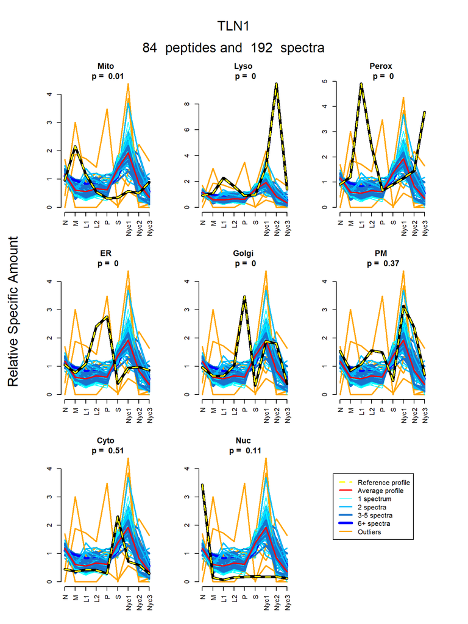

```r
#windows(width=7.5, height=10)  # open a window 7.5 by 10 inches
protPepPlotfun(protName="TLN1", protProfile=protRSA[,5:15],
               pepProfile=pepRSA, numRefCols=4,
               numDataCols=9, n.compartments=8,
               refLocationProfiles=refLocationProfilesRSA,
               assignPropsMat=protCPAfromRSA,
               yAxisLabel="Relative Specific Amount")
```

Note that the outlier peptides do not contribute to the CPA analysis of the proteins, but these may be of interest. For instance, they may represent protein isoforms with distinct distributions. Thus, there may be specific biological questions that require CPA estimates for all proteins and peptides without outlier removal. This can be accomplished using the following command:

```r
protPepCPAfromRSA <- fitCPA(profile=protPepRSA[,4 + 1:9],
                               refLocationProfiles=refLocationProfilesRSA,
                               numDataCols=9)
head(round(protPepCPAfromRSA, digits=4))
```

```
#>                        Cyto     ER  Golgi   Lyso   Mito    Nuc  Perox     PM
#> ACP2                 0.0333 0.0841 0.0000 0.8399 0.0000 0.0221 0.0206 0.0000
#> ACP2::CPLQDFLR       0.0000 0.0000 0.0000 1.0000 0.0000 0.0000 0.0000 0.0000
#> ACP2::DPYQEEK        0.0034 0.0000 0.0000 0.9966 0.0000 0.0000 0.0000 0.0000
#> ACP2::EGMLQHWELGQALR 0.2064 0.1632 0.0000 0.4400 0.0835 0.0131 0.0032 0.0905
#> ACP2::LTEPVIPK       0.0000 0.0000 0.0000 1.0000 0.0000 0.0000 0.0000 0.0000
#> ACP2::MQAQPPGYHHVADR 0.2554 0.0006 0.0655 0.5389 0.0472 0.0924 0.0000 0.0000
```

We next assemble the final CPA values for the protein/peptide data along with ancillary information, ready for export.

```r
protPepCPAfromRSAout <- data.frame(protPepRSA[,1:4], protPepCPAfromRSA, protPepRSA[,14:15])
protPepCPAfromRSAout$prot <- paste("`", protPepCPAfromRSAout$prot, sep="")
protPepCPAfromRSAout$peptide <- paste("`", protPepCPAfromRSAout$peptide, sep="")
```

One could, for example, create a local directory `C:\\temp\\myProteinOutput` and write the data there. Here, for for illustration, we shall instead create a temporary directory as follows:

```r
currentDir <- tempdir()
setwd(currentDir)
currentDir
```

```
#> [1] "C:\\Users\\mooredf\\AppData\\Local\\Temp\\RtmpoLQi9c"
```

We then change to that directory and write the data there:

```r
setwd(currentDir)
write.csv(protPepCPAfromRSAout,
          file="protPepCPAfromRSAout.csv", row.names=FALSE, na=".")
```

If one wanted to output plots of all of the protein and peptide profiles into a single pdf file, one could first use `setwd` to point to the desired output directory, and then set up a loop as follows.

```
setwd("C:\\temp\\myProteinOutput")
pdf(file="allProtPepPlotsRSA.pdf", width=7, height=10)
n.prots <- nrow(protRSA)
for (i in 1:n.prots) {
   protPepPlotfun(protName=protRSA$prot[i],
       protProfile=protRSA[,5:15],
       Nspectra=TRUE, pepProfile=pepRSA, numRefCols=4,
       numDataCols=9, n.compartments=8,
       refLocationProfiles=refLocationProfilesRSA,
       assignPropsMat=protCPAfromRSA,
       yAxisLabel="Relative Specific Amount")
}
dev.off()
```

# 7 Tutorial 7: Finding proteins with similar profiles

We may find the proteins with profiles nearest to a given protein using the function “nearestProts”. Distance is computed as the Euclidean distance between profiles. To use the function, we first use the R function `dist` to create a distance matrix for the proteins in a list of mean profiles. This will typically be done using a full data set, such as `protProfileNSA_AT5tmtMS2`, which can be downloaded as described in Tutorial 1. In this example we use the small embedded data set `protNSA_test`. For clarity of presentation, we rename the embedded data sets to remove experiment-specific labels.

```r
library(protlocassign)
data(protNSA_test)
data(totProtAT5)

protNSA <- protNSA_test
totProt <- totProtAT5
distUseNSA <- dist(protNSA[,1:9], method="euclidean")
```

Then select the protein names:

```r
protsUse <- rownames(protNSA)
```

Finally, provide a protein name. Here, for the protein “CTSD”, we find the 10 nearest proteins. As expected, the three proteins closest to the lysosomal protein CTSD (HEXA, ACP2, GLB1) also reside within the lysosome.

```r
nearestProts(protName="CTSD", n.nearest=10,  distProts=distUseNSA,
             protNames=protsUse,
             profile=protNSA)
```

```
#>    protName euclidean distance
#> 1      CTSD         0.00000000
#> 2      HEXA         0.06363581
#> 3      ACP2         0.08583512
#> 4      GLB1         0.09032105
#> 5   B4GALT1         0.30025871
#> 6      NT5E         0.30149795
#> 7    ATP1A1         0.34253325
#> 8     ENPP1         0.34960893
#> 9     ITGB1         0.39053728
#> 10  ST6GAL1         0.39961790
```

Instead of using NSF profiles, we may transform them to RSA profiles:

```r
protProfileLevelsRSA <- RSAfromNSA(NSA=protNSA[,1:9],
                                 NstartMaterialFractions=6, totProt=totProt)
distUseRSA <- dist(protProfileLevelsRSA, method="euclidean")
nearestProts(protName="CTSD", n.nearest=10,  distProts=distUseRSA,
             protNames=protsUse,
             profile=protProfileLevelsRSA)
```

```
#>    protName euclidean distance
#> 1      CTSD           0.000000
#> 2      HEXA           2.829727
#> 3      ACP2           4.411651
#> 4      GLB1           4.575129
#> 5   B4GALT1           8.098975
#> 6      NT5E           9.512534
#> 7    ATP1A1          10.232283
#> 8      CD38          10.380878
#> 9     ENPP1          10.497387
#> 10  ST6GAL1          10.823945
```

Note that if one wants to generate a table listing the distances between all protein pairs, one needs to convert `distUse` or `distUseRSA` to a matrix. We show the first five rows and columns here:

```r
distUseNSAmatrix <- as.matrix(distUseNSA)
distUseNSAmatrix[1:5,1:5]
```

```
#>              ACP2 AIF1    ATP1A1   B4GALT1      CANX
#> ACP2    0.0000000   NA 0.2641216 0.2489000 0.4332281
#> AIF1           NA    0        NA        NA        NA
#> ATP1A1  0.2641216   NA 0.0000000 0.1796886 0.2408772
#> B4GALT1 0.2489000   NA 0.1796886 0.0000000 0.2997202
#> CANX    0.4332281   NA 0.2408772 0.2997202 0.0000000
```

This matrix can be written to a local directory using standard procedures.

# 8 References

Chen, Yunmei and Ye, Xiaojing. Projection Onto A Simplex. arXiv 2011 https://arxiv.org/abs/1101.6081

Gatto L, Breckels LM, Wieczorek S, Burger T, Lilley KS. Mass-spectrometry-based spatial proteomics data analysis using pRoloc and pRolocdata. Bioinformatics. 2014 May 1;30(9):1322-4. doi:10.1093/bioinformatics/btu013. Epub 2014 Jan 11. PubMed PMID: 24413670; PubMed Central PMCID: PMC3998135.

Jadot, M.; Boonen, M.; Thirion, J.; Wang, N.; Xing, J.; Zhao, C.; Tannous, A.; Qian, M.; Zheng, H.; Everett, J. K., Accounting for protein subcellular localization: A compartmental map of the rat liver proteome. Molecular & Cellular Proteomics 2017, 16, (2), 194-212.

Moore DF, Sleat D, Lobel P. A method to estimate the distribution of proteins across multiple compartments using data from quantitative proteomics subcellular fractionation experiments. Journal of Proteome Research, 2022, 21, 6, 1371-1381 https://doi.org/10.1021/acs.jproteome.1c00781

Tannous, A.; Boonen, M.; Zheng, H.; Zhao, C.; Germain, C. J.; Moore, D. F.; Sleat, D. E.; Jadot, M.; Lobel, P., Comparative Analysis of Quantitative Mass Spectrometric Methods for Subcellular Proteomics. J Proteome Res 2020, 19, (4), 1718-1730.

Tran, A.N., Dussaq, A.M., Kennell, T. et al. HPAanalyze: an R package that facilitates the retrieval and analysis of the Human Protein Atlas data. BMC Bioinformatics 20, 463 (2019) doi:10.1186/s12859-019-3059-z

# 9 Reproducibility

Following is the output of the utility `sessionInfo`. This output contains details of the packages and version numbers used to generate these tutorials.

[session information not shown]